# PREDI Project: Non Modified Proteome (Batch 1 and 2)

## QC and statistical analysis summary

### created by Santosh D. Bhosale, SDU

#### August 15, 2022

- Overview
- Data processing
- CV distributions
- Summary

## Overview

- Biopsies from uninflamed colon, visit 1 is baseline/before treatment and visit 2 is 14-16 weeks after treatment (N = 14 vs 14) were labeled with 2 X TMT 16 plex channels.
- Two pools (channel 126 and 134N) were used per plex.
- TMT labeled samples were subjected to TiO2 enrichment to do purification of phosphopeptides and formerely N-linked sialyated glycopeptides.
- HpH fractionation was used to collect 12 fractions from both non modified and modified proteome.
- The data was analysed with FragPipe (v18) and abunance_protein_MD.tsv (median centering normalisation) file was further considered for analysis.
  - Across the samples 5038 proteins were identified.
  - The percentage of misssingness was 10%.
- This report summarises non modified proteome findings.
  - QC checks: Batch effect correction (at two levels; no filtering and filtering to retain 100 % valid values) and clusterng of samples by condition.
  - Statistical analysis

## Load the necessary R libraries

```r
install.packages("tidyverse")
```

```r
# library imports
library(tidyverse)
library(scales)
library(limma)
library(edgeR)
library(psych)
library(dendextend)
```

```
Error in library(psych): there is no package called 'psych'
Traceback:

1. library(psych)
```

## Define common functions for notebook use

```r
# ================== TMM normalization from DGEList object =====================
apply_tmm_factors <- function(y, color = NULL, plot = TRUE) {
    # computes the tmm normalized data from the DGEList object
        # y - DGEList object
        # returns a dataframe with normalized intensities

    # compute and print "Sample loading" normalization factors
    lib_facs <- mean(y$samples$lib.size) / y$samples$lib.size
    cat("\nLibrary size factors:\n",
        sprintf("%-5s -> %f\n", colnames(y$counts), lib_facs))

    # compute and print TMM normalization factors
    tmm_facs <- 1/y$samples$norm.factors
    cat("\nTrimmed mean of M-values (TMM) factors:\n",
        sprintf("%-5s -> %f\n", colnames(y$counts), tmm_facs))

    # compute and print the final correction factors
    norm_facs <- lib_facs * tmm_facs
    cat("\nCombined (lib size and TMM) normalization factors:\n",
        sprintf("%-5s -> %f\n", colnames(y$counts), norm_facs))

    # compute the normalized data as a new data frame
    tmt_tmm <- as.data.frame(sweep(y$counts, 2, norm_facs, FUN = "*"))
    colnames(tmt_tmm) <- str_c(colnames(y$counts), "_tmm")

    # visualize results and return data frame
    if(plot == TRUE) {
        boxplot(log10(tmt_tmm), col = color, notch = TRUE, main = "TMM Normalized data")
    }
    tmt_tmm
}

# ============== CV function ===================================================
CV <- function(df) {
    # Computes CVs of data frame rows
        # df - data frame,
        # returns vector of CVs (%)
    ave <- rowMeans(df)    # compute averages
    sd <- apply(df, 1, sd) # compute standard deviations
    cv <- 100 * sd / ave   # compute CVs in percent (last thing gets returned)
}

# =========== Boxplot with median label ========================================
labeled_boxplot <- function(df, ylim, title) {
    # Makes a box plot with the median value labeled
        # df - data frame with data to compute CVs of
        # ylim - upper limit for y-axis
        # title - plot title
    cv = CV(df)
    boxplot(cv, ylim = c(0, ylim), notch = TRUE, main = title)
    text(x = 0.65, y = boxplot.stats(cv)$stats[3],
         labels = round(boxplot.stats(cv)$stats[3], 1))
}

set_plot_dimensions <- function(width_choice, height_choice) {
    options(repr.plot.width=width_choice, repr.plot.height=height_choice)
}
```

# QC checks

## Data processing: No filtering to remove NAs

- No filtering is performed on the data
- log2-transformed data was used to perform limma:removeBatchEffect()

```r
protein_data1 = read.delim(file = 'abundance_protein_MD_for_BC.tsv', header=TRUE, row.names = 1)
keep_old_data <- protein_data1
View(protein_data1)
```

A data.frame: 5038 × 30

|  | Normal_1001.1 <dbl> | Normal_1002.1 <dbl> | Normal_1003.1 <dbl> | Normal_1004.1 <dbl> | Normal_1213.1 <dbl> | Normal_1214.1 <dbl> | Normal_1215.1 <dbl> | Normal_1001.2 <dbl> | Normal_1002.2 <dbl> | Normal_1003.2 <dbl> | ⋯ | Normal_1563.1 <dbl> | Normal_1580.1 <dbl> | Normal_1401.2 <dbl> | Normal_1402.2 <dbl> | Normal_1503.2 <dbl> | Normal_1518.2 <dbl> | Normal_1539.2 <dbl> | Normal_1563.2 <dbl> | Normal_1580.2 <dbl> | pool2.2 <dbl> |
| --- | --- | --- | --- | --- | --- | --- | --- | --- | --- | --- | --- | --- | --- | --- | --- | --- | --- | --- | --- | --- | --- |
| A0A024RBG1 | 19.10729 | 18.93056 | 18.75975 | 19.04012 | 18.95292 | 19.02369 | 19.13319 | 18.98508 | 19.34557 | 19.06943 | ⋯ | 18.65230 | 19.28762 | 19.41907 | 19.41023 | 19.50324 | 19.52242 | 19.41820 | 19.30920 | 19.49883 | 18.61972 |
| A0A075B6H7 | 20.25408 | 20.55836 | 19.67400 | 20.52577 | 20.28805 | 19.27782 | 19.86908 | 19.83209 | 19.74524 | 19.70637 | ⋯ | 19.67955 | 19.87374 | 19.61395 | 19.73145 | 19.54272 | 19.71117 | 19.70122 | 20.62366 | 19.96669 | 20.33888 |
| A0A075B6H9 | 18.81861 | 18.38606 | 18.27379 | 18.44279 | 19.43132 | 18.39013 | 18.45889 | 18.28925 | 18.07239 | 18.79552 | ⋯ | 18.79314 | 18.71214 | 18.98489 | 18.98973 | 19.00867 | 19.02255 | 18.38576 | 19.71191 | 19.21278 | 19.41812 |
| A0A075B6I0 | 21.04551 | 20.85883 | 21.21782 | 21.13352 | 21.52227 | 20.41224 | 18.87665 | 20.76149 | 20.60502 | 21.23022 | ⋯ | 20.53920 | 21.20300 | 20.01407 | 20.01447 | 18.67214 | 20.11035 | 20.88403 | 20.95726 | 20.98188 | 20.55474 |
| A0A075B6I1 | 18.30156 | 18.34703 | 17.24402 | 18.08645 | 18.29290 | 18.04392 | 17.95454 | 18.30758 | 17.91273 | 17.93311 | ⋯ | 18.58527 | 17.64619 | 17.38030 | 18.12753 | 17.06937 | 17.63370 | 17.49546 | 18.27339 | 17.58687 | 19.04983 |
| A0A075B6I9 | 18.89451 | 17.80736 | 18.55068 | 19.66588 | 18.60871 | 18.18874 | 18.75686 | 18.40430 | 18.07071 | 18.54704 | ⋯ | 19.21486 | 18.63336 | 18.37673 | 19.03608 | 18.89370 | 19.05337 | 18.67482 | 19.10487 | 18.61103 | 18.45454 |
| A0A075B6K2 | 16.34202 | 16.93921 | 16.09095 | 16.30237 | 17.45433 | 15.55511 | 16.03932 | 16.08215 | 16.00125 | 16.34512 | ⋯ | 16.85056 | 16.39904 | 14.97208 | 15.88439 | 15.91926 | 15.97875 | 16.87103 | 16.95595 | 16.08826 | 15.81093 |
| A0A075B6Q5 | 20.21058 | 21.89750 | 20.04218 | 21.28238 | 21.90751 | 20.22634 | 20.69074 | 19.65869 | 20.46133 | 19.94103 | ⋯ | 21.69462 | 20.94843 | 21.31234 | 20.72980 | 20.87101 | 20.98573 | 21.04444 | 21.88829 | 21.03830 | 21.01125 |
| A0A075B6R2 | 18.99457 | 20.21483 | 18.61230 | 18.53040 | 19.96298 | 18.44566 | 18.53730 | 18.19216 | 18.69451 | 18.43047 | ⋯ | NA | NA | NA | NA | NA | NA | NA | NA | NA | NA |
| A0A075B6R9 | 21.67625 | 21.13914 | 21.64080 | 21.66028 | 21.93752 | 21.36905 | 21.78372 | 21.67483 | 21.03784 | 21.59284 | ⋯ | 21.40566 | 21.56276 | 20.79035 | 21.30402 | 21.35785 | 21.23595 | 21.03499 | 21.38083 | 21.58701 | 21.43731 |
| A0A075B6S2 | 22.16558 | 22.20111 | 21.94692 | 22.37609 | 22.66327 | 20.91219 | 21.82715 | 21.90494 | 21.86472 | 21.98125 | ⋯ | 22.13066 | 22.69271 | 22.10978 | 22.73870 | 22.02989 | 22.16625 | 22.44689 | 23.05138 | 22.76047 | 21.69301 |
| A0A075B6S6 | 21.27713 | 21.02433 | 20.30117 | 21.07887 | 21.22831 | 20.47653 | 20.50732 | 20.80696 | 20.12834 | 20.52901 | ⋯ | 21.17426 | 21.21245 | 20.19803 | 21.34619 | 20.70314 | 20.77016 | 21.48479 | 21.22119 | 21.02828 | 20.78416 |
| A0A087WSY4 | 17.95358 | 18.69302 | 17.82066 | 18.42072 | 18.73492 | 18.12484 | 18.20520 | 17.87935 | 18.03847 | 19.72441 | ⋯ | 18.17613 | 17.33193 | 17.51736 | 17.20742 | 18.38590 | 17.30763 | 17.90369 | 17.84443 | 17.07238 | 19.00147 |
| A0A0A0MRZ8 | 24.64817 | 25.12419 | 23.95696 | 24.63599 | 24.90399 | 23.61108 | 24.02051 | 24.30546 | 24.18170 | 24.12985 | ⋯ | 23.18494 | 23.98315 | 23.94693 | 23.94868 | 23.87945 | 23.78396 | 23.84695 | 24.53787 | 24.11897 | 24.78575 |
| A0A0A0MT89 | 15.05551 | 15.36934 | 14.90595 | 14.40346 | 15.21175 | 14.25674 | 14.72910 | 14.70544 | 14.42308 | 14.13313 | ⋯ | NA | NA | NA | NA | NA | NA | NA | NA | NA | NA |
| A0A0B4J1U7 | 20.87437 | 20.35941 | 19.72130 | 20.41952 | 20.89354 | 19.60651 | 19.56366 | 20.02867 | 19.56058 | 19.92395 | ⋯ | 21.41161 | 21.07411 | 20.95744 | 21.46303 | 20.98902 | 21.19576 | 20.94446 | 21.39239 | 21.02991 | 21.27249 |
| A0A0B4J2D5 | 23.01174 | 22.98249 | 23.30181 | 22.87594 | 21.98828 | 22.54340 | 23.05475 | 23.37922 | 23.33253 | 23.03325 | ⋯ | 21.89863 | 22.82181 | 23.07762 | 22.89125 | 23.26045 | 22.89800 | 22.79875 | 22.69709 | 22.80626 | 22.23559 |
| A0A0B4J2D9 | 22.10985 | 23.24069 | 21.58920 | 21.86500 | 22.96165 | 21.27829 | 21.63739 | 21.65621 | 21.26392 | 21.76142 | ⋯ | 22.23809 | 21.93908 | 21.09045 | 21.36579 | 21.52493 | 21.95444 | 21.72217 | 22.84822 | 21.82455 | 22.60748 |
| A0A0C4DH25 | 24.46469 | 24.78983 | 24.13961 | 24.63727 | 25.44708 | 23.84532 | 24.34147 | 24.02391 | 24.31027 | 24.30480 | ⋯ | 24.05612 | 24.32527 | 23.85237 | 24.08703 | 23.95233 | 23.95595 | 24.07079 | 24.83572 | 24.28190 | 24.89868 |
| A0A0C4DH29 | 22.39125 | 23.58732 | 22.24646 | 22.51377 | 24.33322 | 21.75016 | 22.78508 | 21.76171 | 22.02487 | 21.96067 | ⋯ | 23.51752 | 23.00627 | 22.00493 | 22.64465 | 22.31321 | 23.03550 | 23.39118 | 23.64518 | 22.96108 | 22.24535 |
| A0A0C4DH34 | 18.91602 | 19.13513 | 18.90091 | 19.31975 | 19.66867 | 19.08920 | 19.21469 | 19.09557 | 19.05376 | 19.11793 | ⋯ | 20.10834 | 19.86602 | 19.63104 | 19.53898 | 19.96946 | 19.81332 | 19.80906 | 20.46610 | 20.00636 | 19.60655 |
| A0A0C4DH38 | 18.28505 | 18.97375 | 17.88037 | 18.07163 | 19.06639 | 18.36493 | 18.12558 | 17.89720 | 18.22592 | 18.01638 | ⋯ | 19.52507 | 18.67380 | 18.10519 | 18.02821 | 17.83718 | 18.26057 | 18.59311 | 19.61079 | 18.58372 | 17.33610 |
| A0A0C4DH39 | 17.69888 | 18.52168 | 17.63829 | 17.64159 | 19.75691 | 17.81002 | 18.04141 | 17.35366 | 17.63927 | 17.34491 | ⋯ | NA | NA | NA | NA | NA | NA | NA | NA | NA | NA |
| A0A0C4DH41 | 21.17535 | 21.26923 | 21.22757 | 21.09698 | 21.45779 | 21.21636 | 21.42627 | 20.86131 | 21.01027 | 21.22706 | ⋯ | 22.05381 | 21.49426 | 21.35026 | 21.35154 | 21.34195 | 21.24298 | 21.31962 | 22.26964 | 21.55581 | 21.08101 |
| A0A0J9YXX1 | 21.50795 | 19.12232 | 20.42988 | 20.64849 | 22.23296 | 20.95483 | 20.45880 | 20.84803 | 19.42291 | 20.36829 | ⋯ | 22.60799 | 21.28312 | 21.71046 | 20.38577 | 20.07833 | 19.36744 | 19.67968 | 22.90346 | 21.30527 | 21.04921 |
| A0AV96 | 20.52132 | 20.50786 | 20.79482 | 20.82343 | 20.71197 | 20.96718 | 20.84824 | 20.53246 | 20.65962 | 20.69012 | ⋯ | 21.09780 | 20.94723 | 20.48057 | 21.04312 | 21.14524 | 20.91864 | 20.84504 | 20.95244 | 20.97389 | 20.53022 |
| A0AVT1 | 20.33420 | 20.17463 | 20.57539 | 20.34601 | 20.50655 | 20.33214 | 20.40575 | 20.14088 | 20.37959 | 20.29638 | ⋯ | 19.93716 | 19.90999 | 20.07429 | 20.08104 | 20.07056 | 19.99006 | 20.06354 | 20.17503 | 20.08017 | 20.00473 |
| A0FGR8 | 19.55595 | 19.71647 | 19.75821 | 19.84742 | 19.95036 | 19.95303 | 19.80048 | 19.45258 | 19.78825 | 19.72489 | ⋯ | 20.74756 | 20.45248 | 20.31989 | 20.63157 | 20.38777 | 20.45074 | 20.67627 | 20.67548 | 20.65075 | 20.08843 |
| A0M8Q6 | 16.87204 | 17.53905 | 19.00941 | 19.55167 | 20.59653 | 17.71720 | 19.88746 | 17.41868 | 16.82197 | 19.10571 | ⋯ | 17.74285 | 19.59199 | 19.49741 | 18.16945 | 19.53035 | 19.03052 | 20.77068 | 18.69059 | 19.27914 | 17.70422 |
| A0MZ66 | 19.82752 | 19.97038 | 19.68577 | 19.75962 | 19.55647 | 19.99367 | 19.81468 | 19.73325 | 20.05973 | 19.90660 | ⋯ | 20.23671 | 20.07992 | 20.01620 | 20.02900 | 20.01935 | 20.06512 | 19.85520 | 19.82755 | 19.81562 | 19.99385 |
| ⋮ | ⋮ | ⋮ | ⋮ | ⋮ | ⋮ | ⋮ | ⋮ | ⋮ | ⋮ | ⋮ | ⋱ | ⋮ | ⋮ | ⋮ | ⋮ | ⋮ | ⋮ | ⋮ | ⋮ | ⋮ | ⋮ |
| Q9Y6D5 | 21.20773 | 20.97099 | 21.42630 | 21.42907 | 21.65775 | 21.46460 | 21.42522 | 21.30132 | 21.55448 | 21.34592 | ⋯ | 21.17767 | 21.22620 | 21.20104 | 21.50290 | 21.46103 | 21.39233 | 21.30543 | 21.54639 | 21.87900 | 21.41501 |
| Q9Y6D6 | 18.71748 | 18.72065 | 18.85499 | 18.76200 | 18.86336 | 19.21693 | 19.00175 | 18.87944 | 18.80659 | 18.97164 | ⋯ | 18.73055 | 18.78563 | 19.00564 | 19.26906 | 18.86166 | 19.03087 | 18.67813 | 20.16081 | 19.67414 | 19.72285 |
| Q9Y6D9 | NA | NA | NA | NA | NA | NA | NA | NA | NA | NA | ⋯ | 15.72143 | 15.00236 | 14.86004 | 14.92818 | 14.78145 | 14.90063 | 15.36186 | 14.88730 | 14.84584 | 14.96592 |
| Q9Y6E0 | 20.74484 | 20.90202 | 21.00903 | 20.91640 | 20.69455 | 21.05650 | 21.12342 | 20.91836 | 21.02610 | 21.07848 | ⋯ | 21.17565 | 21.01516 | 20.89344 | 20.86318 | 21.10690 | 21.12099 | 20.78113 | 20.86664 | 21.05363 | 20.71945 |
| Q9Y6E2 | 20.71963 | 20.77818 | 20.74746 | 20.76604 | 20.90492 | 21.03184 | 20.85875 | 20.80378 | 20.63050 | 20.62103 | ⋯ | 20.56054 | 20.69742 | 20.66422 | 20.93872 | 20.65587 | 20.69224 | 20.55511 | 20.73424 | 20.92282 | 20.81849 |
| Q9Y6F6 | 17.14659 | 17.48421 | 17.00705 | 17.04270 | 17.14736 | 17.24780 | 16.92473 | 17.35100 | 17.35393 | 17.40080 | ⋯ | 17.30976 | 17.15447 | 16.91396 | 16.73703 | 16.87259 | 16.99934 | 17.13186 | 17.28062 | 16.51341 | 17.79593 |
| Q9Y6G3 | 17.55817 | 17.51817 | 16.93807 | 17.02605 | 16.83055 | 17.18716 | 17.25341 | 17.44318 | 16.90074 | 16.98814 | ⋯ | 16.45338 | 16.29347 | 16.42972 | 16.12240 | 16.17686 | 16.73409 | 16.23742 | 16.05983 | 16.17576 | 16.95178 |
| Q9Y6G5 | 17.04938 | 16.99655 | 17.38609 | 17.24092 | 17.05548 | 17.52320 | 17.44082 | 17.50554 | 17.28796 | 17.51705 | ⋯ | NA | NA | NA | NA | NA | NA | NA | NA | NA | NA |
| Q9Y6G9 | 21.36916 | 21.25557 | 21.65708 | 21.35691 | 21.25349 | 21.08338 | 21.31366 | 21.44651 | 21.31281 | 21.33384 | ⋯ | 20.87762 | 20.63762 | 20.79972 | 20.70109 | 20.54846 | 20.51935 | 20.97035 | 20.52456 | 20.46178 | 20.91895 |
| Q9Y6H1 | 18.86866 | 18.99644 | 18.92038 | 18.81393 | 18.83315 | 19.15126 | 19.18730 | 19.02193 | 18.89898 | 18.94968 | ⋯ | 19.46499 | 19.25478 | 18.98009 | 18.88995 | 19.02274 | 19.14308 | 19.17358 | 18.64349 | 18.65818 | 18.91238 |
| Q9Y6I3 | 19.21719 | 19.44748 | 19.03692 | 19.15877 | 18.77283 | 19.35303 | 19.22783 | 19.36745 | 19.23503 | 19.38492 | ⋯ | 19.28004 | 19.34875 | 19.26540 | 19.10710 | 19.31546 | 19.34015 | 19.46423 | 19.18774 | 19.27582 | 19.49525 |
| Q9Y6I4 | 15.80173 | 16.25925 | 15.59568 | 16.24511 | 16.54417 | 17.26850 | 17.02154 | 15.75262 | 15.65370 | 15.81948 | ⋯ | NA | NA | NA | NA | NA | NA | NA | NA | NA | NA |
| Q9Y6I9 | 17.64710 | 17.73991 | 17.54070 | 17.61267 | 18.14555 | 18.12163 | 18.03710 | 17.58271 | 17.45253 | 17.50233 | ⋯ | 16.64650 | 16.42047 | 16.77180 | 16.42307 | 16.53413 | 16.54260 | 16.87644 | 16.66180 | 16.31420 | 17.66647 |
| Q9Y6K0 | NA | NA | NA | NA | NA | NA | NA | NA | NA | NA | ⋯ | 13.97289 | 14.08471 | 14.24131 | 14.65805 | 14.38106 | 14.39408 | 14.08793 | 14.97041 | 14.77524 | 14.81925 |
| Q9Y6K5 | 17.08089 | 16.51364 | 17.37825 | 17.07144 | 17.34273 | 16.03025 | 16.78090 | 16.60536 | 17.00463 | 16.78472 | ⋯ | 17.56552 | 17.04409 | 17.13233 | 17.71396 | 17.35498 | 17.18230 | 17.32901 | 17.27435 | 17.32992 | 17.39344 |
| Q9Y6K9 | 20.05360 | 20.06784 | 19.60249 | 19.98702 | 20.02805 | 20.07945 | 19.97097 | 19.82796 | 19.67600 | 19.68429 | ⋯ | 20.08513 | 19.73932 | 19.96802 | 19.45794 | 19.48075 | 19.72667 | 19.93205 | 19.61186 | 19.61378 | 20.22526 |
| Q9Y6M1 | 19.31669 | 19.47430 | 19.61641 | 19.55884 | 19.46177 | 19.62078 | 19.87190 | 19.63876 | 19.83261 | 19.76411 | ⋯ | 19.03286 | 19.27103 | 19.18964 | 19.41970 | 19.53655 | 19.32438 | 19.33256 | 19.54784 | 19.45404 | 19.46575 |
| Q9Y6M7 | NA | NA | NA | NA | NA | NA | NA | NA | NA | NA | ⋯ | 16.75382 | 16.18759 | 16.34914 | 16.19551 | 16.32016 | 16.21741 | 16.09454 | 16.33111 | 16.38012 | 17.13078 |
| Q9Y6M9 | 19.76405 | 19.64423 | 20.21207 | 19.79748 | 19.28834 | 19.83518 | 20.00241 | 20.12370 | 20.28761 | 20.21508 | ⋯ | 19.62633 | 19.78040 | 19.61120 | 19.51773 | 19.63222 | 19.95785 | 19.46109 | 19.48834 | 19.69822 | 19.51811 |
| Q9Y6N5 | 22.28766 | 22.46486 | 23.02399 | 22.75338 | 22.88528 | 22.55794 | 22.50176 | 22.30686 | 22.76248 | 22.97723 | ⋯ | 22.42776 | 22.26780 | 22.19500 | 22.29231 | 22.81774 | 22.60808 | 21.98143 | 22.71603 | 22.71620 | 22.45126 |
| Q9Y6N9 | 20.60440 | 20.57426 | 21.00009 | 20.66885 | 20.80293 | 20.99714 | 20.86505 | 20.69760 | 21.14553 | 21.08008 | ⋯ | 20.48720 | 20.25707 | 19.50800 | 20.30347 | 20.30560 | 20.21244 | 19.72764 | 20.18777 | 20.47900 | 20.69388 |
| Q9Y6Q5 | 19.91859 | 19.54692 | 20.23303 | 19.64463 | 20.54585 | 19.91449 | 19.80626 | 19.59582 | 20.21027 | 19.99992 | ⋯ | 19.85863 | 19.79454 | 19.68047 | 20.04778 | 20.25257 | 19.94763 | 19.79851 | 20.17126 | 20.34330 | 19.76706 |
| Q9Y6R1 | 19.55153 | 19.33651 | 20.34411 | 20.22528 | 19.64817 | 20.24813 | 20.00165 | 19.71159 | 20.44379 | 20.23980 | ⋯ | 20.16059 | 19.84937 | 19.38738 | 20.07981 | 20.13496 | 19.95500 | 19.42176 | 20.05306 | 20.35048 | 19.83455 |
| Q9Y6R7 | 25.40871 | 25.30277 | 25.46997 | 25.29925 | 24.53102 | 25.70146 | 25.55998 | 25.73942 | 25.66135 | 25.84020 | ⋯ | 25.46626 | 25.24035 | 25.23916 | 25.44383 | 25.72621 | 25.98843 | 25.25364 | 25.89658 | 25.97578 | 25.53225 |
| Q9Y6U3 | 18.99679 | 19.05387 | 19.62409 | 19.65874 | 18.91958 | 19.97073 | 19.75049 | 19.43657 | 19.71599 | 19.80116 | ⋯ | 19.69884 | 19.58449 | 19.37005 | 19.83270 | 20.07554 | 19.92841 | 19.38309 | 20.04107 | 19.86220 | 19.27445 |
| Q9Y6W3 | 17.52463 | 17.47187 | 17.59165 | 17.48256 | 17.50615 | 17.69035 | 17.54331 | 17.35312 | 17.50615 | 17.53756 | ⋯ | 17.61428 | 17.38152 | 17.33741 | 17.56930 | 17.41284 | 17.67423 | 17.50053 | 17.55431 | 17.56284 | 17.91831 |
| Q9Y6W5 | 21.21071 | 21.11045 | 20.85918 | 21.13222 | 20.79297 | 20.90674 | 21.02243 | 21.23841 | 20.92517 | 21.00970 | ⋯ | 20.88972 | 20.99460 | 21.17575 | 20.91181 | 20.81279 | 21.12921 | 21.05940 | 20.85664 | 20.82513 | 21.11945 |
| Q9Y6X5 | 13.25572 | 13.27381 | 13.91555 | 12.95925 | 12.60425 | 13.07806 | 12.97611 | 13.47764 | 13.68783 | 13.71896 | ⋯ | 13.47177 | 13.48412 | 13.68349 | 13.46210 | 13.50164 | 13.19322 | 12.77757 | 13.86895 | 13.60417 | 13.72131 |
| Q9Y6X9 | 19.43768 | 19.35532 | 19.32135 | 19.49328 | 19.41723 | 20.07054 | 19.54930 | 19.30696 | 19.20378 | 19.35507 | ⋯ | NA | NA | NA | NA | NA | NA | NA | NA | NA | NA |
| Q9Y6Y8 | 19.80723 | 19.82670 | 19.96133 | 19.90231 | 20.16998 | 19.87359 | 20.00960 | 19.71275 | 20.06614 | 19.92633 | ⋯ | 19.14360 | 19.24322 | 19.71036 | 19.90112 | 20.02608 | 19.27973 | 19.38104 | 19.87393 | 19.78657 | 19.81279 |

```r
# Convert NA value to zero
protein_data1[is.na(protein_data1)] <- 0
View(protein_data1)
pheno <- read.delim(file = 'pheno1.tsv')
View(pheno)
```

A data.frame: 5038 × 30

|  | Normal_1001.1 <dbl> | Normal_1002.1 <dbl> | Normal_1003.1 <dbl> | Normal_1004.1 <dbl> | Normal_1213.1 <dbl> | Normal_1214.1 <dbl> | Normal_1215.1 <dbl> | Normal_1001.2 <dbl> | Normal_1002.2 <dbl> | Normal_1003.2 <dbl> | ⋯ | Normal_1563.1 <dbl> | Normal_1580.1 <dbl> | Normal_1401.2 <dbl> | Normal_1402.2 <dbl> | Normal_1503.2 <dbl> | Normal_1518.2 <dbl> | Normal_1539.2 <dbl> | Normal_1563.2 <dbl> | Normal_1580.2 <dbl> | pool2.2 <dbl> |
| --- | --- | --- | --- | --- | --- | --- | --- | --- | --- | --- | --- | --- | --- | --- | --- | --- | --- | --- | --- | --- | --- |
| A0A024RBG1 | 19.10729 | 18.93056 | 18.75975 | 19.04012 | 18.95292 | 19.02369 | 19.13319 | 18.98508 | 19.34557 | 19.06943 | ⋯ | 18.65230 | 19.28762 | 19.41907 | 19.41023 | 19.50324 | 19.52242 | 19.41820 | 19.30920 | 19.49883 | 18.61972 |
| A0A075B6H7 | 20.25408 | 20.55836 | 19.67400 | 20.52577 | 20.28805 | 19.27782 | 19.86908 | 19.83209 | 19.74524 | 19.70637 | ⋯ | 19.67955 | 19.87374 | 19.61395 | 19.73145 | 19.54272 | 19.71117 | 19.70122 | 20.62366 | 19.96669 | 20.33888 |
| A0A075B6H9 | 18.81861 | 18.38606 | 18.27379 | 18.44279 | 19.43132 | 18.39013 | 18.45889 | 18.28925 | 18.07239 | 18.79552 | ⋯ | 18.79314 | 18.71214 | 18.98489 | 18.98973 | 19.00867 | 19.02255 | 18.38576 | 19.71191 | 19.21278 | 19.41812 |
| A0A075B6I0 | 21.04551 | 20.85883 | 21.21782 | 21.13352 | 21.52227 | 20.41224 | 18.87665 | 20.76149 | 20.60502 | 21.23022 | ⋯ | 20.53920 | 21.20300 | 20.01407 | 20.01447 | 18.67214 | 20.11035 | 20.88403 | 20.95726 | 20.98188 | 20.55474 |
| A0A075B6I1 | 18.30156 | 18.34703 | 17.24402 | 18.08645 | 18.29290 | 18.04392 | 17.95454 | 18.30758 | 17.91273 | 17.93311 | ⋯ | 18.58527 | 17.64619 | 17.38030 | 18.12753 | 17.06937 | 17.63370 | 17.49546 | 18.27339 | 17.58687 | 19.04983 |
| A0A075B6I9 | 18.89451 | 17.80736 | 18.55068 | 19.66588 | 18.60871 | 18.18874 | 18.75686 | 18.40430 | 18.07071 | 18.54704 | ⋯ | 19.21486 | 18.63336 | 18.37673 | 19.03608 | 18.89370 | 19.05337 | 18.67482 | 19.10487 | 18.61103 | 18.45454 |
| A0A075B6K2 | 16.34202 | 16.93921 | 16.09095 | 16.30237 | 17.45433 | 15.55511 | 16.03932 | 16.08215 | 16.00125 | 16.34512 | ⋯ | 16.85056 | 16.39904 | 14.97208 | 15.88439 | 15.91926 | 15.97875 | 16.87103 | 16.95595 | 16.08826 | 15.81093 |
| A0A075B6Q5 | 20.21058 | 21.89750 | 20.04218 | 21.28238 | 21.90751 | 20.22634 | 20.69074 | 19.65869 | 20.46133 | 19.94103 | ⋯ | 21.69462 | 20.94843 | 21.31234 | 20.72980 | 20.87101 | 20.98573 | 21.04444 | 21.88829 | 21.03830 | 21.01125 |
| A0A075B6R2 | 18.99457 | 20.21483 | 18.61230 | 18.53040 | 19.96298 | 18.44566 | 18.53730 | 18.19216 | 18.69451 | 18.43047 | ⋯ | 0.00000 | 0.00000 | 0.00000 | 0.00000 | 0.00000 | 0.00000 | 0.00000 | 0.00000 | 0.00000 | 0.00000 |
| A0A075B6R9 | 21.67625 | 21.13914 | 21.64080 | 21.66028 | 21.93752 | 21.36905 | 21.78372 | 21.67483 | 21.03784 | 21.59284 | ⋯ | 21.40566 | 21.56276 | 20.79035 | 21.30402 | 21.35785 | 21.23595 | 21.03499 | 21.38083 | 21.58701 | 21.43731 |
| A0A075B6S2 | 22.16558 | 22.20111 | 21.94692 | 22.37609 | 22.66327 | 20.91219 | 21.82715 | 21.90494 | 21.86472 | 21.98125 | ⋯ | 22.13066 | 22.69271 | 22.10978 | 22.73870 | 22.02989 | 22.16625 | 22.44689 | 23.05138 | 22.76047 | 21.69301 |
| A0A075B6S6 | 21.27713 | 21.02433 | 20.30117 | 21.07887 | 21.22831 | 20.47653 | 20.50732 | 20.80696 | 20.12834 | 20.52901 | ⋯ | 21.17426 | 21.21245 | 20.19803 | 21.34619 | 20.70314 | 20.77016 | 21.48479 | 21.22119 | 21.02828 | 20.78416 |
| A0A087WSY4 | 17.95358 | 18.69302 | 17.82066 | 18.42072 | 18.73492 | 18.12484 | 18.20520 | 17.87935 | 18.03847 | 19.72441 | ⋯ | 18.17613 | 17.33193 | 17.51736 | 17.20742 | 18.38590 | 17.30763 | 17.90369 | 17.84443 | 17.07238 | 19.00147 |
| A0A0A0MRZ8 | 24.64817 | 25.12419 | 23.95696 | 24.63599 | 24.90399 | 23.61108 | 24.02051 | 24.30546 | 24.18170 | 24.12985 | ⋯ | 23.18494 | 23.98315 | 23.94693 | 23.94868 | 23.87945 | 23.78396 | 23.84695 | 24.53787 | 24.11897 | 24.78575 |
| A0A0A0MT89 | 15.05551 | 15.36934 | 14.90595 | 14.40346 | 15.21175 | 14.25674 | 14.72910 | 14.70544 | 14.42308 | 14.13313 | ⋯ | 0.00000 | 0.00000 | 0.00000 | 0.00000 | 0.00000 | 0.00000 | 0.00000 | 0.00000 | 0.00000 | 0.00000 |
| A0A0B4J1U7 | 20.87437 | 20.35941 | 19.72130 | 20.41952 | 20.89354 | 19.60651 | 19.56366 | 20.02867 | 19.56058 | 19.92395 | ⋯ | 21.41161 | 21.07411 | 20.95744 | 21.46303 | 20.98902 | 21.19576 | 20.94446 | 21.39239 | 21.02991 | 21.27249 |
| A0A0B4J2D5 | 23.01174 | 22.98249 | 23.30181 | 22.87594 | 21.98828 | 22.54340 | 23.05475 | 23.37922 | 23.33253 | 23.03325 | ⋯ | 21.89863 | 22.82181 | 23.07762 | 22.89125 | 23.26045 | 22.89800 | 22.79875 | 22.69709 | 22.80626 | 22.23559 |
| A0A0B4J2D9 | 22.10985 | 23.24069 | 21.58920 | 21.86500 | 22.96165 | 21.27829 | 21.63739 | 21.65621 | 21.26392 | 21.76142 | ⋯ | 22.23809 | 21.93908 | 21.09045 | 21.36579 | 21.52493 | 21.95444 | 21.72217 | 22.84822 | 21.82455 | 22.60748 |
| A0A0C4DH25 | 24.46469 | 24.78983 | 24.13961 | 24.63727 | 25.44708 | 23.84532 | 24.34147 | 24.02391 | 24.31027 | 24.30480 | ⋯ | 24.05612 | 24.32527 | 23.85237 | 24.08703 | 23.95233 | 23.95595 | 24.07079 | 24.83572 | 24.28190 | 24.89868 |
| A0A0C4DH29 | 22.39125 | 23.58732 | 22.24646 | 22.51377 | 24.33322 | 21.75016 | 22.78508 | 21.76171 | 22.02487 | 21.96067 | ⋯ | 23.51752 | 23.00627 | 22.00493 | 22.64465 | 22.31321 | 23.03550 | 23.39118 | 23.64518 | 22.96108 | 22.24535 |
| A0A0C4DH34 | 18.91602 | 19.13513 | 18.90091 | 19.31975 | 19.66867 | 19.08920 | 19.21469 | 19.09557 | 19.05376 | 19.11793 | ⋯ | 20.10834 | 19.86602 | 19.63104 | 19.53898 | 19.96946 | 19.81332 | 19.80906 | 20.46610 | 20.00636 | 19.60655 |
| A0A0C4DH38 | 18.28505 | 18.97375 | 17.88037 | 18.07163 | 19.06639 | 18.36493 | 18.12558 | 17.89720 | 18.22592 | 18.01638 | ⋯ | 19.52507 | 18.67380 | 18.10519 | 18.02821 | 17.83718 | 18.26057 | 18.59311 | 19.61079 | 18.58372 | 17.33610 |
| A0A0C4DH39 | 17.69888 | 18.52168 | 17.63829 | 17.64159 | 19.75691 | 17.81002 | 18.04141 | 17.35366 | 17.63927 | 17.34491 | ⋯ | 0.00000 | 0.00000 | 0.00000 | 0.00000 | 0.00000 | 0.00000 | 0.00000 | 0.00000 | 0.00000 | 0.00000 |
| A0A0C4DH41 | 21.17535 | 21.26923 | 21.22757 | 21.09698 | 21.45779 | 21.21636 | 21.42627 | 20.86131 | 21.01027 | 21.22706 | ⋯ | 22.05381 | 21.49426 | 21.35026 | 21.35154 | 21.34195 | 21.24298 | 21.31962 | 22.26964 | 21.55581 | 21.08101 |
| A0A0J9YXX1 | 21.50795 | 19.12232 | 20.42988 | 20.64849 | 22.23296 | 20.95483 | 20.45880 | 20.84803 | 19.42291 | 20.36829 | ⋯ | 22.60799 | 21.28312 | 21.71046 | 20.38577 | 20.07833 | 19.36744 | 19.67968 | 22.90346 | 21.30527 | 21.04921 |
| A0AV96 | 20.52132 | 20.50786 | 20.79482 | 20.82343 | 20.71197 | 20.96718 | 20.84824 | 20.53246 | 20.65962 | 20.69012 | ⋯ | 21.09780 | 20.94723 | 20.48057 | 21.04312 | 21.14524 | 20.91864 | 20.84504 | 20.95244 | 20.97389 | 20.53022 |
| A0AVT1 | 20.33420 | 20.17463 | 20.57539 | 20.34601 | 20.50655 | 20.33214 | 20.40575 | 20.14088 | 20.37959 | 20.29638 | ⋯ | 19.93716 | 19.90999 | 20.07429 | 20.08104 | 20.07056 | 19.99006 | 20.06354 | 20.17503 | 20.08017 | 20.00473 |
| A0FGR8 | 19.55595 | 19.71647 | 19.75821 | 19.84742 | 19.95036 | 19.95303 | 19.80048 | 19.45258 | 19.78825 | 19.72489 | ⋯ | 20.74756 | 20.45248 | 20.31989 | 20.63157 | 20.38777 | 20.45074 | 20.67627 | 20.67548 | 20.65075 | 20.08843 |
| A0M8Q6 | 16.87204 | 17.53905 | 19.00941 | 19.55167 | 20.59653 | 17.71720 | 19.88746 | 17.41868 | 16.82197 | 19.10571 | ⋯ | 17.74285 | 19.59199 | 19.49741 | 18.16945 | 19.53035 | 19.03052 | 20.77068 | 18.69059 | 19.27914 | 17.70422 |
| A0MZ66 | 19.82752 | 19.97038 | 19.68577 | 19.75962 | 19.55647 | 19.99367 | 19.81468 | 19.73325 | 20.05973 | 19.90660 | ⋯ | 20.23671 | 20.07992 | 20.01620 | 20.02900 | 20.01935 | 20.06512 | 19.85520 | 19.82755 | 19.81562 | 19.99385 |
| ⋮ | ⋮ | ⋮ | ⋮ | ⋮ | ⋮ | ⋮ | ⋮ | ⋮ | ⋮ | ⋮ | ⋱ | ⋮ | ⋮ | ⋮ | ⋮ | ⋮ | ⋮ | ⋮ | ⋮ | ⋮ | ⋮ |
| Q9Y6D5 | 21.20773 | 20.97099 | 21.42630 | 21.42907 | 21.65775 | 21.46460 | 21.42522 | 21.30132 | 21.55448 | 21.34592 | ⋯ | 21.17767 | 21.22620 | 21.20104 | 21.50290 | 21.46103 | 21.39233 | 21.30543 | 21.54639 | 21.87900 | 21.41501 |
| Q9Y6D6 | 18.71748 | 18.72065 | 18.85499 | 18.76200 | 18.86336 | 19.21693 | 19.00175 | 18.87944 | 18.80659 | 18.97164 | ⋯ | 18.73055 | 18.78563 | 19.00564 | 19.26906 | 18.86166 | 19.03087 | 18.67813 | 20.16081 | 19.67414 | 19.72285 |
| Q9Y6D9 | 0.00000 | 0.00000 | 0.00000 | 0.00000 | 0.00000 | 0.00000 | 0.00000 | 0.00000 | 0.00000 | 0.00000 | ⋯ | 15.72143 | 15.00236 | 14.86004 | 14.92818 | 14.78145 | 14.90063 | 15.36186 | 14.88730 | 14.84584 | 14.96592 |
| Q9Y6E0 | 20.74484 | 20.90202 | 21.00903 | 20.91640 | 20.69455 | 21.05650 | 21.12342 | 20.91836 | 21.02610 | 21.07848 | ⋯ | 21.17565 | 21.01516 | 20.89344 | 20.86318 | 21.10690 | 21.12099 | 20.78113 | 20.86664 | 21.05363 | 20.71945 |
| Q9Y6E2 | 20.71963 | 20.77818 | 20.74746 | 20.76604 | 20.90492 | 21.03184 | 20.85875 | 20.80378 | 20.63050 | 20.62103 | ⋯ | 20.56054 | 20.69742 | 20.66422 | 20.93872 | 20.65587 | 20.69224 | 20.55511 | 20.73424 | 20.92282 | 20.81849 |
| Q9Y6F6 | 17.14659 | 17.48421 | 17.00705 | 17.04270 | 17.14736 | 17.24780 | 16.92473 | 17.35100 | 17.35393 | 17.40080 | ⋯ | 17.30976 | 17.15447 | 16.91396 | 16.73703 | 16.87259 | 16.99934 | 17.13186 | 17.28062 | 16.51341 | 17.79593 |
| Q9Y6G3 | 17.55817 | 17.51817 | 16.93807 | 17.02605 | 16.83055 | 17.18716 | 17.25341 | 17.44318 | 16.90074 | 16.98814 | ⋯ | 16.45338 | 16.29347 | 16.42972 | 16.12240 | 16.17686 | 16.73409 | 16.23742 | 16.05983 | 16.17576 | 16.95178 |
| Q9Y6G5 | 17.04938 | 16.99655 | 17.38609 | 17.24092 | 17.05548 | 17.52320 | 17.44082 | 17.50554 | 17.28796 | 17.51705 | ⋯ | 0.00000 | 0.00000 | 0.00000 | 0.00000 | 0.00000 | 0.00000 | 0.00000 | 0.00000 | 0.00000 | 0.00000 |
| Q9Y6G9 | 21.36916 | 21.25557 | 21.65708 | 21.35691 | 21.25349 | 21.08338 | 21.31366 | 21.44651 | 21.31281 | 21.33384 | ⋯ | 20.87762 | 20.63762 | 20.79972 | 20.70109 | 20.54846 | 20.51935 | 20.97035 | 20.52456 | 20.46178 | 20.91895 |
| Q9Y6H1 | 18.86866 | 18.99644 | 18.92038 | 18.81393 | 18.83315 | 19.15126 | 19.18730 | 19.02193 | 18.89898 | 18.94968 | ⋯ | 19.46499 | 19.25478 | 18.98009 | 18.88995 | 19.02274 | 19.14308 | 19.17358 | 18.64349 | 18.65818 | 18.91238 |
| Q9Y6I3 | 19.21719 | 19.44748 | 19.03692 | 19.15877 | 18.77283 | 19.35303 | 19.22783 | 19.36745 | 19.23503 | 19.38492 | ⋯ | 19.28004 | 19.34875 | 19.26540 | 19.10710 | 19.31546 | 19.34015 | 19.46423 | 19.18774 | 19.27582 | 19.49525 |
| Q9Y6I4 | 15.80173 | 16.25925 | 15.59568 | 16.24511 | 16.54417 | 17.26850 | 17.02154 | 15.75262 | 15.65370 | 15.81948 | ⋯ | 0.00000 | 0.00000 | 0.00000 | 0.00000 | 0.00000 | 0.00000 | 0.00000 | 0.00000 | 0.00000 | 0.00000 |
| Q9Y6I9 | 17.64710 | 17.73991 | 17.54070 | 17.61267 | 18.14555 | 18.12163 | 18.03710 | 17.58271 | 17.45253 | 17.50233 | ⋯ | 16.64650 | 16.42047 | 16.77180 | 16.42307 | 16.53413 | 16.54260 | 16.87644 | 16.66180 | 16.31420 | 17.66647 |
| Q9Y6K0 | 0.00000 | 0.00000 | 0.00000 | 0.00000 | 0.00000 | 0.00000 | 0.00000 | 0.00000 | 0.00000 | 0.00000 | ⋯ | 13.97289 | 14.08471 | 14.24131 | 14.65805 | 14.38106 | 14.39408 | 14.08793 | 14.97041 | 14.77524 | 14.81925 |
| Q9Y6K5 | 17.08089 | 16.51364 | 17.37825 | 17.07144 | 17.34273 | 16.03025 | 16.78090 | 16.60536 | 17.00463 | 16.78472 | ⋯ | 17.56552 | 17.04409 | 17.13233 | 17.71396 | 17.35498 | 17.18230 | 17.32901 | 17.27435 | 17.32992 | 17.39344 |
| Q9Y6K9 | 20.05360 | 20.06784 | 19.60249 | 19.98702 | 20.02805 | 20.07945 | 19.97097 | 19.82796 | 19.67600 | 19.68429 | ⋯ | 20.08513 | 19.73932 | 19.96802 | 19.45794 | 19.48075 | 19.72667 | 19.93205 | 19.61186 | 19.61378 | 20.22526 |
| Q9Y6M1 | 19.31669 | 19.47430 | 19.61641 | 19.55884 | 19.46177 | 19.62078 | 19.87190 | 19.63876 | 19.83261 | 19.76411 | ⋯ | 19.03286 | 19.27103 | 19.18964 | 19.41970 | 19.53655 | 19.32438 | 19.33256 | 19.54784 | 19.45404 | 19.46575 |
| Q9Y6M7 | 0.00000 | 0.00000 | 0.00000 | 0.00000 | 0.00000 | 0.00000 | 0.00000 | 0.00000 | 0.00000 | 0.00000 | ⋯ | 16.75382 | 16.18759 | 16.34914 | 16.19551 | 16.32016 | 16.21741 | 16.09454 | 16.33111 | 16.38012 | 17.13078 |
| Q9Y6M9 | 19.76405 | 19.64423 | 20.21207 | 19.79748 | 19.28834 | 19.83518 | 20.00241 | 20.12370 | 20.28761 | 20.21508 | ⋯ | 19.62633 | 19.78040 | 19.61120 | 19.51773 | 19.63222 | 19.95785 | 19.46109 | 19.48834 | 19.69822 | 19.51811 |
| Q9Y6N5 | 22.28766 | 22.46486 | 23.02399 | 22.75338 | 22.88528 | 22.55794 | 22.50176 | 22.30686 | 22.76248 | 22.97723 | ⋯ | 22.42776 | 22.26780 | 22.19500 | 22.29231 | 22.81774 | 22.60808 | 21.98143 | 22.71603 | 22.71620 | 22.45126 |
| Q9Y6N9 | 20.60440 | 20.57426 | 21.00009 | 20.66885 | 20.80293 | 20.99714 | 20.86505 | 20.69760 | 21.14553 | 21.08008 | ⋯ | 20.48720 | 20.25707 | 19.50800 | 20.30347 | 20.30560 | 20.21244 | 19.72764 | 20.18777 | 20.47900 | 20.69388 |
| Q9Y6Q5 | 19.91859 | 19.54692 | 20.23303 | 19.64463 | 20.54585 | 19.91449 | 19.80626 | 19.59582 | 20.21027 | 19.99992 | ⋯ | 19.85863 | 19.79454 | 19.68047 | 20.04778 | 20.25257 | 19.94763 | 19.79851 | 20.17126 | 20.34330 | 19.76706 |
| Q9Y6R1 | 19.55153 | 19.33651 | 20.34411 | 20.22528 | 19.64817 | 20.24813 | 20.00165 | 19.71159 | 20.44379 | 20.23980 | ⋯ | 20.16059 | 19.84937 | 19.38738 | 20.07981 | 20.13496 | 19.95500 | 19.42176 | 20.05306 | 20.35048 | 19.83455 |
| Q9Y6R7 | 25.40871 | 25.30277 | 25.46997 | 25.29925 | 24.53102 | 25.70146 | 25.55998 | 25.73942 | 25.66135 | 25.84020 | ⋯ | 25.46626 | 25.24035 | 25.23916 | 25.44383 | 25.72621 | 25.98843 | 25.25364 | 25.89658 | 25.97578 | 25.53225 |
| Q9Y6U3 | 18.99679 | 19.05387 | 19.62409 | 19.65874 | 18.91958 | 19.97073 | 19.75049 | 19.43657 | 19.71599 | 19.80116 | ⋯ | 19.69884 | 19.58449 | 19.37005 | 19.83270 | 20.07554 | 19.92841 | 19.38309 | 20.04107 | 19.86220 | 19.27445 |
| Q9Y6W3 | 17.52463 | 17.47187 | 17.59165 | 17.48256 | 17.50615 | 17.69035 | 17.54331 | 17.35312 | 17.50615 | 17.53756 | ⋯ | 17.61428 | 17.38152 | 17.33741 | 17.56930 | 17.41284 | 17.67423 | 17.50053 | 17.55431 | 17.56284 | 17.91831 |
| Q9Y6W5 | 21.21071 | 21.11045 | 20.85918 | 21.13222 | 20.79297 | 20.90674 | 21.02243 | 21.23841 | 20.92517 | 21.00970 | ⋯ | 20.88972 | 20.99460 | 21.17575 | 20.91181 | 20.81279 | 21.12921 | 21.05940 | 20.85664 | 20.82513 | 21.11945 |
| Q9Y6X5 | 13.25572 | 13.27381 | 13.91555 | 12.95925 | 12.60425 | 13.07806 | 12.97611 | 13.47764 | 13.68783 | 13.71896 | ⋯ | 13.47177 | 13.48412 | 13.68349 | 13.46210 | 13.50164 | 13.19322 | 12.77757 | 13.86895 | 13.60417 | 13.72131 |
| Q9Y6X9 | 19.43768 | 19.35532 | 19.32135 | 19.49328 | 19.41723 | 20.07054 | 19.54930 | 19.30696 | 19.20378 | 19.35507 | ⋯ | 0.00000 | 0.00000 | 0.00000 | 0.00000 | 0.00000 | 0.00000 | 0.00000 | 0.00000 | 0.00000 | 0.00000 |
| Q9Y6Y8 | 19.80723 | 19.82670 | 19.96133 | 19.90231 | 20.16998 | 19.87359 | 20.00960 | 19.71275 | 20.06614 | 19.92633 | ⋯ | 19.14360 | 19.24322 | 19.71036 | 19.90112 | 20.02608 | 19.27973 | 19.38104 | 19.87393 | 19.78657 | 19.81279 |

A data.frame: 30 × 3

| X <chr> | subgroups <chr> | batch <int> |
| --- | --- | --- |
| Normal_1001-1 | Normal_V1 | 1 |
| Normal_1002-1 | Normal_V1 | 1 |
| Normal_1003-1 | Normal_V1 | 1 |
| Normal_1004-1 | Normal_V1 | 1 |
| Normal_1213-1 | Normal_V1 | 1 |
| Normal_1214-1 | Normal_V1 | 1 |
| Normal_1215-1 | Normal_V1 | 1 |
| Normal_1001-2 | Normal_V2 | 1 |
| Normal_1002-2 | Normal_V2 | 1 |
| Normal_1003-2 | Normal_V2 | 1 |
| Normal_1004-2 | Normal_V2 | 1 |
| Normal_1213-2 | Normal_V2 | 1 |
| Normal_1214-2 | Normal_V2 | 1 |
| Normal_1215-2 | Normal_V2 | 1 |
| pool2-1 | pool | 1 |
| Normal_1401-1 | Normal_V1 | 2 |
| Normal_1402-1 | Normal_V1 | 2 |
| Normal_1503-1 | Normal_V1 | 2 |
| Normal_1518-1 | Normal_V1 | 2 |
| Normal_1539-1 | Normal_V1 | 2 |
| Normal_1563-1 | Normal_V1 | 2 |
| Normal_1580-1 | Normal_V1 | 2 |
| Normal_1401-2 | Normal_V2 | 2 |
| Normal_1402-2 | Normal_V2 | 2 |
| Normal_1503-2 | Normal_V2 | 2 |
| Normal_1518-2 | Normal_V2 | 2 |
| Normal_1539-2 | Normal_V2 | 2 |
| Normal_1563-2 | Normal_V2 | 2 |
| Normal_1580-2 | Normal_V2 | 2 |
| pool2-2 | pool | 2 |

```r
# limma batch correction
y2 <- limma::removeBatchEffect(protein_data1, pheno$batch)
View(y2)
y2[is.na(keep_old_data)] <- NA
results_limmaBC<-y2
View(results_limmaBC)
write.csv(results_limmaBC, 'limmaBC_MD_NMP_Batch12.csv')
```

A matrix: 5038 × 30 of type dbl

|  | Normal_1001.1 | Normal_1002.1 | Normal_1003.1 | Normal_1004.1 | Normal_1213.1 | Normal_1214.1 | Normal_1215.1 | Normal_1001.2 | Normal_1002.2 | Normal_1003.2 | ⋯ | Normal_1563.1 | Normal_1580.1 | Normal_1401.2 | Normal_1402.2 | Normal_1503.2 | Normal_1518.2 | Normal_1539.2 | Normal_1563.2 | Normal_1580.2 | pool2.2 |
| --- | --- | --- | --- | --- | --- | --- | --- | --- | --- | --- | --- | --- | --- | --- | --- | --- | --- | --- | --- | --- | --- |
| A0A024RBG1 | 19.180752 | 19.004030 | 18.833219 | 19.113583 | 19.026386 | 19.097157 | 19.206661 | 19.058544 | 19.419037 | 19.142898 | ⋯ | 18.578837 | 19.214155 | 19.345601 | 19.336765 | 19.429776 | 19.448950 | 19.344736 | 19.235733 | 19.425363 | 18.546252 |
| A0A075B6H7 | 20.177431 | 20.481707 | 19.597348 | 20.449122 | 20.211404 | 19.201170 | 19.792431 | 19.755446 | 19.668588 | 19.629718 | ⋯ | 19.756198 | 19.950387 | 19.690601 | 19.808101 | 19.619368 | 19.787821 | 19.777865 | 20.700305 | 20.043336 | 20.415525 |
| A0A075B6H9 | 19.039423 | 18.606872 | 18.494601 | 18.663604 | 19.652130 | 18.610944 | 18.679702 | 18.510065 | 18.293203 | 19.016336 | ⋯ | 18.572325 | 18.491329 | 18.764077 | 18.768912 | 18.787855 | 18.801736 | 18.164950 | 19.491091 | 18.991971 | 19.197307 |
| A0A075B6I0 | 20.907386 | 20.720712 | 21.079701 | 20.995403 | 21.384146 | 20.274118 | 18.738534 | 20.623371 | 20.466899 | 21.092104 | ⋯ | 20.677321 | 21.341124 | 20.152186 | 20.152590 | 18.810264 | 20.248473 | 21.022147 | 21.095384 | 21.120001 | 20.692863 |
| A0A075B6I1 | 18.188777 | 18.234241 | 17.131240 | 17.973670 | 18.180113 | 17.931140 | 17.841752 | 18.194800 | 17.799945 | 17.820322 | ⋯ | 18.698058 | 17.758978 | 17.493085 | 18.240316 | 17.182151 | 17.746488 | 17.608240 | 18.386170 | 17.699659 | 19.162613 |
| A0A075B6I9 | 19.053879 | 17.966731 | 18.710047 | 19.825249 | 18.768082 | 18.348113 | 18.916227 | 18.563673 | 18.230086 | 18.706416 | ⋯ | 19.055488 | 18.473988 | 18.217359 | 18.876714 | 18.734328 | 18.894003 | 18.515446 | 18.945500 | 18.451654 | 18.295172 |
| A0A075B6K2 | 16.211163 | 16.808346 | 15.960092 | 16.171512 | 17.323466 | 15.424247 | 15.908457 | 15.951290 | 15.870385 | 16.214260 | ⋯ | 16.981424 | 16.529896 | 15.102938 | 16.015251 | 16.050119 | 16.109611 | 17.001886 | 17.086806 | 16.219116 | 15.941792 |
| A0A075B6Q5 | 20.467920 | 22.154846 | 20.299521 | 21.539726 | 22.164853 | 20.483683 | 20.948081 | 19.916035 | 20.718677 | 20.198373 | ⋯ | 21.437272 | 20.691088 | 21.054996 | 20.472457 | 20.613664 | 20.728387 | 20.787091 | 21.630946 | 20.780953 | 20.753903 |
| A0A075B6R2 | 9.589301 | 10.809559 | 9.207033 | 9.125125 | 10.557714 | 9.040387 | 9.132032 | 8.786892 | 9.289236 | 9.025204 | ⋯ | 9.405271 | 9.405271 | 9.405271 | 9.405271 | 9.405271 | 9.405271 | 9.405271 | 9.405271 | 9.405271 | 9.405271 |
| A0A075B6R9 | 21.604019 | 21.066914 | 21.568577 | 21.588054 | 21.865293 | 21.296821 | 21.711491 | 21.602607 | 20.965611 | 21.520618 | ⋯ | 21.477884 | 21.634984 | 20.862579 | 21.376245 | 21.430080 | 21.308180 | 21.107221 | 21.453055 | 21.659236 | 21.509534 |
| A0A075B6S2 | 22.331696 | 22.367228 | 22.113038 | 22.542205 | 22.829391 | 21.078304 | 21.993271 | 22.071055 | 22.030841 | 22.147373 | ⋯ | 21.964537 | 22.526590 | 21.943665 | 22.572580 | 21.863767 | 22.000129 | 22.280767 | 22.885260 | 22.594347 | 21.526891 |
| A0A075B6S6 | 21.428387 | 21.175581 | 20.452425 | 21.230128 | 21.379568 | 20.627787 | 20.658575 | 20.958212 | 20.279592 | 20.680266 | ⋯ | 21.023003 | 21.061193 | 20.046776 | 21.194937 | 20.551882 | 20.618902 | 21.333538 | 21.069932 | 20.877026 | 20.632905 |
| A0A087WSY4 | 17.740940 | 18.480382 | 17.608024 | 18.208080 | 18.522281 | 17.912196 | 17.992555 | 17.666712 | 17.825826 | 19.511764 | ⋯ | 18.388772 | 17.544569 | 17.729996 | 17.420063 | 18.598542 | 17.520270 | 18.116328 | 18.057073 | 17.285025 | 19.214108 |
| A0A0A0MRZ8 | 24.384968 | 24.860979 | 23.693751 | 24.372787 | 24.640786 | 23.347870 | 23.757304 | 24.042254 | 23.918497 | 23.866641 | ⋯ | 23.448149 | 24.246356 | 24.210133 | 24.211889 | 24.142661 | 24.047167 | 24.110160 | 24.801081 | 24.382180 | 25.048954 |
| A0A0A0MT89 | 7.631760 | 7.945584 | 7.482193 | 6.979700 | 7.787992 | 6.832988 | 7.305348 | 7.281681 | 6.999323 | 6.709378 | ⋯ | 7.423755 | 7.423755 | 7.423755 | 7.423755 | 7.423755 | 7.423755 | 7.423755 | 7.423755 | 7.423755 | 7.423755 |
| A0A0B4J1U7 | 21.341671 | 20.826709 | 20.188607 | 20.886828 | 21.360847 | 20.073810 | 20.030965 | 20.495975 | 20.027887 | 20.391258 | ⋯ | 20.944311 | 20.606810 | 20.490138 | 20.995726 | 20.521713 | 20.728457 | 20.477159 | 20.925088 | 20.562609 | 20.805190 |
| A0A0B4J2D5 | 22.915099 | 22.885856 | 23.205172 | 22.779299 | 21.891640 | 22.446767 | 22.958116 | 23.282585 | 23.235894 | 22.936617 | ⋯ | 21.995269 | 22.918452 | 23.174255 | 22.987893 | 23.357083 | 22.994637 | 22.895387 | 22.793727 | 22.902894 | 22.332232 |
| A0A0B4J2D9 | 22.017023 | 23.147858 | 21.496368 | 21.772169 | 22.868822 | 21.185459 | 21.544558 | 21.563382 | 21.171088 | 21.668594 | ⋯ | 22.330918 | 22.031911 | 21.183277 | 21.458616 | 21.617760 | 22.047268 | 21.815002 | 22.941051 | 21.917382 | 22.700306 |
| A0A0C4DH25 | 24.304621 | 24.629764 | 23.979545 | 24.477206 | 25.287013 | 23.685259 | 24.181407 | 23.863842 | 24.150210 | 24.144739 | ⋯ | 24.216181 | 24.485333 | 24.012432 | 24.247093 | 24.112396 | 24.116015 | 24.230850 | 24.995780 | 24.441967 | 25.058743 |
| A0A0C4DH29 | 22.576383 | 23.772447 | 22.431588 | 22.698904 | 24.518348 | 21.935290 | 22.970209 | 21.946837 | 22.209999 | 22.145800 | ⋯ | 23.332387 | 22.821139 | 21.819797 | 22.459514 | 22.128076 | 22.850367 | 23.206052 | 23.460046 | 22.775948 | 22.060220 |
| A0A0C4DH34 | 19.258021 | 19.477130 | 19.242915 | 19.661755 | 20.010667 | 19.431200 | 19.556689 | 19.437574 | 19.395766 | 19.459927 | ⋯ | 19.766342 | 19.524018 | 19.289035 | 19.196978 | 19.627456 | 19.471323 | 19.467062 | 20.124093 | 19.664359 | 19.264550 |
| A0A0C4DH38 | 18.363596 | 19.052298 | 17.958918 | 18.150174 | 19.144938 | 18.443476 | 18.204128 | 17.975752 | 18.304463 | 18.094930 | ⋯ | 19.446522 | 18.595254 | 18.026638 | 17.949665 | 17.758636 | 18.182025 | 18.514558 | 19.532245 | 18.505170 | 17.257548 |
| A0A0C4DH39 | 8.691281 | 9.514086 | 8.630691 | 8.633992 | 10.749307 | 8.802423 | 9.033807 | 8.346061 | 8.631666 | 8.337308 | ⋯ | 9.007599 | 9.007599 | 9.007599 | 9.007599 | 9.007599 | 9.007599 | 9.007599 | 9.007599 | 9.007599 | 9.007599 |
| A0A0C4DH41 | 21.355055 | 21.448937 | 21.407280 | 21.276680 | 21.637500 | 21.396064 | 21.605972 | 21.041017 | 21.189975 | 21.406761 | ⋯ | 21.874107 | 21.314556 | 21.170551 | 21.171834 | 21.162246 | 21.063279 | 21.139914 | 22.089933 | 21.376110 | 20.901308 |
| A0A0J9YXX1 | 21.468944 | 19.083307 | 20.390872 | 20.609477 | 22.193951 | 20.915820 | 20.419792 | 20.809024 | 19.383902 | 20.329284 | ⋯ | 22.647002 | 21.322129 | 21.749470 | 20.424777 | 20.117343 | 19.406445 | 19.718693 | 22.942470 | 21.344279 | 21.088219 |
| A0AV96 | 20.618305 | 20.604853 | 20.891810 | 20.920417 | 20.808960 | 21.064168 | 20.945232 | 20.629446 | 20.756613 | 20.787105 | ⋯ | 21.000808 | 20.850246 | 20.383578 | 20.946134 | 21.048251 | 20.821649 | 20.748051 | 20.855449 | 20.876904 | 20.433227 |
| A0AVT1 | 20.207013 | 20.047436 | 20.448197 | 20.218816 | 20.379358 | 20.204950 | 20.278558 | 20.013685 | 20.252401 | 20.169189 | ⋯ | 20.064354 | 20.037184 | 20.201485 | 20.208234 | 20.197754 | 20.117251 | 20.190728 | 20.302218 | 20.207357 | 20.131916 |
| A0FGR8 | 19.939285 | 20.099812 | 20.141549 | 20.230765 | 20.333704 | 20.336365 | 20.183822 | 19.835921 | 20.171588 | 20.108227 | ⋯ | 20.364218 | 20.069137 | 19.936547 | 20.248228 | 20.004432 | 20.067402 | 20.292934 | 20.292144 | 20.267411 | 19.705094 |
| A0M8Q6 | 17.067773 | 17.734778 | 19.205142 | 19.747399 | 20.792264 | 17.912927 | 20.083187 | 17.614408 | 17.017704 | 19.301438 | ⋯ | 17.547120 | 19.396256 | 19.301676 | 17.973717 | 19.334622 | 18.834793 | 20.574953 | 18.494858 | 19.083408 | 17.508487 |
| A0MZ66 | 19.918872 | 20.061730 | 19.777122 | 19.850975 | 19.647822 | 20.085023 | 19.906028 | 19.824605 | 20.151082 | 19.997947 | ⋯ | 20.145356 | 19.988568 | 19.924849 | 19.937647 | 19.927998 | 19.973767 | 19.763851 | 19.736195 | 19.724273 | 19.902500 |
| ⋮ | ⋮ | ⋮ | ⋮ | ⋮ | ⋮ | ⋮ | ⋮ | ⋮ | ⋮ | ⋮ | ⋱ | ⋮ | ⋮ | ⋮ | ⋮ | ⋮ | ⋮ | ⋮ | ⋮ | ⋮ | ⋮ |
| Q9Y6D5 | 21.193461 | 20.956723 | 21.412034 | 21.414801 | 21.643485 | 21.450331 | 21.410956 | 21.287059 | 21.540216 | 21.331653 | ⋯ | 21.191938 | 21.240470 | 21.215303 | 21.517169 | 21.475295 | 21.406600 | 21.319698 | 21.560652 | 21.893263 | 21.429280 |
| Q9Y6D6 | 18.824633 | 18.827803 | 18.962150 | 18.869156 | 18.970520 | 19.324085 | 19.108910 | 18.986598 | 18.913745 | 19.078796 | ⋯ | 18.623397 | 18.678476 | 18.898484 | 19.161903 | 18.754507 | 18.923716 | 18.570979 | 20.053651 | 19.566982 | 19.615698 |
| Q9Y6D9 | 7.550767 | 7.550767 | 7.550767 | 7.550767 | 7.550767 | 7.550767 | 7.550767 | 7.550767 | 7.550767 | 7.550767 | ⋯ | 8.170665 | 7.451597 | 7.309272 | 7.377412 | 7.230688 | 7.349860 | 7.811092 | 7.336538 | 7.295070 | 7.415155 |
| Q9Y6E0 | 20.793496 | 20.950675 | 21.057686 | 20.965059 | 20.743203 | 21.105151 | 21.172078 | 20.967018 | 21.074751 | 21.127131 | ⋯ | 21.126993 | 20.966503 | 20.844781 | 20.814524 | 21.058246 | 21.072334 | 20.732478 | 20.817982 | 21.004971 | 20.670795 |
| Q9Y6E2 | 20.662290 | 20.720834 | 20.690118 | 20.708697 | 20.847571 | 20.974498 | 20.801409 | 20.746438 | 20.573156 | 20.563688 | ⋯ | 20.617887 | 20.754767 | 20.721565 | 20.996064 | 20.713211 | 20.749588 | 20.612459 | 20.791580 | 20.980161 | 20.875840 |
| Q9Y6F6 | 17.052692 | 17.390315 | 16.913149 | 16.948798 | 17.053457 | 17.153896 | 16.830829 | 17.257105 | 17.260029 | 17.306897 | ⋯ | 17.403658 | 17.248373 | 17.007857 | 16.830927 | 16.966486 | 17.093234 | 17.225764 | 17.374517 | 16.607306 | 17.889826 |
| Q9Y6G3 | 17.247923 | 17.207915 | 16.627822 | 16.715802 | 16.520298 | 16.876912 | 16.943157 | 17.132932 | 16.590494 | 16.677890 | ⋯ | 16.763627 | 16.603715 | 16.739970 | 16.432651 | 16.487112 | 17.044338 | 16.547670 | 16.370076 | 16.486013 | 17.262031 |
| Q9Y6G5 | 8.401465 | 8.348635 | 8.738175 | 8.592999 | 8.407558 | 8.875284 | 8.792902 | 8.857617 | 8.640046 | 8.869132 | ⋯ | 8.647918 | 8.647918 | 8.647918 | 8.647918 | 8.647918 | 8.647918 | 8.647918 | 8.647918 | 8.647918 | 8.647918 |
| Q9Y6G9 | 21.064013 | 20.950421 | 21.351935 | 21.051759 | 20.948343 | 20.778233 | 21.008515 | 21.141359 | 21.007662 | 21.028694 | ⋯ | 21.182767 | 20.942772 | 21.104866 | 21.006236 | 20.853609 | 20.824496 | 21.275502 | 20.829709 | 20.766930 | 21.224101 |
| Q9Y6H1 | 19.002314 | 19.130088 | 19.054032 | 18.947584 | 18.966802 | 19.284916 | 19.320956 | 19.155586 | 19.032629 | 19.083329 | ⋯ | 19.331340 | 19.121126 | 18.846435 | 18.756299 | 18.889093 | 19.009424 | 19.039930 | 18.509839 | 18.524531 | 18.778724 |
| Q9Y6I3 | 19.259945 | 19.490241 | 19.079680 | 19.201530 | 18.815591 | 19.395784 | 19.270586 | 19.410210 | 19.277784 | 19.427677 | ⋯ | 19.237281 | 19.305993 | 19.222641 | 19.064343 | 19.272701 | 19.297394 | 19.421474 | 19.144986 | 19.233067 | 19.452494 |
| Q9Y6I4 | 7.544362 | 8.001884 | 7.338310 | 7.987748 | 8.286805 | 9.011132 | 8.764177 | 7.495250 | 7.396332 | 7.562114 | ⋯ | 8.257367 | 8.257367 | 8.257367 | 8.257367 | 8.257367 | 8.257367 | 8.257367 | 8.257367 | 8.257367 | 8.257367 |
| Q9Y6I9 | 17.106730 | 17.199547 | 17.000329 | 17.072306 | 17.605188 | 17.581264 | 17.496732 | 17.042341 | 16.912164 | 16.961961 | ⋯ | 17.186863 | 16.960833 | 17.312170 | 16.963434 | 17.074499 | 17.082970 | 17.416810 | 17.202163 | 16.854563 | 18.206835 |
| Q9Y6K0 | 7.185784 | 7.185784 | 7.185784 | 7.185784 | 7.185784 | 7.185784 | 7.185784 | 7.185784 | 7.185784 | 7.185784 | ⋯ | 6.787106 | 6.898923 | 7.055522 | 7.472267 | 7.195275 | 7.208295 | 6.902147 | 7.784626 | 7.589459 | 7.633469 |
| Q9Y6K5 | 17.261739 | 16.694495 | 17.559103 | 17.252293 | 17.523581 | 16.211099 | 16.961750 | 16.786215 | 17.185476 | 16.965569 | ⋯ | 17.384664 | 16.863235 | 16.951479 | 17.533112 | 17.174131 | 17.001450 | 17.148157 | 17.093503 | 17.149065 | 17.212594 |
| Q9Y6K9 | 20.006342 | 20.020581 | 19.555234 | 19.939763 | 19.980791 | 20.032190 | 19.923715 | 19.780701 | 19.628739 | 19.637030 | ⋯ | 20.132386 | 19.786579 | 20.015278 | 19.505193 | 19.528012 | 19.773931 | 19.979312 | 19.659116 | 19.661036 | 20.272517 |
| Q9Y6M1 | 19.174368 | 19.331980 | 19.474089 | 19.416522 | 19.319450 | 19.478455 | 19.729580 | 19.496437 | 19.690291 | 19.621790 | ⋯ | 19.175179 | 19.413357 | 19.331959 | 19.562024 | 19.678872 | 19.466703 | 19.474884 | 19.690162 | 19.596357 | 19.608076 |
| Q9Y6M7 | 8.181198 | 8.181198 | 8.181198 | 8.181198 | 8.181198 | 8.181198 | 8.181198 | 8.181198 | 8.181198 | 8.181198 | ⋯ | 8.572626 | 8.006389 | 8.167947 | 8.014311 | 8.138958 | 8.036213 | 7.913341 | 8.149913 | 8.198920 | 8.949580 |
| Q9Y6M9 | 19.626692 | 19.506868 | 20.074711 | 19.660114 | 19.150975 | 19.697814 | 19.865046 | 19.986339 | 20.150249 | 20.077716 | ⋯ | 19.763690 | 19.917764 | 19.748563 | 19.655095 | 19.769583 | 20.095208 | 19.598450 | 19.625702 | 19.835577 | 19.655466 |
| Q9Y6N5 | 22.147110 | 22.324308 | 22.883434 | 22.612828 | 22.744722 | 22.417386 | 22.361204 | 22.166307 | 22.621922 | 22.836671 | ⋯ | 22.568318 | 22.408360 | 22.335554 | 22.432866 | 22.958292 | 22.748636 | 22.121986 | 22.856585 | 22.856759 | 22.591814 |
| Q9Y6N9 | 20.301168 | 20.271027 | 20.696855 | 20.365618 | 20.499697 | 20.693907 | 20.561814 | 20.394368 | 20.842300 | 20.776848 | ⋯ | 20.790438 | 20.560300 | 19.811232 | 20.606706 | 20.608831 | 20.515679 | 20.030877 | 20.491001 | 20.782233 | 20.997114 |
| Q9Y6Q5 | 19.914011 | 19.542346 | 20.228456 | 19.640051 | 20.541268 | 19.909909 | 19.801682 | 19.591246 | 20.205695 | 19.995343 | ⋯ | 19.863209 | 19.799118 | 19.685051 | 20.052358 | 20.257153 | 19.952211 | 19.803088 | 20.175840 | 20.347881 | 19.771642 |
| Q9Y6R1 | 19.548818 | 19.333798 | 20.341404 | 20.222572 | 19.645458 | 20.245418 | 19.998941 | 19.708883 | 20.441079 | 20.237094 | ⋯ | 20.163305 | 19.852080 | 19.390094 | 20.082516 | 20.137669 | 19.957715 | 19.424466 | 20.055771 | 20.353195 | 19.837265 |
| Q9Y6R7 | 25.416472 | 25.310535 | 25.477740 | 25.307019 | 24.538787 | 25.709227 | 25.567750 | 25.747185 | 25.669112 | 25.847964 | ⋯ | 25.458490 | 25.232582 | 25.231396 | 25.436062 | 25.718442 | 25.980660 | 25.245875 | 25.888814 | 25.968011 | 25.524483 |
| Q9Y6U3 | 19.142842 | 19.199921 | 19.770134 | 19.804786 | 19.065633 | 20.116779 | 19.896543 | 19.582620 | 19.862044 | 19.947207 | ⋯ | 19.552792 | 19.438440 | 19.224005 | 19.686650 | 19.929493 | 19.782359 | 19.237040 | 19.895022 | 19.716146 | 19.128396 |
| Q9Y6W3 | 17.523408 | 17.470645 | 17.590429 | 17.481335 | 17.504925 | 17.689128 | 17.542084 | 17.351894 | 17.504928 | 17.536333 | ⋯ | 17.615501 | 17.382747 | 17.338635 | 17.570528 | 17.414061 | 17.675453 | 17.501758 | 17.555536 | 17.564066 | 17.919537 |
| Q9Y6W5 | 21.188939 | 21.088675 | 20.837409 | 21.110440 | 20.771195 | 20.884967 | 21.000650 | 21.216632 | 20.903391 | 20.987928 | ⋯ | 20.911492 | 21.016373 | 21.197525 | 20.933581 | 20.834562 | 21.150985 | 21.081173 | 20.878411 | 20.846909 | 21.141230 |
| Q9Y6X5 | 13.299320 | 13.317404 | 13.959148 | 13.002845 | 12.647851 | 13.121655 | 13.019712 | 13.521233 | 13.731423 | 13.762561 | ⋯ | 13.428170 | 13.440521 | 13.639893 | 13.418507 | 13.458046 | 13.149621 | 12.733976 | 13.825356 | 13.560572 | 13.677713 |
| Q9Y6X9 | 9.726530 | 9.644173 | 9.610198 | 9.782127 | 9.706081 | 10.359386 | 9.838150 | 9.595812 | 9.492629 | 9.643918 | ⋯ | 9.711150 | 9.711150 | 9.711150 | 9.711150 | 9.711150 | 9.711150 | 9.711150 | 9.711150 | 9.711150 | 9.711150 |
| Q9Y6Y8 | 19.625469 | 19.644945 | 19.779578 | 19.720549 | 19.988223 | 19.691833 | 19.827843 | 19.530994 | 19.884379 | 19.744577 | ⋯ | 19.325360 | 19.424975 | 19.892119 | 20.082872 | 20.207832 | 19.461490 | 19.562794 | 20.055684 | 19.968327 | 19.994544 |

A matrix: 5038 × 30 of type dbl

|  | Normal_1001.1 | Normal_1002.1 | Normal_1003.1 | Normal_1004.1 | Normal_1213.1 | Normal_1214.1 | Normal_1215.1 | Normal_1001.2 | Normal_1002.2 | Normal_1003.2 | ⋯ | Normal_1563.1 | Normal_1580.1 | Normal_1401.2 | Normal_1402.2 | Normal_1503.2 | Normal_1518.2 | Normal_1539.2 | Normal_1563.2 | Normal_1580.2 | pool2.2 |
| --- | --- | --- | --- | --- | --- | --- | --- | --- | --- | --- | --- | --- | --- | --- | --- | --- | --- | --- | --- | --- | --- |
| A0A024RBG1 | 19.180752 | 19.004030 | 18.833219 | 19.113583 | 19.026386 | 19.097157 | 19.206661 | 19.058544 | 19.419037 | 19.142898 | ⋯ | 18.57884 | 19.21416 | 19.34560 | 19.33676 | 19.42978 | 19.44895 | 19.34474 | 19.23573 | 19.42536 | 18.54625 |
| A0A075B6H7 | 20.177431 | 20.481707 | 19.597348 | 20.449122 | 20.211404 | 19.201170 | 19.792431 | 19.755446 | 19.668588 | 19.629718 | ⋯ | 19.75620 | 19.95039 | 19.69060 | 19.80810 | 19.61937 | 19.78782 | 19.77786 | 20.70030 | 20.04334 | 20.41553 |
| A0A075B6H9 | 19.039423 | 18.606872 | 18.494601 | 18.663604 | 19.652130 | 18.610944 | 18.679702 | 18.510065 | 18.293203 | 19.016336 | ⋯ | 18.57233 | 18.49133 | 18.76408 | 18.76891 | 18.78786 | 18.80174 | 18.16495 | 19.49109 | 18.99197 | 19.19731 |
| A0A075B6I0 | 20.907386 | 20.720712 | 21.079701 | 20.995403 | 21.384146 | 20.274118 | 18.738534 | 20.623371 | 20.466899 | 21.092104 | ⋯ | 20.67732 | 21.34112 | 20.15219 | 20.15259 | 18.81026 | 20.24847 | 21.02215 | 21.09538 | 21.12000 | 20.69286 |
| A0A075B6I1 | 18.188777 | 18.234241 | 17.131240 | 17.973670 | 18.180113 | 17.931140 | 17.841752 | 18.194800 | 17.799945 | 17.820322 | ⋯ | 18.69806 | 17.75898 | 17.49308 | 18.24032 | 17.18215 | 17.74649 | 17.60824 | 18.38617 | 17.69966 | 19.16261 |
| A0A075B6I9 | 19.053879 | 17.966731 | 18.710047 | 19.825249 | 18.768082 | 18.348113 | 18.916227 | 18.563673 | 18.230086 | 18.706416 | ⋯ | 19.05549 | 18.47399 | 18.21736 | 18.87671 | 18.73433 | 18.89400 | 18.51545 | 18.94550 | 18.45165 | 18.29517 |
| A0A075B6K2 | 16.211163 | 16.808346 | 15.960092 | 16.171512 | 17.323466 | 15.424247 | 15.908457 | 15.951290 | 15.870385 | 16.214260 | ⋯ | 16.98142 | 16.52990 | 15.10294 | 16.01525 | 16.05012 | 16.10961 | 17.00189 | 17.08681 | 16.21912 | 15.94179 |
| A0A075B6Q5 | 20.467920 | 22.154846 | 20.299521 | 21.539726 | 22.164853 | 20.483683 | 20.948081 | 19.916035 | 20.718677 | 20.198373 | ⋯ | 21.43727 | 20.69109 | 21.05500 | 20.47246 | 20.61366 | 20.72839 | 20.78709 | 21.63095 | 20.78095 | 20.75390 |
| A0A075B6R2 | 9.589301 | 10.809559 | 9.207033 | 9.125125 | 10.557714 | 9.040387 | 9.132032 | 8.786892 | 9.289236 | 9.025204 | ⋯ | NA | NA | NA | NA | NA | NA | NA | NA | NA | NA |
| A0A075B6R9 | 21.604019 | 21.066914 | 21.568577 | 21.588054 | 21.865293 | 21.296821 | 21.711491 | 21.602607 | 20.965611 | 21.520618 | ⋯ | 21.47788 | 21.63498 | 20.86258 | 21.37624 | 21.43008 | 21.30818 | 21.10722 | 21.45306 | 21.65924 | 21.50953 |
| A0A075B6S2 | 22.331696 | 22.367228 | 22.113038 | 22.542205 | 22.829391 | 21.078304 | 21.993271 | 22.071055 | 22.030841 | 22.147373 | ⋯ | 21.96454 | 22.52659 | 21.94366 | 22.57258 | 21.86377 | 22.00013 | 22.28077 | 22.88526 | 22.59435 | 21.52689 |
| A0A075B6S6 | 21.428387 | 21.175581 | 20.452425 | 21.230128 | 21.379568 | 20.627787 | 20.658575 | 20.958212 | 20.279592 | 20.680266 | ⋯ | 21.02300 | 21.06119 | 20.04678 | 21.19494 | 20.55188 | 20.61890 | 21.33354 | 21.06993 | 20.87703 | 20.63290 |
| A0A087WSY4 | 17.740940 | 18.480382 | 17.608024 | 18.208080 | 18.522281 | 17.912196 | 17.992555 | 17.666712 | 17.825826 | 19.511764 | ⋯ | 18.38877 | 17.54457 | 17.73000 | 17.42006 | 18.59854 | 17.52027 | 18.11633 | 18.05707 | 17.28503 | 19.21411 |
| A0A0A0MRZ8 | 24.384968 | 24.860979 | 23.693751 | 24.372787 | 24.640786 | 23.347870 | 23.757304 | 24.042254 | 23.918497 | 23.866641 | ⋯ | 23.44815 | 24.24636 | 24.21013 | 24.21189 | 24.14266 | 24.04717 | 24.11016 | 24.80108 | 24.38218 | 25.04895 |
| A0A0A0MT89 | 7.631760 | 7.945584 | 7.482193 | 6.979700 | 7.787992 | 6.832988 | 7.305348 | 7.281681 | 6.999323 | 6.709378 | ⋯ | NA | NA | NA | NA | NA | NA | NA | NA | NA | NA |
| A0A0B4J1U7 | 21.341671 | 20.826709 | 20.188607 | 20.886828 | 21.360847 | 20.073810 | 20.030965 | 20.495975 | 20.027887 | 20.391258 | ⋯ | 20.94431 | 20.60681 | 20.49014 | 20.99573 | 20.52171 | 20.72846 | 20.47716 | 20.92509 | 20.56261 | 20.80519 |
| A0A0B4J2D5 | 22.915099 | 22.885856 | 23.205172 | 22.779299 | 21.891640 | 22.446767 | 22.958116 | 23.282585 | 23.235894 | 22.936617 | ⋯ | 21.99527 | 22.91845 | 23.17426 | 22.98789 | 23.35708 | 22.99464 | 22.89539 | 22.79373 | 22.90289 | 22.33223 |
| A0A0B4J2D9 | 22.017023 | 23.147858 | 21.496368 | 21.772169 | 22.868822 | 21.185459 | 21.544558 | 21.563382 | 21.171088 | 21.668594 | ⋯ | 22.33092 | 22.03191 | 21.18328 | 21.45862 | 21.61776 | 22.04727 | 21.81500 | 22.94105 | 21.91738 | 22.70031 |
| A0A0C4DH25 | 24.304621 | 24.629764 | 23.979545 | 24.477206 | 25.287013 | 23.685259 | 24.181407 | 23.863842 | 24.150210 | 24.144739 | ⋯ | 24.21618 | 24.48533 | 24.01243 | 24.24709 | 24.11240 | 24.11601 | 24.23085 | 24.99578 | 24.44197 | 25.05874 |
| A0A0C4DH29 | 22.576383 | 23.772447 | 22.431588 | 22.698904 | 24.518348 | 21.935290 | 22.970209 | 21.946837 | 22.209999 | 22.145800 | ⋯ | 23.33239 | 22.82114 | 21.81980 | 22.45951 | 22.12808 | 22.85037 | 23.20605 | 23.46005 | 22.77595 | 22.06022 |
| A0A0C4DH34 | 19.258021 | 19.477130 | 19.242915 | 19.661755 | 20.010667 | 19.431200 | 19.556689 | 19.437574 | 19.395766 | 19.459927 | ⋯ | 19.76634 | 19.52402 | 19.28904 | 19.19698 | 19.62746 | 19.47132 | 19.46706 | 20.12409 | 19.66436 | 19.26455 |
| A0A0C4DH38 | 18.363596 | 19.052298 | 17.958918 | 18.150174 | 19.144938 | 18.443476 | 18.204128 | 17.975752 | 18.304463 | 18.094930 | ⋯ | 19.44652 | 18.59525 | 18.02664 | 17.94966 | 17.75864 | 18.18202 | 18.51456 | 19.53225 | 18.50517 | 17.25755 |
| A0A0C4DH39 | 8.691281 | 9.514086 | 8.630691 | 8.633992 | 10.749307 | 8.802423 | 9.033807 | 8.346061 | 8.631666 | 8.337308 | ⋯ | NA | NA | NA | NA | NA | NA | NA | NA | NA | NA |
| A0A0C4DH41 | 21.355055 | 21.448937 | 21.407280 | 21.276680 | 21.637500 | 21.396064 | 21.605972 | 21.041017 | 21.189975 | 21.406761 | ⋯ | 21.87411 | 21.31456 | 21.17055 | 21.17183 | 21.16225 | 21.06328 | 21.13991 | 22.08993 | 21.37611 | 20.90131 |
| A0A0J9YXX1 | 21.468944 | 19.083307 | 20.390872 | 20.609477 | 22.193951 | 20.915820 | 20.419792 | 20.809024 | 19.383902 | 20.329284 | ⋯ | 22.64700 | 21.32213 | 21.74947 | 20.42478 | 20.11734 | 19.40644 | 19.71869 | 22.94247 | 21.34428 | 21.08822 |
| A0AV96 | 20.618305 | 20.604853 | 20.891810 | 20.920417 | 20.808960 | 21.064168 | 20.945232 | 20.629446 | 20.756613 | 20.787105 | ⋯ | 21.00081 | 20.85025 | 20.38358 | 20.94613 | 21.04825 | 20.82165 | 20.74805 | 20.85545 | 20.87690 | 20.43323 |
| A0AVT1 | 20.207013 | 20.047436 | 20.448197 | 20.218816 | 20.379358 | 20.204950 | 20.278558 | 20.013685 | 20.252401 | 20.169189 | ⋯ | 20.06435 | 20.03718 | 20.20148 | 20.20823 | 20.19775 | 20.11725 | 20.19073 | 20.30222 | 20.20736 | 20.13192 |
| A0FGR8 | 19.939285 | 20.099812 | 20.141549 | 20.230765 | 20.333704 | 20.336365 | 20.183822 | 19.835921 | 20.171588 | 20.108227 | ⋯ | 20.36422 | 20.06914 | 19.93655 | 20.24823 | 20.00443 | 20.06740 | 20.29293 | 20.29214 | 20.26741 | 19.70509 |
| A0M8Q6 | 17.067773 | 17.734778 | 19.205142 | 19.747399 | 20.792264 | 17.912927 | 20.083187 | 17.614408 | 17.017704 | 19.301438 | ⋯ | 17.54712 | 19.39626 | 19.30168 | 17.97372 | 19.33462 | 18.83479 | 20.57495 | 18.49486 | 19.08341 | 17.50849 |
| A0MZ66 | 19.918872 | 20.061730 | 19.777122 | 19.850975 | 19.647822 | 20.085023 | 19.906028 | 19.824605 | 20.151082 | 19.997947 | ⋯ | 20.14536 | 19.98857 | 19.92485 | 19.93765 | 19.92800 | 19.97377 | 19.76385 | 19.73619 | 19.72427 | 19.90250 |
| ⋮ | ⋮ | ⋮ | ⋮ | ⋮ | ⋮ | ⋮ | ⋮ | ⋮ | ⋮ | ⋮ | ⋱ | ⋮ | ⋮ | ⋮ | ⋮ | ⋮ | ⋮ | ⋮ | ⋮ | ⋮ | ⋮ |
| Q9Y6D5 | 21.193461 | 20.956723 | 21.412034 | 21.414801 | 21.643485 | 21.450331 | 21.410956 | 21.287059 | 21.540216 | 21.331653 | ⋯ | 21.191938 | 21.240470 | 21.215303 | 21.517169 | 21.475295 | 21.406600 | 21.319698 | 21.560652 | 21.893263 | 21.429280 |
| Q9Y6D6 | 18.824633 | 18.827803 | 18.962150 | 18.869156 | 18.970520 | 19.324085 | 19.108910 | 18.986598 | 18.913745 | 19.078796 | ⋯ | 18.623397 | 18.678476 | 18.898484 | 19.161903 | 18.754507 | 18.923716 | 18.570979 | 20.053651 | 19.566982 | 19.615698 |
| Q9Y6D9 | NA | NA | NA | NA | NA | NA | NA | NA | NA | NA | ⋯ | 8.170665 | 7.451597 | 7.309272 | 7.377412 | 7.230688 | 7.349860 | 7.811092 | 7.336538 | 7.295070 | 7.415155 |
| Q9Y6E0 | 20.793496 | 20.950675 | 21.057686 | 20.965059 | 20.743203 | 21.105151 | 21.172078 | 20.967018 | 21.074751 | 21.127131 | ⋯ | 21.126993 | 20.966503 | 20.844781 | 20.814524 | 21.058246 | 21.072334 | 20.732478 | 20.817982 | 21.004971 | 20.670795 |
| Q9Y6E2 | 20.662290 | 20.720834 | 20.690118 | 20.708697 | 20.847571 | 20.974498 | 20.801409 | 20.746438 | 20.573156 | 20.563688 | ⋯ | 20.617887 | 20.754767 | 20.721565 | 20.996064 | 20.713211 | 20.749588 | 20.612459 | 20.791580 | 20.980161 | 20.875840 |
| Q9Y6F6 | 17.052692 | 17.390315 | 16.913149 | 16.948798 | 17.053457 | 17.153896 | 16.830829 | 17.257105 | 17.260029 | 17.306897 | ⋯ | 17.403658 | 17.248373 | 17.007857 | 16.830927 | 16.966486 | 17.093234 | 17.225764 | 17.374517 | 16.607306 | 17.889826 |
| Q9Y6G3 | 17.247923 | 17.207915 | 16.627822 | 16.715802 | 16.520298 | 16.876912 | 16.943157 | 17.132932 | 16.590494 | 16.677890 | ⋯ | 16.763627 | 16.603715 | 16.739970 | 16.432651 | 16.487112 | 17.044338 | 16.547670 | 16.370076 | 16.486013 | 17.262031 |
| Q9Y6G5 | 8.401465 | 8.348635 | 8.738175 | 8.592999 | 8.407558 | 8.875284 | 8.792902 | 8.857617 | 8.640046 | 8.869132 | ⋯ | NA | NA | NA | NA | NA | NA | NA | NA | NA | NA |
| Q9Y6G9 | 21.064013 | 20.950421 | 21.351935 | 21.051759 | 20.948343 | 20.778233 | 21.008515 | 21.141359 | 21.007662 | 21.028694 | ⋯ | 21.182767 | 20.942772 | 21.104866 | 21.006236 | 20.853609 | 20.824496 | 21.275502 | 20.829709 | 20.766930 | 21.224101 |
| Q9Y6H1 | 19.002314 | 19.130088 | 19.054032 | 18.947584 | 18.966802 | 19.284916 | 19.320956 | 19.155586 | 19.032629 | 19.083329 | ⋯ | 19.331340 | 19.121126 | 18.846435 | 18.756299 | 18.889093 | 19.009424 | 19.039930 | 18.509839 | 18.524531 | 18.778724 |
| Q9Y6I3 | 19.259945 | 19.490241 | 19.079680 | 19.201530 | 18.815591 | 19.395784 | 19.270586 | 19.410210 | 19.277784 | 19.427677 | ⋯ | 19.237281 | 19.305993 | 19.222641 | 19.064343 | 19.272701 | 19.297394 | 19.421474 | 19.144986 | 19.233067 | 19.452494 |
| Q9Y6I4 | 7.544362 | 8.001884 | 7.338310 | 7.987748 | 8.286805 | 9.011132 | 8.764177 | 7.495250 | 7.396332 | 7.562114 | ⋯ | NA | NA | NA | NA | NA | NA | NA | NA | NA | NA |
| Q9Y6I9 | 17.106730 | 17.199547 | 17.000329 | 17.072306 | 17.605188 | 17.581264 | 17.496732 | 17.042341 | 16.912164 | 16.961961 | ⋯ | 17.186863 | 16.960833 | 17.312170 | 16.963434 | 17.074499 | 17.082970 | 17.416810 | 17.202163 | 16.854563 | 18.206835 |
| Q9Y6K0 | NA | NA | NA | NA | NA | NA | NA | NA | NA | NA | ⋯ | 6.787106 | 6.898923 | 7.055522 | 7.472267 | 7.195275 | 7.208295 | 6.902147 | 7.784626 | 7.589459 | 7.633469 |
| Q9Y6K5 | 17.261739 | 16.694495 | 17.559103 | 17.252293 | 17.523581 | 16.211099 | 16.961750 | 16.786215 | 17.185476 | 16.965569 | ⋯ | 17.384664 | 16.863235 | 16.951479 | 17.533112 | 17.174131 | 17.001450 | 17.148157 | 17.093503 | 17.149065 | 17.212594 |
| Q9Y6K9 | 20.006342 | 20.020581 | 19.555234 | 19.939763 | 19.980791 | 20.032190 | 19.923715 | 19.780701 | 19.628739 | 19.637030 | ⋯ | 20.132386 | 19.786579 | 20.015278 | 19.505193 | 19.528012 | 19.773931 | 19.979312 | 19.659116 | 19.661036 | 20.272517 |
| Q9Y6M1 | 19.174368 | 19.331980 | 19.474089 | 19.416522 | 19.319450 | 19.478455 | 19.729580 | 19.496437 | 19.690291 | 19.621790 | ⋯ | 19.175179 | 19.413357 | 19.331959 | 19.562024 | 19.678872 | 19.466703 | 19.474884 | 19.690162 | 19.596357 | 19.608076 |
| Q9Y6M7 | NA | NA | NA | NA | NA | NA | NA | NA | NA | NA | ⋯ | 8.572626 | 8.006389 | 8.167947 | 8.014311 | 8.138958 | 8.036213 | 7.913341 | 8.149913 | 8.198920 | 8.949580 |
| Q9Y6M9 | 19.626692 | 19.506868 | 20.074711 | 19.660114 | 19.150975 | 19.697814 | 19.865046 | 19.986339 | 20.150249 | 20.077716 | ⋯ | 19.763690 | 19.917764 | 19.748563 | 19.655095 | 19.769583 | 20.095208 | 19.598450 | 19.625702 | 19.835577 | 19.655466 |
| Q9Y6N5 | 22.147110 | 22.324308 | 22.883434 | 22.612828 | 22.744722 | 22.417386 | 22.361204 | 22.166307 | 22.621922 | 22.836671 | ⋯ | 22.568318 | 22.408360 | 22.335554 | 22.432866 | 22.958292 | 22.748636 | 22.121986 | 22.856585 | 22.856759 | 22.591814 |
| Q9Y6N9 | 20.301168 | 20.271027 | 20.696855 | 20.365618 | 20.499697 | 20.693907 | 20.561814 | 20.394368 | 20.842300 | 20.776848 | ⋯ | 20.790438 | 20.560300 | 19.811232 | 20.606706 | 20.608831 | 20.515679 | 20.030877 | 20.491001 | 20.782233 | 20.997114 |
| Q9Y6Q5 | 19.914011 | 19.542346 | 20.228456 | 19.640051 | 20.541268 | 19.909909 | 19.801682 | 19.591246 | 20.205695 | 19.995343 | ⋯ | 19.863209 | 19.799118 | 19.685051 | 20.052358 | 20.257153 | 19.952211 | 19.803088 | 20.175840 | 20.347881 | 19.771642 |
| Q9Y6R1 | 19.548818 | 19.333798 | 20.341404 | 20.222572 | 19.645458 | 20.245418 | 19.998941 | 19.708883 | 20.441079 | 20.237094 | ⋯ | 20.163305 | 19.852080 | 19.390094 | 20.082516 | 20.137669 | 19.957715 | 19.424466 | 20.055771 | 20.353195 | 19.837265 |
| Q9Y6R7 | 25.416472 | 25.310535 | 25.477740 | 25.307019 | 24.538787 | 25.709227 | 25.567750 | 25.747185 | 25.669112 | 25.847964 | ⋯ | 25.458490 | 25.232582 | 25.231396 | 25.436062 | 25.718442 | 25.980660 | 25.245875 | 25.888814 | 25.968011 | 25.524483 |
| Q9Y6U3 | 19.142842 | 19.199921 | 19.770134 | 19.804786 | 19.065633 | 20.116779 | 19.896543 | 19.582620 | 19.862044 | 19.947207 | ⋯ | 19.552792 | 19.438440 | 19.224005 | 19.686650 | 19.929493 | 19.782359 | 19.237040 | 19.895022 | 19.716146 | 19.128396 |
| Q9Y6W3 | 17.523408 | 17.470645 | 17.590429 | 17.481335 | 17.504925 | 17.689128 | 17.542084 | 17.351894 | 17.504928 | 17.536333 | ⋯ | 17.615501 | 17.382747 | 17.338635 | 17.570528 | 17.414061 | 17.675453 | 17.501758 | 17.555536 | 17.564066 | 17.919537 |
| Q9Y6W5 | 21.188939 | 21.088675 | 20.837409 | 21.110440 | 20.771195 | 20.884967 | 21.000650 | 21.216632 | 20.903391 | 20.987928 | ⋯ | 20.911492 | 21.016373 | 21.197525 | 20.933581 | 20.834562 | 21.150985 | 21.081173 | 20.878411 | 20.846909 | 21.141230 |
| Q9Y6X5 | 13.299320 | 13.317404 | 13.959148 | 13.002845 | 12.647851 | 13.121655 | 13.019712 | 13.521233 | 13.731423 | 13.762561 | ⋯ | 13.428170 | 13.440521 | 13.639893 | 13.418507 | 13.458046 | 13.149621 | 12.733976 | 13.825356 | 13.560572 | 13.677713 |
| Q9Y6X9 | 9.726530 | 9.644173 | 9.610198 | 9.782127 | 9.706081 | 10.359386 | 9.838150 | 9.595812 | 9.492629 | 9.643918 | ⋯ | NA | NA | NA | NA | NA | NA | NA | NA | NA | NA |
| Q9Y6Y8 | 19.625469 | 19.644945 | 19.779578 | 19.720549 | 19.988223 | 19.691833 | 19.827843 | 19.530994 | 19.884379 | 19.744577 | ⋯ | 19.325360 | 19.424975 | 19.892119 | 20.082872 | 20.207832 | 19.461490 | 19.562794 | 20.055684 | 19.968327 | 19.994544 |

```r
data_MD_limmaBC = read.delim(file = 'limmaBC_MD_NMP_Batch12.tsv', header=TRUE, row.names = 1)
View(data_MD_limmaBC)
```

A data.frame: 5038 × 30

|  | Normal_1001.1 <dbl> | Normal_1002.1 <dbl> | Normal_1003.1 <dbl> | Normal_1004.1 <dbl> | Normal_1213.1 <dbl> | Normal_1214.1 <dbl> | Normal_1215.1 <dbl> | Normal_1001.2 <dbl> | Normal_1002.2 <dbl> | Normal_1003.2 <dbl> | ⋯ | Normal_1563.1 <dbl> | Normal_1580.1 <dbl> | Normal_1401.2 <dbl> | Normal_1402.2 <dbl> | Normal_1503.2 <dbl> | Normal_1518.2 <dbl> | Normal_1539.2 <dbl> | Normal_1563.2 <dbl> | Normal_1580.2 <dbl> | pool2.2 <dbl> |
| --- | --- | --- | --- | --- | --- | --- | --- | --- | --- | --- | --- | --- | --- | --- | --- | --- | --- | --- | --- | --- | --- |
| A0A024RBG1 | 19.180752 | 19.004030 | 18.833219 | 19.113583 | 19.026386 | 19.097157 | 19.206661 | 19.058544 | 19.419037 | 19.142898 | ⋯ | 18.57884 | 19.21416 | 19.34560 | 19.33676 | 19.42978 | 19.44895 | 19.34474 | 19.23573 | 19.42536 | 18.54625 |
| A0A075B6H7 | 20.177431 | 20.481707 | 19.597348 | 20.449122 | 20.211404 | 19.201170 | 19.792431 | 19.755446 | 19.668588 | 19.629718 | ⋯ | 19.75620 | 19.95039 | 19.69060 | 19.80810 | 19.61937 | 19.78782 | 19.77786 | 20.70030 | 20.04334 | 20.41553 |
| A0A075B6H9 | 19.039423 | 18.606872 | 18.494601 | 18.663604 | 19.652130 | 18.610944 | 18.679702 | 18.510065 | 18.293203 | 19.016336 | ⋯ | 18.57233 | 18.49133 | 18.76408 | 18.76891 | 18.78786 | 18.80174 | 18.16495 | 19.49109 | 18.99197 | 19.19731 |
| A0A075B6I0 | 20.907386 | 20.720712 | 21.079701 | 20.995403 | 21.384146 | 20.274118 | 18.738534 | 20.623371 | 20.466899 | 21.092104 | ⋯ | 20.67732 | 21.34112 | 20.15219 | 20.15259 | 18.81026 | 20.24847 | 21.02215 | 21.09538 | 21.12000 | 20.69286 |
| A0A075B6I1 | 18.188777 | 18.234241 | 17.131240 | 17.973670 | 18.180113 | 17.931140 | 17.841752 | 18.194800 | 17.799945 | 17.820322 | ⋯ | 18.69806 | 17.75898 | 17.49308 | 18.24032 | 17.18215 | 17.74649 | 17.60824 | 18.38617 | 17.69966 | 19.16261 |
| A0A075B6I9 | 19.053879 | 17.966731 | 18.710047 | 19.825249 | 18.768082 | 18.348113 | 18.916227 | 18.563673 | 18.230086 | 18.706416 | ⋯ | 19.05549 | 18.47399 | 18.21736 | 18.87671 | 18.73433 | 18.89400 | 18.51545 | 18.94550 | 18.45165 | 18.29517 |
| A0A075B6K2 | 16.211163 | 16.808346 | 15.960092 | 16.171512 | 17.323466 | 15.424247 | 15.908457 | 15.951290 | 15.870385 | 16.214260 | ⋯ | 16.98142 | 16.52990 | 15.10294 | 16.01525 | 16.05012 | 16.10961 | 17.00189 | 17.08681 | 16.21912 | 15.94179 |
| A0A075B6Q5 | 20.467920 | 22.154846 | 20.299521 | 21.539726 | 22.164853 | 20.483683 | 20.948081 | 19.916035 | 20.718677 | 20.198373 | ⋯ | 21.43727 | 20.69109 | 21.05500 | 20.47246 | 20.61366 | 20.72839 | 20.78709 | 21.63095 | 20.78095 | 20.75390 |
| A0A075B6R2 | 9.589301 | 10.809559 | 9.207033 | 9.125125 | 10.557714 | 9.040387 | 9.132032 | 8.786892 | 9.289236 | 9.025204 | ⋯ | NA | NA | NA | NA | NA | NA | NA | NA | NA | NA |
| A0A075B6R9 | 21.604019 | 21.066914 | 21.568577 | 21.588054 | 21.865293 | 21.296821 | 21.711491 | 21.602607 | 20.965611 | 21.520618 | ⋯ | 21.47788 | 21.63498 | 20.86258 | 21.37624 | 21.43008 | 21.30818 | 21.10722 | 21.45306 | 21.65924 | 21.50953 |
| A0A075B6S2 | 22.331696 | 22.367228 | 22.113038 | 22.542205 | 22.829391 | 21.078304 | 21.993271 | 22.071055 | 22.030841 | 22.147373 | ⋯ | 21.96454 | 22.52659 | 21.94366 | 22.57258 | 21.86377 | 22.00013 | 22.28077 | 22.88526 | 22.59435 | 21.52689 |
| A0A075B6S6 | 21.428387 | 21.175581 | 20.452425 | 21.230128 | 21.379568 | 20.627787 | 20.658575 | 20.958212 | 20.279592 | 20.680266 | ⋯ | 21.02300 | 21.06119 | 20.04678 | 21.19494 | 20.55188 | 20.61890 | 21.33354 | 21.06993 | 20.87703 | 20.63290 |
| A0A087WSY4 | 17.740940 | 18.480382 | 17.608024 | 18.208080 | 18.522281 | 17.912196 | 17.992555 | 17.666712 | 17.825826 | 19.511764 | ⋯ | 18.38877 | 17.54457 | 17.73000 | 17.42006 | 18.59854 | 17.52027 | 18.11633 | 18.05707 | 17.28503 | 19.21411 |
| A0A0A0MRZ8 | 24.384968 | 24.860979 | 23.693751 | 24.372787 | 24.640786 | 23.347870 | 23.757304 | 24.042254 | 23.918497 | 23.866641 | ⋯ | 23.44815 | 24.24636 | 24.21013 | 24.21189 | 24.14266 | 24.04717 | 24.11016 | 24.80108 | 24.38218 | 25.04895 |
| A0A0A0MT89 | 7.631760 | 7.945584 | 7.482193 | 6.979700 | 7.787992 | 6.832988 | 7.305348 | 7.281681 | 6.999323 | 6.709378 | ⋯ | NA | NA | NA | NA | NA | NA | NA | NA | NA | NA |
| A0A0B4J1U7 | 21.341671 | 20.826709 | 20.188607 | 20.886828 | 21.360847 | 20.073810 | 20.030965 | 20.495975 | 20.027887 | 20.391258 | ⋯ | 20.94431 | 20.60681 | 20.49014 | 20.99573 | 20.52171 | 20.72846 | 20.47716 | 20.92509 | 20.56261 | 20.80519 |
| A0A0B4J2D5 | 22.915099 | 22.885856 | 23.205172 | 22.779299 | 21.891640 | 22.446767 | 22.958116 | 23.282585 | 23.235894 | 22.936617 | ⋯ | 21.99527 | 22.91845 | 23.17426 | 22.98789 | 23.35708 | 22.99464 | 22.89539 | 22.79373 | 22.90289 | 22.33223 |
| A0A0B4J2D9 | 22.017023 | 23.147858 | 21.496368 | 21.772169 | 22.868822 | 21.185459 | 21.544558 | 21.563382 | 21.171088 | 21.668594 | ⋯ | 22.33092 | 22.03191 | 21.18328 | 21.45862 | 21.61776 | 22.04727 | 21.81500 | 22.94105 | 21.91738 | 22.70031 |
| A0A0C4DH25 | 24.304621 | 24.629764 | 23.979545 | 24.477206 | 25.287013 | 23.685259 | 24.181407 | 23.863842 | 24.150210 | 24.144739 | ⋯ | 24.21618 | 24.48533 | 24.01243 | 24.24709 | 24.11240 | 24.11601 | 24.23085 | 24.99578 | 24.44197 | 25.05874 |
| A0A0C4DH29 | 22.576383 | 23.772447 | 22.431588 | 22.698904 | 24.518348 | 21.935290 | 22.970209 | 21.946837 | 22.209999 | 22.145800 | ⋯ | 23.33239 | 22.82114 | 21.81980 | 22.45951 | 22.12808 | 22.85037 | 23.20605 | 23.46005 | 22.77595 | 22.06022 |
| A0A0C4DH34 | 19.258021 | 19.477130 | 19.242915 | 19.661755 | 20.010667 | 19.431200 | 19.556689 | 19.437574 | 19.395766 | 19.459927 | ⋯ | 19.76634 | 19.52402 | 19.28904 | 19.19698 | 19.62746 | 19.47132 | 19.46706 | 20.12409 | 19.66436 | 19.26455 |
| A0A0C4DH38 | 18.363596 | 19.052298 | 17.958918 | 18.150174 | 19.144938 | 18.443476 | 18.204128 | 17.975752 | 18.304463 | 18.094930 | ⋯ | 19.44652 | 18.59525 | 18.02664 | 17.94966 | 17.75864 | 18.18202 | 18.51456 | 19.53224 | 18.50517 | 17.25755 |
| A0A0C4DH39 | 8.691281 | 9.514086 | 8.630691 | 8.633992 | 10.749307 | 8.802423 | 9.033807 | 8.346061 | 8.631666 | 8.337308 | ⋯ | NA | NA | NA | NA | NA | NA | NA | NA | NA | NA |
| A0A0C4DH41 | 21.355055 | 21.448937 | 21.407280 | 21.276680 | 21.637500 | 21.396064 | 21.605972 | 21.041017 | 21.189975 | 21.406761 | ⋯ | 21.87411 | 21.31456 | 21.17055 | 21.17183 | 21.16225 | 21.06328 | 21.13991 | 22.08993 | 21.37611 | 20.90131 |
| A0A0J9YXX1 | 21.468944 | 19.083307 | 20.390872 | 20.609477 | 22.193951 | 20.915820 | 20.419792 | 20.809024 | 19.383902 | 20.329284 | ⋯ | 22.64700 | 21.32213 | 21.74947 | 20.42478 | 20.11734 | 19.40644 | 19.71869 | 22.94247 | 21.34428 | 21.08822 |
| A0AV96 | 20.618305 | 20.604853 | 20.891810 | 20.920417 | 20.808960 | 21.064168 | 20.945232 | 20.629446 | 20.756613 | 20.787105 | ⋯ | 21.00081 | 20.85025 | 20.38358 | 20.94613 | 21.04825 | 20.82165 | 20.74805 | 20.85545 | 20.87690 | 20.43323 |
| A0AVT1 | 20.207013 | 20.047436 | 20.448197 | 20.218816 | 20.379358 | 20.204950 | 20.278558 | 20.013685 | 20.252401 | 20.169189 | ⋯ | 20.06435 | 20.03718 | 20.20148 | 20.20823 | 20.19775 | 20.11725 | 20.19073 | 20.30222 | 20.20736 | 20.13192 |
| A0FGR8 | 19.939285 | 20.099812 | 20.141549 | 20.230765 | 20.333704 | 20.336365 | 20.183823 | 19.835921 | 20.171588 | 20.108227 | ⋯ | 20.36422 | 20.06914 | 19.93655 | 20.24823 | 20.00443 | 20.06740 | 20.29293 | 20.29214 | 20.26741 | 19.70509 |
| A0M8Q6 | 17.067773 | 17.734778 | 19.205142 | 19.747399 | 20.792264 | 17.912927 | 20.083187 | 17.614408 | 17.017704 | 19.301438 | ⋯ | 17.54712 | 19.39626 | 19.30168 | 17.97372 | 19.33462 | 18.83479 | 20.57495 | 18.49486 | 19.08341 | 17.50849 |
| A0MZ66 | 19.918872 | 20.061730 | 19.777122 | 19.850975 | 19.647822 | 20.085023 | 19.906028 | 19.824605 | 20.151082 | 19.997947 | ⋯ | 20.14536 | 19.98857 | 19.92485 | 19.93765 | 19.92800 | 19.97377 | 19.76385 | 19.73619 | 19.72427 | 19.90250 |
| ⋮ | ⋮ | ⋮ | ⋮ | ⋮ | ⋮ | ⋮ | ⋮ | ⋮ | ⋮ | ⋮ | ⋱ | ⋮ | ⋮ | ⋮ | ⋮ | ⋮ | ⋮ | ⋮ | ⋮ | ⋮ | ⋮ |
| Q9Y6D5 | 21.193461 | 20.956723 | 21.412034 | 21.414801 | 21.643485 | 21.450331 | 21.410956 | 21.287059 | 21.540216 | 21.331653 | ⋯ | 21.191938 | 21.240470 | 21.215303 | 21.517169 | 21.475295 | 21.406600 | 21.319698 | 21.560652 | 21.893263 | 21.429280 |
| Q9Y6D6 | 18.824633 | 18.827803 | 18.962150 | 18.869156 | 18.970520 | 19.324085 | 19.108910 | 18.986598 | 18.913745 | 19.078796 | ⋯ | 18.623397 | 18.678476 | 18.898484 | 19.161903 | 18.754507 | 18.923716 | 18.570979 | 20.053651 | 19.566982 | 19.615698 |
| Q9Y6D9 | NA | NA | NA | NA | NA | NA | NA | NA | NA | NA | ⋯ | 8.170665 | 7.451597 | 7.309272 | 7.377412 | 7.230688 | 7.349860 | 7.811092 | 7.336538 | 7.295070 | 7.415155 |
| Q9Y6E0 | 20.793496 | 20.950675 | 21.057686 | 20.965059 | 20.743203 | 21.105151 | 21.172078 | 20.967018 | 21.074751 | 21.127131 | ⋯ | 21.126993 | 20.966503 | 20.844781 | 20.814524 | 21.058246 | 21.072334 | 20.732478 | 20.817982 | 21.004971 | 20.670795 |
| Q9Y6E2 | 20.662290 | 20.720834 | 20.690118 | 20.708697 | 20.847571 | 20.974498 | 20.801409 | 20.746438 | 20.573156 | 20.563688 | ⋯ | 20.617887 | 20.754767 | 20.721565 | 20.996064 | 20.713211 | 20.749588 | 20.612459 | 20.791580 | 20.980161 | 20.875840 |
| Q9Y6F6 | 17.052692 | 17.390315 | 16.913149 | 16.948798 | 17.053457 | 17.153896 | 16.830829 | 17.257105 | 17.260029 | 17.306897 | ⋯ | 17.403658 | 17.248373 | 17.007857 | 16.830927 | 16.966486 | 17.093234 | 17.225764 | 17.374517 | 16.607306 | 17.889826 |
| Q9Y6G3 | 17.247923 | 17.207915 | 16.627822 | 16.715802 | 16.520298 | 16.876912 | 16.943157 | 17.132932 | 16.590494 | 16.677890 | ⋯ | 16.763627 | 16.603715 | 16.739970 | 16.432651 | 16.487112 | 17.044338 | 16.547670 | 16.370076 | 16.486013 | 17.262031 |
| Q9Y6G5 | 8.401465 | 8.348635 | 8.738175 | 8.592999 | 8.407558 | 8.875284 | 8.792902 | 8.857617 | 8.640046 | 8.869132 | ⋯ | NA | NA | NA | NA | NA | NA | NA | NA | NA | NA |
| Q9Y6G9 | 21.064013 | 20.950421 | 21.351935 | 21.051759 | 20.948343 | 20.778233 | 21.008515 | 21.141359 | 21.007662 | 21.028694 | ⋯ | 21.182767 | 20.942772 | 21.104866 | 21.006236 | 20.853609 | 20.824496 | 21.275502 | 20.829709 | 20.766930 | 21.224101 |
| Q9Y6H1 | 19.002314 | 19.130088 | 19.054032 | 18.947584 | 18.966802 | 19.284916 | 19.320956 | 19.155586 | 19.032629 | 19.083329 | ⋯ | 19.331340 | 19.121126 | 18.846435 | 18.756299 | 18.889093 | 19.009424 | 19.039930 | 18.509839 | 18.524531 | 18.778724 |
| Q9Y6I3 | 19.259945 | 19.490241 | 19.079680 | 19.201530 | 18.815591 | 19.395784 | 19.270586 | 19.410210 | 19.277784 | 19.427677 | ⋯ | 19.237281 | 19.305993 | 19.222641 | 19.064343 | 19.272701 | 19.297394 | 19.421474 | 19.144986 | 19.233067 | 19.452494 |
| Q9Y6I4 | 7.544362 | 8.001884 | 7.338310 | 7.987748 | 8.286805 | 9.011132 | 8.764177 | 7.495250 | 7.396332 | 7.562114 | ⋯ | NA | NA | NA | NA | NA | NA | NA | NA | NA | NA |
| Q9Y6I9 | 17.106730 | 17.199547 | 17.000329 | 17.072306 | 17.605188 | 17.581264 | 17.496732 | 17.042341 | 16.912164 | 16.961961 | ⋯ | 17.186863 | 16.960833 | 17.312170 | 16.963434 | 17.074499 | 17.082970 | 17.416810 | 17.202163 | 16.854563 | 18.206835 |
| Q9Y6K0 | NA | NA | NA | NA | NA | NA | NA | NA | NA | NA | ⋯ | 6.787106 | 6.898923 | 7.055522 | 7.472267 | 7.195275 | 7.208295 | 6.902147 | 7.784626 | 7.589459 | 7.633469 |
| Q9Y6K5 | 17.261739 | 16.694495 | 17.559103 | 17.252293 | 17.523581 | 16.211099 | 16.961750 | 16.786215 | 17.185476 | 16.965569 | ⋯ | 17.384664 | 16.863235 | 16.951479 | 17.533112 | 17.174131 | 17.001450 | 17.148157 | 17.093503 | 17.149065 | 17.212594 |
| Q9Y6K9 | 20.006342 | 20.020581 | 19.555234 | 19.939763 | 19.980791 | 20.032190 | 19.923715 | 19.780701 | 19.628739 | 19.637030 | ⋯ | 20.132386 | 19.786579 | 20.015278 | 19.505193 | 19.528012 | 19.773931 | 19.979312 | 19.659116 | 19.661036 | 20.272517 |
| Q9Y6M1 | 19.174368 | 19.331980 | 19.474089 | 19.416522 | 19.319450 | 19.478455 | 19.729580 | 19.496437 | 19.690291 | 19.621790 | ⋯ | 19.175179 | 19.413357 | 19.331959 | 19.562024 | 19.678872 | 19.466703 | 19.474884 | 19.690162 | 19.596357 | 19.608076 |
| Q9Y6M7 | NA | NA | NA | NA | NA | NA | NA | NA | NA | NA | ⋯ | 8.572626 | 8.006389 | 8.167947 | 8.014311 | 8.138958 | 8.036213 | 7.913341 | 8.149913 | 8.198920 | 8.949580 |
| Q9Y6M9 | 19.626692 | 19.506868 | 20.074711 | 19.660114 | 19.150975 | 19.697814 | 19.865046 | 19.986339 | 20.150249 | 20.077716 | ⋯ | 19.763690 | 19.917764 | 19.748563 | 19.655095 | 19.769583 | 20.095208 | 19.598450 | 19.625702 | 19.835577 | 19.655466 |
| Q9Y6N5 | 22.147110 | 22.324308 | 22.883434 | 22.612828 | 22.744722 | 22.417386 | 22.361204 | 22.166307 | 22.621922 | 22.836671 | ⋯ | 22.568318 | 22.408360 | 22.335554 | 22.432866 | 22.958292 | 22.748636 | 22.121986 | 22.856585 | 22.856759 | 22.591814 |
| Q9Y6N9 | 20.301168 | 20.271027 | 20.696855 | 20.365618 | 20.499697 | 20.693907 | 20.561814 | 20.394368 | 20.842300 | 20.776848 | ⋯ | 20.790438 | 20.560300 | 19.811232 | 20.606706 | 20.608831 | 20.515679 | 20.030877 | 20.491001 | 20.782233 | 20.997114 |
| Q9Y6Q5 | 19.914011 | 19.542346 | 20.228456 | 19.640051 | 20.541268 | 19.909909 | 19.801682 | 19.591246 | 20.205695 | 19.995343 | ⋯ | 19.863209 | 19.799118 | 19.685051 | 20.052358 | 20.257153 | 19.952211 | 19.803088 | 20.175840 | 20.347881 | 19.771642 |
| Q9Y6R1 | 19.548818 | 19.333798 | 20.341404 | 20.222572 | 19.645458 | 20.245418 | 19.998941 | 19.708883 | 20.441079 | 20.237094 | ⋯ | 20.163305 | 19.852080 | 19.390094 | 20.082516 | 20.137669 | 19.957715 | 19.424466 | 20.055771 | 20.353195 | 19.837265 |
| Q9Y6R7 | 25.416472 | 25.310535 | 25.477740 | 25.307019 | 24.538787 | 25.709227 | 25.567750 | 25.747185 | 25.669112 | 25.847964 | ⋯ | 25.458490 | 25.232582 | 25.231396 | 25.436062 | 25.718442 | 25.980660 | 25.245875 | 25.888814 | 25.968011 | 25.524483 |
| Q9Y6U3 | 19.142842 | 19.199921 | 19.770134 | 19.804786 | 19.065633 | 20.116779 | 19.896543 | 19.582620 | 19.862044 | 19.947207 | ⋯ | 19.552792 | 19.438440 | 19.224005 | 19.686650 | 19.929493 | 19.782359 | 19.237040 | 19.895022 | 19.716146 | 19.128396 |
| Q9Y6W3 | 17.523408 | 17.470645 | 17.590429 | 17.481335 | 17.504925 | 17.689128 | 17.542084 | 17.351894 | 17.504928 | 17.536333 | ⋯ | 17.615501 | 17.382747 | 17.338635 | 17.570528 | 17.414061 | 17.675453 | 17.501758 | 17.555536 | 17.564066 | 17.919537 |
| Q9Y6W5 | 21.188939 | 21.088675 | 20.837409 | 21.110440 | 20.771195 | 20.884967 | 21.000650 | 21.216632 | 20.903391 | 20.987928 | ⋯ | 20.911492 | 21.016373 | 21.197525 | 20.933581 | 20.834562 | 21.150985 | 21.081173 | 20.878411 | 20.846909 | 21.141230 |
| Q9Y6X5 | 13.299320 | 13.317404 | 13.959148 | 13.002845 | 12.647851 | 13.121655 | 13.019712 | 13.521233 | 13.731423 | 13.762561 | ⋯ | 13.428170 | 13.440521 | 13.639893 | 13.418507 | 13.458046 | 13.149621 | 12.733976 | 13.825356 | 13.560572 | 13.677713 |
| Q9Y6X9 | 9.726530 | 9.644173 | 9.610198 | 9.782127 | 9.706081 | 10.359386 | 9.838150 | 9.595812 | 9.492629 | 9.643918 | ⋯ | NA | NA | NA | NA | NA | NA | NA | NA | NA | NA |
| Q9Y6Y8 | 19.625469 | 19.644945 | 19.779578 | 19.720549 | 19.988223 | 19.691833 | 19.827843 | 19.530994 | 19.884379 | 19.744577 | ⋯ | 19.325360 | 19.424975 | 19.892119 | 20.082872 | 20.207832 | 19.461490 | 19.562794 | 20.055684 | 19.968327 | 19.994544 |

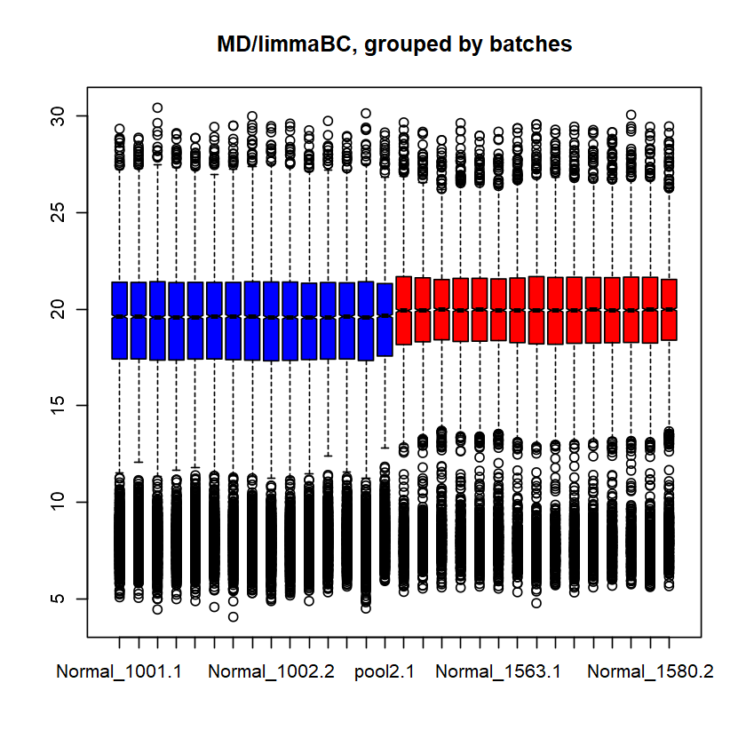

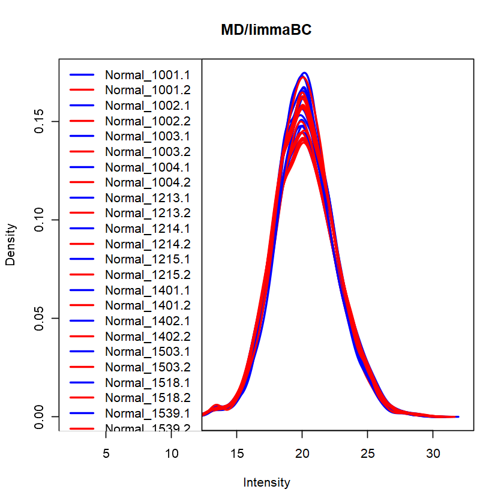

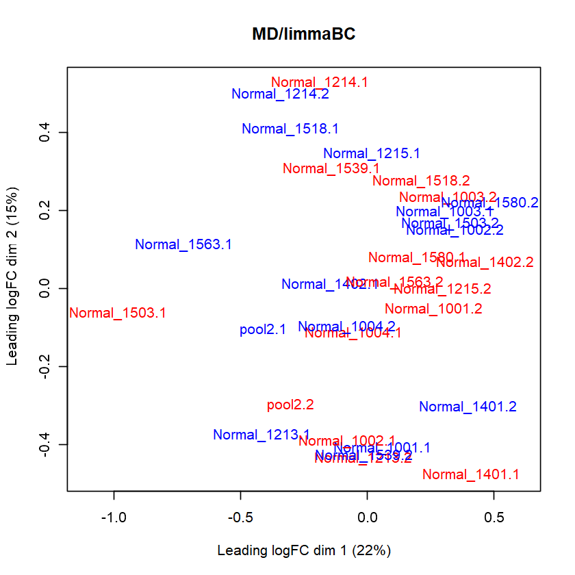

```r
# put groups together into a single data frame
colors = c(rep('blue', 15), rep('red', 15))
boxplot(data_MD_limmaBC, col = colors, notch = TRUE, main = "MD/limmaBC, grouped by batches")
# can also look at density plots (like a distribution histogram)
plotDensities(data_MD_limmaBC, col = rep(c("blue", "red"), 15), main = "MD/limmaBC")
plotMDS(data_MD_limmaBC, col = rep(c("blue", "red"), 15), main = "MD/limmaBC")
```

```r
# Preprocessing of the data
data_MD_limmaBC_forCV <- read_csv("PREDI_NMP12_limmaBC_forCV.csv")
```

```r
View(data_MD_limmaBC_forCV)
```

A spec_tbl_df: 5038 × 29

| ID <chr> | V1_Normal...2 <dbl> | V1_Normal...3 <dbl> | V1_Normal...4 <dbl> | V1_Normal...5 <dbl> | V1_Normal...6 <dbl> | V1_Normal...7 <dbl> | V1_Normal...8 <dbl> | V2_Normal...9 <dbl> | V2_Normal...10 <dbl> | ⋯ | V1_Normal...20 <dbl> | V1_Normal...21 <dbl> | V1_Normal...22 <dbl> | V2_Normal...23 <dbl> | V2_Normal...24 <dbl> | V2_Normal...25 <dbl> | V2_Normal...26 <dbl> | V2_Normal...27 <dbl> | V2_Normal...28 <dbl> | V2_Normal...29 <dbl> |
| --- | --- | --- | --- | --- | --- | --- | --- | --- | --- | --- | --- | --- | --- | --- | --- | --- | --- | --- | --- | --- |
| A0A024RBG1 | 5.942672e+05 | 5.257546e+05 | 4.670506e+05 | 5.672335e+05 | 5.339650e+05 | 5.608118e+05 | 6.050357e+05 | 5.460009e+05 | 7.009911e+05 | ⋯ | 544322.38 | 391550.1 | 608186.99 | 666202.26 | 662134.53 | 706228.64 | 715677.45 | 665803.3 | 617351.5 | 704071.7 |
| A0A075B6H7 | 1.185802e+06 | 1.464226e+06 | 7.932127e+05 | 1.431525e+06 | 1.214056e+06 | 6.027372e+05 | 9.080619e+05 | 8.850785e+05 | 8.333645e+05 | ⋯ | 1200936.73 | 885539.9 | 1013129.36 | 846177.41 | 917978.36 | 805412.49 | 905164.98 | 898939.6 | 1703776.5 | 1080551.5 |
| A0A075B6H9 | 5.388123e+05 | 3.992331e+05 | 3.693428e+05 | 4.152452e+05 | 8.239119e+05 | 4.003616e+05 | 4.199044e+05 | 3.733230e+05 | 3.212203e+05 | ⋯ | 479342.26 | 389786.7 | 368506.13 | 445194.81 | 446689.28 | 452593.17 | 456968.86 | 293896.9 | 736890.7 | 521378.1 |
| A0A075B6I0 | 1.966755e+06 | 1.728048e+06 | 2.216269e+06 | 2.090480e+06 | 2.736965e+06 | 1.267995e+06 | 4.373818e+05 | 1.615300e+06 | 1.449274e+06 | ⋯ | 1292058.39 | 1676848.0 | 2656553.12 | 1165231.96 | 1165558.88 | 459678.01 | 1245655.15 | 2129594.5 | 2240492.4 | 2279050.0 |
| A0A075B6I1 | 2.987910e+05 | 3.083568e+05 | 1.435546e+05 | 2.574031e+05 | 2.970020e+05 | 2.499258e+05 | 2.349106e+05 | 3.000410e+05 | 2.282009e+05 | ⋯ | 192981.14 | 425281.3 | 221811.97 | 184477.45 | 309658.04 | 148710.95 | 219899.96 | 199805.9 | 342601.1 | 212876.7 |
| A0A075B6I9 | 5.442384e+05 | 2.561680e+05 | 4.288303e+05 | 9.289550e+05 | 4.464324e+05 | 3.336818e+05 | 4.947112e+05 | 3.874561e+05 | 3.074699e+05 | ⋯ | 425673.74 | 544845.4 | 364103.15 | 304769.53 | 481345.58 | 436108.68 | 487148.88 | 374718.0 | 504851.8 | 358510.1 |
| A0A075B6K2 | 7.586585e+04 | 1.147668e+05 | 6.374799e+04 | 7.380916e+04 | 1.640147e+05 | 4.397045e+04 | 6.150675e+04 | 6.336025e+04 | 5.990486e+04 | ⋯ | 68180.38 | 129395.2 | 94622.55 | 35191.47 | 66232.49 | 67852.73 | 70709.22 | 131243.5 | 139200.7 | 76285.2 |
| A0A075B6Q5 | 1.450300e+06 | 4.669530e+06 | 1.290520e+06 | 3.048622e+06 | 4.702031e+06 | 1.466233e+06 | 2.023023e+06 | 9.892909e+05 | 1.725613e+06 | ⋯ | 1991386.58 | 2839631.6 | 1692926.87 | 2178639.71 | 1454868.43 | 1604468.65 | 1737265.33 | 1809414.5 | 3247607.9 | 1801731.5 |
| A0A075B6R2 | 7.703129e+02 | 1.794740e+03 | 5.910075e+02 | 5.583882e+02 | 1.507261e+03 | 5.265355e+02 | 5.610681e+02 | 4.416904e+02 | 6.256602e+02 | ⋯ | NA | NA | NA | NA | NA | NA | NA | NA | NA | NA |
| A0A075B6R9 | 3.187557e+06 | 2.196712e+06 | 3.110203e+06 | 3.152475e+06 | 3.820403e+06 | 2.576215e+06 | 3.434077e+06 | 3.184436e+06 | 2.047755e+06 | ⋯ | 3078146.94 | 2920701.7 | 3256711.36 | 1906610.62 | 2722017.59 | 2825509.40 | 2596577.67 | 2258950.3 | 2870867.1 | 3311919.3 |
| A0A075B6S2 | 5.278499e+06 | 5.410114e+06 | 4.536152e+06 | 6.107730e+06 | 7.453004e+06 | 2.214123e+06 | 4.174786e+06 | 4.406052e+06 | 4.284932e+06 | ⋯ | 4127901.89 | 4092459.2 | 6041980.05 | 4033679.26 | 6237688.51 | 3816363.10 | 4194679.20 | 5095412.3 | 7747288.6 | 6332512.9 |
| A0A075B6S6 | 2.822197e+06 | 2.368564e+06 | 1.434806e+06 | 2.459831e+06 | 2.728295e+06 | 1.620252e+06 | 1.655201e+06 | 2.037279e+06 | 1.272815e+06 | ⋯ | 1649437.42 | 2130858.5 | 2188018.04 | 1083130.73 | 2400555.42 | 1537208.89 | 1610304.18 | 2642620.2 | 2201311.5 | 1925798.8 |
| A0A087WSY4 | 2.190560e+05 | 3.657206e+05 | 1.997760e+05 | 3.028156e+05 | 3.764975e+05 | 2.466654e+05 | 2.607948e+05 | 2.080703e+05 | 2.323316e+05 | ⋯ | 487118.04 | 343219.6 | 191179.59 | 217400.52 | 175372.54 | 396934.74 | 187986.53 | 284156.8 | 272722.2 | 159702.3 |
| A0A0A0MRZ8 | 2.190820e+07 | 3.047196e+07 | 1.356843e+07 | 2.172401e+07 | 2.615868e+07 | 1.067601e+07 | 1.417951e+07 | 1.727586e+07 | 1.585568e+07 | ⋯ | 14347615.28 | 11444486.1 | 19901249.26 | 19407794.58 | 19431430.67 | 18521030.94 | 17334790.08 | 18108451.3 | 29232717.4 | 21865911.0 |
| A0A0A0MT89 | 1.983301e+02 | 2.465240e+02 | 1.787987e+02 | 1.262116e+02 | 2.210137e+02 | 1.140077e+02 | 1.581717e+02 | 1.555982e+02 | 1.279400e+02 | ⋯ | NA | NA | NA | NA | NA | NA | NA | NA | NA | NA |
| A0A0B4J1U7 | 2.657560e+06 | 1.859791e+06 | 1.195023e+06 | 1.938929e+06 | 2.693119e+06 | 1.103619e+06 | 1.071325e+06 | 1.478779e+06 | 1.069042e+06 | ⋯ | 1608791.77 | 2017743.0 | 1596864.25 | 1472807.78 | 2090948.81 | 1505397.17 | 1737350.17 | 1459618.0 | 1991036.7 | 1548681.1 |
| A0A0B4J2D5 | 7.909191e+06 | 7.750489e+06 | 9.670590e+06 | 7.198670e+06 | 3.890812e+06 | 5.716761e+06 | 8.148572e+06 | 1.020367e+07 | 9.878732e+06 | ⋯ | 6924431.26 | 4180570.8 | 7927593.51 | 9465551.86 | 8318503.27 | 10744408.16 | 8357481.82 | 7801862.5 | 7271022.3 | 7842562.0 |
| A0A0B4J2D9 | 4.244089e+06 | 9.293936e+06 | 2.958364e+06 | 3.581591e+06 | 7.659516e+06 | 2.384837e+06 | 3.058850e+06 | 3.099024e+06 | 2.361199e+06 | ⋯ | 3134644.79 | 5275651.2 | 4288111.33 | 2381231.91 | 2881954.21 | 3218060.57 | 4334001.85 | 3689521.8 | 8052757.6 | 3960858.7 |
| A0A0C4DH25 | 2.072144e+07 | 2.595958e+07 | 1.654103e+07 | 2.335465e+07 | 4.094015e+07 | 1.348880e+07 | 1.902519e+07 | 1.526625e+07 | 1.861820e+07 | ⋯ | 18728479.48 | 19489328.9 | 23486571.62 | 16922412.37 | 19911420.06 | 18136540.18 | 18182092.03 | 19688507.4 | 33456432.7 | 22791103.3 |
| A0A0C4DH29 | 6.254152e+06 | 1.432912e+07 | 5.656931e+06 | 6.808494e+06 | 2.403024e+07 | 4.010333e+06 | 8.217164e+06 | 4.042559e+06 | 4.851500e+06 | ⋯ | 8471180.27 | 10562053.2 | 7410498.01 | 3701803.97 | 5767498.41 | 4583682.45 | 7562159.51 | 9676488.4 | 11539246.6 | 7181969.4 |
| A0A0C4DH34 | 6.269631e+05 | 7.297943e+05 | 6.204326e+05 | 8.294268e+05 | 1.056358e+06 | 7.069263e+05 | 7.711696e+05 | 7.100563e+05 | 6.897748e+05 | ⋯ | 792277.16 | 891788.5 | 753902.06 | 640587.08 | 600988.51 | 809940.47 | 726862.34 | 724718.7 | 1142761.9 | 830925.3 |
| A0A0C4DH38 | 3.372821e+05 | 5.436424e+05 | 2.547845e+05 | 2.909020e+05 | 5.796963e+05 | 3.564836e+05 | 3.019873e+05 | 2.577748e+05 | 3.237372e+05 | ⋯ | 299479.47 | 714474.0 | 396031.08 | 267029.20 | 253155.59 | 221759.39 | 297395.79 | 374487.4 | 758213.7 | 372058.6 |
| A0A0C4DH39 | 4.133675e+02 | 7.311815e+02 | 3.963665e+02 | 3.972745e+02 | 1.721328e+03 | 4.464711e+02 | 5.241395e+02 | 3.253979e+02 | 3.966344e+02 | ⋯ | NA | NA | NA | NA | NA | NA | NA | NA | NA | NA |
| A0A0C4DH41 | 2.682329e+06 | 2.862684e+06 | 2.781207e+06 | 2.540499e+06 | 3.262394e+06 | 2.759669e+06 | 3.191873e+06 | 2.157632e+06 | 2.392314e+06 | ⋯ | 2442063.68 | 3843814.8 | 2608079.27 | 2360319.50 | 2362420.29 | 2346771.31 | 2191183.70 | 2310724.7 | 4464085.5 | 2721762.1 |
| A0A0J9YXX1 | 2.902660e+06 | 5.554537e+05 | 1.374878e+06 | 1.599819e+06 | 4.797831e+06 | 1.978286e+06 | 1.402717e+06 | 1.837133e+06 | 6.841257e+05 | ⋯ | 576900.78 | 6567906.1 | 2621805.61 | 3525679.71 | 1407571.86 | 1137427.26 | 694899.45 | 862815.6 | 8060679.0 | 2662368.1 |
| A0AV96 | 1.609638e+06 | 1.594699e+06 | 1.945635e+06 | 1.984601e+06 | 1.837050e+06 | 2.192534e+06 | 2.019031e+06 | 1.622116e+06 | 1.771590e+06 | ⋯ | 2119702.20 | 2098326.8 | 1890380.96 | 1367943.83 | 2020294.75 | 2168477.13 | 1853279.29 | 1761107.4 | 1897210.8 | 1925636.2 |
| A0AVT1 | 1.210367e+06 | 1.083626e+06 | 1.430608e+06 | 1.220310e+06 | 1.363948e+06 | 1.208637e+06 | 1.271903e+06 | 1.058570e+06 | 1.249051e+06 | ⋯ | 1300075.99 | 1096408.6 | 1075953.57 | 1205737.68 | 1211391.33 | 1202623.60 | 1137354.65 | 1196781.1 | 1292934.8 | 1210655.8 |
| A0FGR8 | 1.005363e+06 | 1.123690e+06 | 1.156673e+06 | 1.230459e+06 | 1.321462e+06 | 1.323902e+06 | 1.191066e+06 | 9.358524e+05 | 1.181009e+06 | ⋯ | 1399376.01 | 1349710.2 | 1100049.54 | 1003456.89 | 1245443.27 | 1051802.18 | 1098727.07 | 1284641.4 | 1283937.6 | 1262114.3 |
| A0M8Q6 | 1.373763e+05 | 2.181224e+05 | 6.043992e+05 | 8.801555e+05 | 1.815914e+06 | 2.467905e+05 | 1.110815e+06 | 2.006620e+05 | 1.326904e+05 | ⋯ | 1077349.28 | 191517.9 | 690008.97 | 646224.43 | 257411.57 | 661151.77 | 467560.38 | 1561988.8 | 369408.5 | 555492.5 |
| A0MZ66 | 9.912379e+05 | 1.094416e+06 | 8.984772e+05 | 9.456684e+05 | 8.214551e+05 | 1.112229e+06 | 9.824523e+05 | 9.285405e+05 | 1.164341e+06 | ⋯ | 949203.36 | 1159729.0 | 1040299.96 | 995353.51 | 1004222.14 | 997527.87 | 1029681.73 | 890250.1 | 873346.5 | 866159.5 |
| ⋮ | ⋮ | ⋮ | ⋮ | ⋮ | ⋮ | ⋮ | ⋮ | ⋮ | ⋮ | ⋱ | ⋮ | ⋮ | ⋮ | ⋮ | ⋮ | ⋮ | ⋮ | ⋮ | ⋮ | ⋮ |
| Q9Y6D5 | 2.398101e+06 | 2.035178e+06 | 2.790387e+06 | 2.795745e+06 | 3.275957e+06 | 2.865452e+06 | 2.788303e+06 | 2.558841e+06 | 3.049657e+06 | ⋯ | 3.585502e+06 | 2.395571e+06 | 2.477528e+06 | 2.434684e+06 | 3.001327e+06 | 2.915466e+06 | 2.779898e+06 | 2.617391e+06 | 3.093165e+06 | 3.895193e+06 |
| Q9Y6D6 | 4.642793e+05 | 4.653003e+05 | 5.107120e+05 | 4.788305e+05 | 5.136833e+05 | 6.563404e+05 | 5.653989e+05 | 5.194400e+05 | 4.938609e+05 | ⋯ | 6.544906e+05 | 4.038323e+05 | 4.195478e+05 | 4.886643e+05 | 5.865535e+05 | 4.422514e+05 | 4.972857e+05 | 3.894231e+05 | 1.088305e+06 | 7.766912e+05 |
| Q9Y6D9 | NA | NA | NA | NA | NA | NA | NA | NA | NA | ⋯ | 1.680783e+02 | 2.881478e+02 | 1.750468e+02 | 1.586026e+02 | 1.662732e+02 | 1.501944e+02 | 1.631280e+02 | 2.245810e+02 | 1.616285e+02 | 1.570489e+02 |
| Q9Y6E0 | 1.817465e+06 | 2.026664e+06 | 2.182705e+06 | 2.046970e+06 | 1.755198e+06 | 2.255712e+06 | 2.362819e+06 | 2.049752e+06 | 2.208677e+06 | ⋯ | 2.213297e+06 | 2.290121e+06 | 2.049020e+06 | 1.883235e+06 | 1.844149e+06 | 2.183553e+06 | 2.204979e+06 | 1.742199e+06 | 1.848575e+06 | 2.104390e+06 |
| Q9Y6E2 | 1.659468e+06 | 1.728194e+06 | 1.691789e+06 | 1.713716e+06 | 1.886880e+06 | 2.060408e+06 | 1.827461e+06 | 1.759139e+06 | 1.560045e+06 | ⋯ | 1.635393e+06 | 1.609172e+06 | 1.769324e+06 | 1.729070e+06 | 2.091438e+06 | 1.719087e+06 | 1.762984e+06 | 1.603129e+06 | 1.815053e+06 | 2.068511e+06 |
| Q9Y6F6 | 1.359477e+05 | 1.717934e+05 | 1.234142e+05 | 1.265017e+05 | 1.360198e+05 | 1.458268e+05 | 1.165694e+05 | 1.566413e+05 | 1.569591e+05 | ⋯ | 1.622919e+05 | 1.733897e+05 | 1.556961e+05 | 1.317878e+05 | 1.165773e+05 | 1.280622e+05 | 1.398223e+05 | 1.532751e+05 | 1.699224e+05 | 9.983834e+04 |
| Q9Y6G3 | 1.556475e+05 | 1.513905e+05 | 1.012682e+05 | 1.076361e+05 | 9.399510e+04 | 1.203530e+05 | 1.260081e+05 | 1.437231e+05 | 9.868163e+04 | ⋯ | 1.017872e+05 | 1.112640e+05 | 9.959015e+04 | 1.094544e+05 | 8.845468e+04 | 9.185762e+04 | 1.351628e+05 | 9.579551e+04 | 8.470010e+04 | 9.178766e+04 |
| Q9Y6G5 | 3.381372e+02 | 3.259789e+02 | 4.270244e+02 | 3.861451e+02 | 3.395682e+02 | 4.695984e+02 | 4.435344e+02 | 4.638829e+02 | 3.989451e+02 | ⋯ | NA | NA | NA | NA | NA | NA | NA | NA | NA | NA |
| Q9Y6G9 | 2.192299e+06 | 2.026306e+06 | 2.676534e+06 | 2.173756e+06 | 2.023389e+06 | 1.798338e+06 | 2.109566e+06 | 2.313041e+06 | 2.108320e+06 | ⋯ | 2.091024e+06 | 2.380390e+06 | 2.015591e+06 | 2.255266e+06 | 2.106236e+06 | 1.894793e+06 | 1.856940e+06 | 2.538425e+06 | 1.863662e+06 | 1.784304e+06 |
| Q9Y6H1 | 5.251297e+05 | 5.737602e+05 | 5.442959e+05 | 5.055815e+05 | 5.123614e+05 | 6.387608e+05 | 6.549186e+05 | 5.839908e+05 | 5.362809e+05 | ⋯ | 8.262735e+05 | 6.596494e+05 | 5.702069e+05 | 4.713485e+05 | 4.428011e+05 | 4.854938e+05 | 5.277239e+05 | 5.390017e+05 | 3.732645e+05 | 3.770852e+05 |
| Q9Y6I3 | 6.277999e+05 | 7.364566e+05 | 5.540590e+05 | 6.028877e+05 | 4.613783e+05 | 6.897835e+05 | 6.324473e+05 | 6.967154e+05 | 6.356107e+05 | ⋯ | 5.653884e+05 | 6.180144e+05 | 6.481612e+05 | 6.117747e+05 | 5.482000e+05 | 6.333751e+05 | 6.443092e+05 | 7.021766e+05 | 5.797157e+05 | 6.162120e+05 |
| Q9Y6I4 | 1.866721e+02 | 2.563346e+02 | 1.618272e+02 | 2.538351e+02 | 3.123034e+02 | 5.159658e+02 | 4.347905e+02 | 1.804244e+02 | 1.684682e+02 | ⋯ | NA | NA | NA | NA | NA | NA | NA | NA | NA | NA |
| Q9Y6I9 | 1.411363e+05 | 1.505150e+05 | 1.311019e+05 | 1.378086e+05 | 1.993837e+05 | 1.961046e+05 | 1.849444e+05 | 1.349758e+05 | 1.233299e+05 | ⋯ | 1.344664e+05 | 1.491975e+05 | 1.275615e+05 | 1.627356e+05 | 1.277917e+05 | 1.380182e+05 | 1.388309e+05 | 1.749775e+05 | 1.507881e+05 | 1.185029e+05 |
| Q9Y6K0 | NA | NA | NA | NA | NA | NA | NA | NA | NA | ⋯ | 1.671369e+02 | 1.104390e+02 | 1.193391e+02 | 1.330221e+02 | 1.775729e+02 | 1.465527e+02 | 1.478812e+02 | 1.196061e+02 | 2.204987e+02 | 1.925994e+02 |
| Q9Y6K5 | 1.571453e+05 | 1.060581e+05 | 1.931153e+05 | 1.561197e+05 | 1.884185e+05 | 7.586250e+04 | 1.276425e+05 | 1.130197e+05 | 1.490540e+05 | ⋯ | 1.479252e+05 | 1.711218e+05 | 1.192173e+05 | 1.267370e+05 | 1.896673e+05 | 1.478865e+05 | 1.312038e+05 | 1.452478e+05 | 1.398483e+05 | 1.453393e+05 |
| Q9Y6K9 | 1.053196e+06 | 1.063641e+06 | 7.703925e+05 | 1.005696e+06 | 1.034707e+06 | 1.072235e+06 | 9.945713e+05 | 9.007087e+05 | 8.106608e+05 | ⋯ | 8.091894e+05 | 1.149349e+06 | 9.043859e+05 | 1.059739e+06 | 7.441290e+05 | 7.559922e+05 | 8.964918e+05 | 1.033647e+06 | 8.279112e+05 | 8.290137e+05 |
| Q9Y6M1 | 5.916432e+05 | 6.599423e+05 | 7.282576e+05 | 6.997704e+05 | 6.542353e+05 | 7.304649e+05 | 8.693512e+05 | 7.396262e+05 | 8.459960e+05 | ⋯ | 8.294778e+05 | 5.919760e+05 | 6.982367e+05 | 6.599325e+05 | 7.740268e+05 | 8.393259e+05 | 7.245387e+05 | 7.286587e+05 | 8.459201e+05 | 7.926681e+05 |
| Q9Y6M7 | NA | NA | NA | NA | NA | NA | NA | NA | NA | ⋯ | 3.244577e+02 | 3.807304e+02 | 2.571363e+02 | 2.876054e+02 | 2.585520e+02 | 2.818840e+02 | 2.625072e+02 | 2.410754e+02 | 2.840327e+02 | 2.938467e+02 |
| Q9Y6M9 | 8.095115e+05 | 7.449931e+05 | 1.104308e+06 | 8.284840e+05 | 5.821272e+05 | 8.504189e+05 | 9.549370e+05 | 1.038694e+06 | 1.163669e+06 | ⋯ | 7.809956e+05 | 8.901507e+05 | 9.904771e+05 | 8.808660e+05 | 8.256064e+05 | 8.937943e+05 | 1.120109e+06 | 7.938186e+05 | 8.089563e+05 | 9.356287e+05 |
| Q9Y6N5 | 4.644558e+06 | 5.251534e+06 | 7.737489e+06 | 6.414158e+06 | 7.028189e+06 | 5.601518e+06 | 5.387571e+06 | 4.706773e+06 | 6.454715e+06 | ⋯ | 5.937686e+06 | 6.219289e+06 | 5.566581e+06 | 5.292632e+06 | 5.661944e+06 | 8.149568e+06 | 7.047284e+06 | 4.564374e+06 | 7.594821e+06 | 7.595741e+06 |
| Q9Y6N9 | 1.291994e+06 | 1.265282e+06 | 1.699707e+06 | 1.351020e+06 | 1.482599e+06 | 1.696238e+06 | 1.547828e+06 | 1.378213e+06 | 1.879998e+06 | ⋯ | 2.040424e+06 | 1.813617e+06 | 1.546205e+06 | 9.199733e+05 | 1.596749e+06 | 1.599103e+06 | 1.499114e+06 | 1.071260e+06 | 1.473689e+06 | 1.803331e+06 |
| Q9Y6Q5 | 9.879035e+05 | 7.635408e+05 | 1.228491e+06 | 8.170422e+05 | 1.525942e+06 | 9.850987e+05 | 9.139032e+05 | 7.898646e+05 | 1.209262e+06 | ⋯ | 1.413703e+06 | 9.537220e+05 | 9.122806e+05 | 8.429289e+05 | 1.087330e+06 | 1.253172e+06 | 1.014411e+06 | 9.147943e+05 | 1.184495e+06 | 1.334512e+06 |
| Q9Y6R1 | 7.669740e+05 | 6.607741e+05 | 1.328534e+06 | 1.223491e+06 | 8.201098e+05 | 1.243020e+06 | 1.047807e+06 | 8.569684e+05 | 1.423567e+06 | ⋯ | 1.703601e+06 | 1.174247e+06 | 9.463934e+05 | 6.870683e+05 | 1.110299e+06 | 1.153566e+06 | 1.018288e+06 | 7.036341e+05 | 1.089905e+06 | 1.339436e+06 |
| Q9Y6R7 | 4.478374e+07 | 4.161310e+07 | 4.672659e+07 | 4.151184e+07 | 2.437312e+07 | 5.485907e+07 | 4.973471e+07 | 5.632162e+07 | 5.335470e+07 | ⋯ | 5.424655e+07 | 4.610723e+07 | 3.942431e+07 | 3.939191e+07 | 4.539600e+07 | 5.521060e+07 | 6.621526e+07 | 3.978924e+07 | 6.213118e+07 | 6.563723e+07 |
| Q9Y6U3 | 5.788547e+05 | 6.022159e+05 | 8.941357e+05 | 9.158720e+05 | 5.486903e+05 | 1.136983e+06 | 9.760147e+05 | 7.851561e+05 | 9.529517e+05 | ⋯ | 1.384830e+06 | 7.690893e+05 | 7.104825e+05 | 6.123533e+05 | 8.438635e+05 | 9.985626e+05 | 9.017445e+05 | 6.179114e+05 | 9.749859e+05 | 8.612938e+05 |
| Q9Y6W3 | 1.883959e+05 | 1.816302e+05 | 1.973544e+05 | 1.829811e+05 | 1.859977e+05 | 2.113285e+05 | 1.908506e+05 | 1.672787e+05 | 1.859980e+05 | ⋯ | 2.198356e+05 | 2.008141e+05 | 1.708946e+05 | 1.657483e+05 | 1.946508e+05 | 1.746444e+05 | 2.093349e+05 | 1.855899e+05 | 1.926384e+05 | 1.937808e+05 |
| Q9Y6W5 | 2.390596e+06 | 2.230097e+06 | 1.873635e+06 | 2.263995e+06 | 1.789587e+06 | 1.936429e+06 | 2.098098e+06 | 2.436928e+06 | 1.961317e+06 | ⋯ | 1.756084e+06 | 1.972361e+06 | 2.121088e+06 | 2.404865e+06 | 2.002792e+06 | 1.869942e+06 | 2.328525e+06 | 2.218531e+06 | 1.927649e+06 | 1.886015e+06 |
| Q9Y6X5 | 1.008078e+04 | 1.020794e+04 | 1.592657e+04 | 8.208173e+03 | 6.417748e+03 | 8.912751e+03 | 8.304695e+03 | 1.175701e+04 | 1.360098e+04 | ⋯ | 8.492327e+03 | 1.102255e+04 | 1.111732e+04 | 1.276489e+04 | 1.094896e+04 | 1.125318e+04 | 9.087206e+03 | 6.812537e+03 | 1.451599e+04 | 1.208200e+04 |
| Q9Y6X9 | 8.471828e+02 | 8.001755e+02 | 7.815518e+02 | 8.804684e+02 | 8.352597e+02 | 1.313669e+03 | 9.153309e+02 | 7.737973e+02 | 7.203873e+02 | ⋯ | NA | NA | NA | NA | NA | NA | NA | NA | NA | NA |
| Q9Y6Y8 | 8.088258e+05 | 8.198186e+05 | 9.000077e+05 | 8.639263e+05 | 1.040051e+06 | 8.469003e+05 | 9.306269e+05 | 7.575564e+05 | 9.678199e+05 | ⋯ | 1.156206e+06 | 6.569211e+05 | 7.038823e+05 | 9.730259e+05 | 1.110573e+06 | 1.211055e+06 | 7.219252e+05 | 7.744399e+05 | 1.089840e+06 | 1.025807e+06 |

```r
# separate ID from the data
ID <- data_MD_limmaBC_forCV$ID
data_MD_limmaBC_forCV <- data_MD_limmaBC_forCV %>% select(-ID)
```

```r
# define the groups
Normal_V1 <- select(data_MD_limmaBC_forCV, contains("V1_Normal"))
Normal_V2 <- select(data_MD_limmaBC_forCV, contains("V2_Normal"))
```

```r
group <- c(rep("Normal_V1", 14), rep("Normal_V2", 14))
```

```r
nrow(Normal_V1)
ncol(Normal_V1)
nrow(Normal_V2)
ncol(Normal_V2)
```

5038

14

5038

14

```r
# put groups together into a single data frame (we have added the bridge channels)
BC_abd <- bind_cols(Normal_V1, Normal_V2)

# define which columns go with each group
Normal_V1 <- 1:14
Normal_V2 <- 15:28

# set some colors by group
colors = c(rep('red', 14), rep('blue', 14))
```

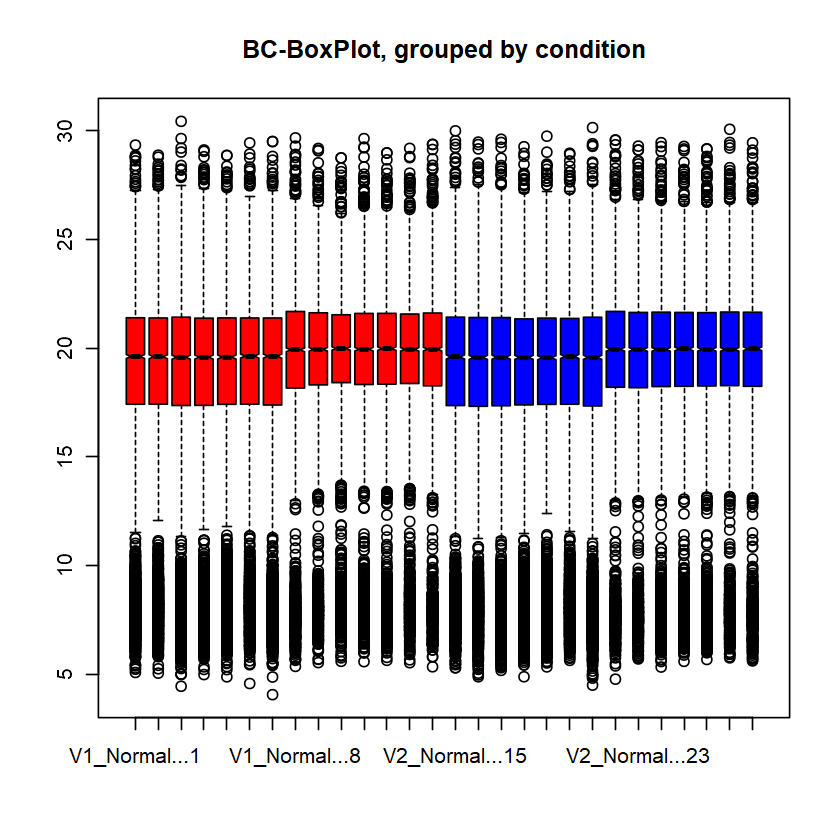

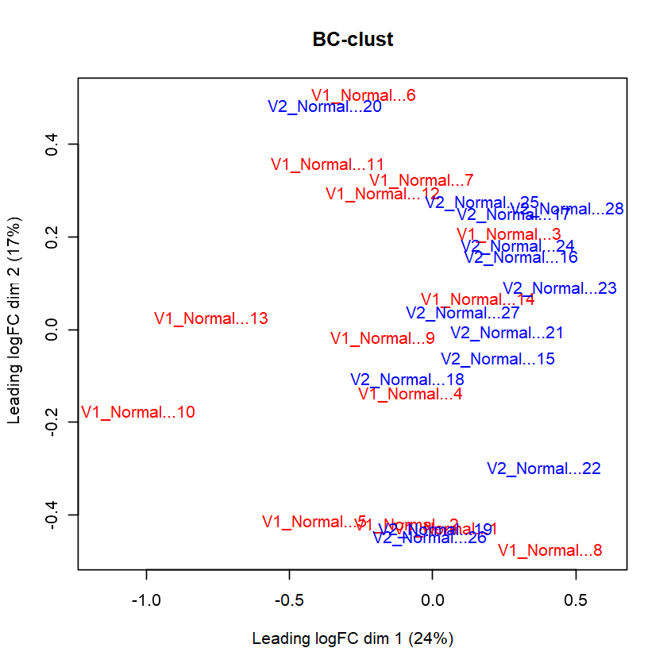

```r
boxplot(log2(BC_abd), col = colors, notch = TRUE, main = "BC-BoxPlot, grouped by condition")
plotMDS(log2(BC_abd), main = "BC-clust", col = colors)
```

```r
# Convert NA value to zero
BC_abd[is.na(BC_abd)] <- 0
View(BC_abd)
```

A tibble: 5038 × 28

| V1_Normal...1 <dbl> | V1_Normal...2 <dbl> | V1_Normal...3 <dbl> | V1_Normal...4 <dbl> | V1_Normal...5 <dbl> | V1_Normal...6 <dbl> | V1_Normal...7 <dbl> | V1_Normal...8 <dbl> | V1_Normal...9 <dbl> | V1_Normal...10 <dbl> | ⋯ | V2_Normal...19 <dbl> | V2_Normal...20 <dbl> | V2_Normal...21 <dbl> | V2_Normal...22 <dbl> | V2_Normal...23 <dbl> | V2_Normal...24 <dbl> | V2_Normal...25 <dbl> | V2_Normal...26 <dbl> | V2_Normal...27 <dbl> | V2_Normal...28 <dbl> |
| --- | --- | --- | --- | --- | --- | --- | --- | --- | --- | --- | --- | --- | --- | --- | --- | --- | --- | --- | --- | --- |
| 5.942672e+05 | 5.257546e+05 | 4.670506e+05 | 5.672335e+05 | 5.339650e+05 | 5.608118e+05 | 6.050357e+05 | 742819.33 | 422788.48 | 410464.8 | ⋯ | 6.033889e+05 | 4.746204e+05 | 5.648022e+05 | 666202.26 | 662134.53 | 706228.64 | 715677.45 | 665803.3 | 617351.5 | 704071.7 |
| 1.185802e+06 | 1.464226e+06 | 7.932127e+05 | 1.431525e+06 | 1.214056e+06 | 6.027372e+05 | 9.080619e+05 | 1209283.93 | 884498.05 | 766057.5 | ⋯ | 1.467675e+06 | 6.787355e+05 | 9.140727e+05 | 846177.41 | 917978.36 | 805412.49 | 905164.98 | 898939.6 | 1703776.5 | 1080551.5 |
| 5.388123e+05 | 3.992331e+05 | 3.693428e+05 | 4.152452e+05 | 8.239119e+05 | 4.003616e+05 | 4.199044e+05 | 484062.62 | 479869.41 | 474218.6 | ⋯ | 9.502457e+05 | 3.746945e+05 | 5.916688e+05 | 445194.81 | 446689.28 | 452593.17 | 456968.86 | 293896.9 | 736890.7 | 521378.1 |
| 1.966755e+06 | 1.728048e+06 | 2.216269e+06 | 2.090480e+06 | 2.736965e+06 | 1.267995e+06 | 4.373818e+05 | 1630480.71 | 1293068.75 | 738728.5 | ⋯ | 2.724577e+06 | 8.924353e+05 | 4.031109e+05 | 1165231.96 | 1165558.88 | 459678.01 | 1245655.15 | 2129594.5 | 2240492.4 | 2279050.0 |
| 2.987910e+05 | 3.083568e+05 | 1.435546e+05 | 2.574031e+05 | 2.970020e+05 | 2.499258e+05 | 2.349106e+05 | 353238.59 | 401339.71 | 300598.1 | ⋯ | 4.523162e+05 | 2.535332e+05 | 2.160410e+05 | 184477.45 | 309658.04 | 148710.95 | 219899.96 | 199805.9 | 342601.1 | 212876.7 |
| 5.442384e+05 | 2.561680e+05 | 4.288303e+05 | 9.289550e+05 | 4.464324e+05 | 3.336818e+05 | 4.947112e+05 | 422722.20 | 465471.37 | 464123.6 | ⋯ | 6.271185e+05 | 3.094769e+05 | 5.029893e+05 | 304769.53 | 481345.58 | 436108.68 | 487148.88 | 374718.0 | 504851.8 | 358510.1 |
| 7.586585e+04 | 1.147668e+05 | 6.374799e+04 | 7.380916e+04 | 1.640147e+05 | 4.397045e+04 | 6.150675e+04 | 37326.69 | 70371.52 | 124141.7 | ⋯ | 1.474816e+05 | 5.448491e+04 | 9.840107e+04 | 35191.47 | 66232.49 | 67852.73 | 70709.22 | 131243.5 | 139200.7 | 76285.2 |
| 1.450300e+06 | 4.669530e+06 | 1.290520e+06 | 3.048622e+06 | 4.702031e+06 | 1.466233e+06 | 2.023023e+06 | 4737633.35 | 1978284.00 | 3135915.7 | ⋯ | 4.419926e+06 | 1.773872e+06 | 2.800762e+06 | 2178639.71 | 1454868.43 | 1604468.65 | 1737265.33 | 1809414.5 | 3247607.9 | 1801731.5 |
| 7.703129e+02 | 1.794740e+03 | 5.910075e+02 | 5.583882e+02 | 1.507261e+03 | 5.265355e+02 | 5.610681e+02 | 0.00 | 0.00 | 0.0 | ⋯ | 1.579098e+03 | 5.213692e+02 | 6.638065e+02 | 0.00 | 0.00 | 0.00 | 0.00 | 0.0 | 0.0 | 0.0 |
| 3.187557e+06 | 2.196712e+06 | 3.110203e+06 | 3.152475e+06 | 3.820403e+06 | 2.576215e+06 | 3.434077e+06 | 2045934.87 | 3948486.21 | 3606191.5 | ⋯ | 4.675770e+06 | 2.704078e+06 | 3.775344e+06 | 1906610.62 | 2722017.59 | 2825509.40 | 2596577.67 | 2258950.3 | 2870867.1 | 3311919.3 |
| 5.278499e+06 | 5.410114e+06 | 4.536152e+06 | 6.107730e+06 | 7.453004e+06 | 2.214123e+06 | 4.174786e+06 | 5370313.35 | 5266544.22 | 3276316.0 | ⋯ | 9.977208e+06 | 2.837422e+06 | 5.533699e+06 | 4033679.26 | 6237688.51 | 3816363.10 | 4194679.20 | 5095412.3 | 7747288.6 | 6332512.9 |
| 2.822197e+06 | 2.368564e+06 | 1.434806e+06 | 2.459831e+06 | 2.728295e+06 | 1.620252e+06 | 1.655201e+06 | 1353843.69 | 3306694.98 | 2897532.9 | ⋯ | 2.215290e+06 | 1.661523e+06 | 1.878912e+06 | 1083130.73 | 2400555.42 | 1537208.89 | 1610304.18 | 2642620.2 | 2201311.5 | 1925798.8 |
| 2.190560e+05 | 3.657206e+05 | 1.997760e+05 | 3.028156e+05 | 3.764975e+05 | 2.466654e+05 | 2.607948e+05 | 259932.41 | 491968.39 | 578029.8 | ⋯ | 6.158737e+05 | 2.973813e+05 | 3.646096e+05 | 217400.52 | 175372.54 | 396934.74 | 187986.53 | 284156.8 | 272722.2 | 159702.3 |
| 2.190820e+07 | 3.047196e+07 | 1.356843e+07 | 2.172401e+07 | 2.615868e+07 | 1.067601e+07 | 1.417951e+07 | 36523629.17 | 22554693.57 | 7649252.5 | ⋯ | 4.322137e+07 | 1.182928e+07 | 2.199531e+07 | 19407794.58 | 19431430.67 | 18521030.94 | 17334790.08 | 18108451.3 | 29232717.4 | 21865911.0 |
| 1.983301e+02 | 2.465240e+02 | 1.787987e+02 | 1.262116e+02 | 2.210137e+02 | 1.140077e+02 | 1.581717e+02 | 0.00 | 0.00 | 0.0 | ⋯ | 3.399921e+02 | 1.537542e+02 | 2.542309e+02 | 0.00 | 0.00 | 0.00 | 0.00 | 0.0 | 0.0 | 0.0 |
| 2.657560e+06 | 1.859791e+06 | 1.195023e+06 | 1.938929e+06 | 2.693119e+06 | 1.103619e+06 | 1.071325e+06 | 1689998.75 | 2415075.13 | 1728168.5 | ⋯ | 3.143387e+06 | 1.339275e+06 | 1.623684e+06 | 1472807.78 | 2090948.81 | 1505397.17 | 1737350.17 | 1459618.0 | 1991036.7 | 1548681.1 |
| 7.909191e+06 | 7.750489e+06 | 9.670590e+06 | 7.198670e+06 | 3.890812e+06 | 5.716761e+06 | 8.148572e+06 | 9019645.18 | 7669338.09 | 3840478.1 | ⋯ | 5.957809e+06 | 5.420359e+06 | 1.034573e+07 | 9465551.86 | 8318503.27 | 10744408.16 | 8357481.82 | 7801862.5 | 7271022.3 | 7842562.0 |
| 4.244089e+06 | 9.293936e+06 | 2.958364e+06 | 3.581591e+06 | 7.659516e+06 | 2.384837e+06 | 3.058850e+06 | 3882971.64 | 4504371.66 | 2609654.3 | ⋯ | 7.154417e+06 | 3.669009e+06 | 3.397325e+06 | 2381231.91 | 2881954.21 | 3218060.57 | 4334001.85 | 3689521.8 | 8052757.6 | 3960858.7 |
| 2.072144e+07 | 2.595958e+07 | 1.654103e+07 | 2.335465e+07 | 4.094015e+07 | 1.348880e+07 | 1.902519e+07 | 36661820.22 | 23623816.34 | 15686051.5 | ⋯ | 4.239368e+07 | 1.456922e+07 | 1.898191e+07 | 16922412.37 | 19911420.06 | 18136540.18 | 18182092.03 | 19688507.4 | 33456432.7 | 22791103.3 |
| 6.254152e+06 | 1.432912e+07 | 5.656931e+06 | 6.808494e+06 | 2.403024e+07 | 4.010333e+06 | 8.217164e+06 | 7218004.49 | 8740070.46 | 7871599.0 | ⋯ | 1.621437e+07 | 5.086237e+06 | 8.351752e+06 | 3701803.97 | 5767498.41 | 4583682.45 | 7562159.51 | 9676488.4 | 11539246.6 | 7181969.4 |
| 6.269631e+05 | 7.297943e+05 | 6.204326e+05 | 8.294268e+05 | 1.056358e+06 | 7.069263e+05 | 7.711696e+05 | 626747.94 | 706411.96 | 1531328.5 | ⋯ | 1.244064e+06 | 7.342007e+05 | 9.777248e+05 | 640587.08 | 600988.51 | 809940.47 | 726862.34 | 724718.7 | 1142761.9 | 830925.3 |
| 3.372821e+05 | 5.436424e+05 | 2.547845e+05 | 2.909020e+05 | 5.796963e+05 | 3.564836e+05 | 3.019873e+05 | 395290.99 | 369709.79 | 354674.9 | ⋯ | 5.405873e+05 | 3.781336e+05 | 3.859205e+05 | 267029.20 | 253155.59 | 221759.39 | 297395.79 | 374487.4 | 758213.7 | 372058.6 |
| 4.133675e+02 | 7.311815e+02 | 3.963665e+02 | 3.972745e+02 | 1.721328e+03 | 4.464711e+02 | 5.241395e+02 | 0.00 | 0.00 | 0.0 | ⋯ | 1.019311e+03 | 5.523511e+02 | 6.916835e+02 | 0.00 | 0.00 | 0.00 | 0.00 | 0.0 | 0.0 | 0.0 |
| 2.682329e+06 | 2.862684e+06 | 2.781207e+06 | 2.540499e+06 | 3.262394e+06 | 2.759669e+06 | 3.191873e+06 | 3655794.16 | 2645681.84 | 3320749.9 | ⋯ | 3.323294e+06 | 2.793458e+06 | 2.533597e+06 | 2360319.50 | 2362420.29 | 2346771.31 | 2191183.70 | 2310724.7 | 4464085.5 | 2721762.1 |
| 2.902660e+06 | 5.554537e+05 | 1.374878e+06 | 1.599819e+06 | 4.797831e+06 | 1.978286e+06 | 1.402717e+06 | 6475542.13 | 1708030.54 | 886423.8 | ⋯ | 4.909461e+06 | 2.868186e+06 | 2.619355e+06 | 3525679.71 | 1407571.86 | 1137427.26 | 694899.45 | 862815.6 | 8060679.0 | 2662368.1 |
| 1.609638e+06 | 1.594699e+06 | 1.945635e+06 | 1.984601e+06 | 1.837050e+06 | 2.192534e+06 | 2.019031e+06 | 1400373.54 | 2173841.89 | 2012359.9 | ⋯ | 1.462570e+06 | 2.428949e+06 | 1.743858e+06 | 1367943.83 | 2020294.75 | 2168477.13 | 1853279.29 | 1761107.4 | 1897210.8 | 1925636.2 |
| 1.210367e+06 | 1.083626e+06 | 1.430608e+06 | 1.220310e+06 | 1.363948e+06 | 1.208637e+06 | 1.271903e+06 | 1268571.41 | 1282570.69 | 1152673.2 | ⋯ | 1.154042e+06 | 1.141169e+06 | 1.160719e+06 | 1205737.68 | 1211391.33 | 1202623.60 | 1137354.65 | 1196781.1 | 1292934.8 | 1210655.8 |
| 1.005363e+06 | 1.123690e+06 | 1.156673e+06 | 1.230459e+06 | 1.321462e+06 | 1.323902e+06 | 1.191066e+06 | 999878.49 | 1142350.26 | 1363132.8 | ⋯ | 1.137434e+06 | 1.285801e+06 | 8.812711e+05 | 1003456.89 | 1245443.27 | 1051802.18 | 1098727.07 | 1284641.4 | 1283937.6 | 1262114.3 |
| 1.373763e+05 | 2.181224e+05 | 6.043992e+05 | 8.801555e+05 | 1.815914e+06 | 2.467905e+05 | 1.110815e+06 | 1314241.42 | 267684.18 | 250924.9 | ⋯ | 1.888273e+06 | 2.855648e+05 | 1.135858e+06 | 646224.43 | 257411.57 | 661151.77 | 467560.38 | 1561988.8 | 369408.5 | 555492.5 |
| 9.912379e+05 | 1.094416e+06 | 8.984772e+05 | 9.456684e+05 | 8.214551e+05 | 1.112229e+06 | 9.824523e+05 | 926138.40 | 1077343.20 | 1083220.4 | ⋯ | 8.076463e+05 | 1.162557e+06 | 9.697795e+05 | 995353.51 | 1004222.14 | 997527.87 | 1029681.73 | 890250.1 | 873346.5 | 866159.5 |
| ⋮ | ⋮ | ⋮ | ⋮ | ⋮ | ⋮ | ⋮ | ⋮ | ⋮ | ⋮ | ⋱ | ⋮ | ⋮ | ⋮ | ⋮ | ⋮ | ⋮ | ⋮ | ⋮ | ⋮ | ⋮ |
| 2.398101e+06 | 2.035178e+06 | 2.790387e+06 | 2.795745e+06 | 3.275957e+06 | 2.865452e+06 | 2.788303e+06 | 2.095001e+06 | 2.814621e+06 | 2.445233e+06 | ⋯ | 2.940451e+06 | 3.010756e+06 | 2.502233e+06 | 2.434684e+06 | 3.001327e+06 | 2.915466e+06 | 2.779898e+06 | 2.617391e+06 | 3.093165e+06 | 3.895193e+06 |
| 4.642793e+05 | 4.653003e+05 | 5.107120e+05 | 4.788305e+05 | 5.136833e+05 | 6.563404e+05 | 5.653989e+05 | 4.979499e+05 | 4.365004e+05 | 5.372369e+05 | ⋯ | 5.272542e+05 | 6.805165e+05 | 5.216028e+05 | 4.886643e+05 | 5.865535e+05 | 4.422514e+05 | 4.972857e+05 | 3.894231e+05 | 1.088305e+06 | 7.766912e+05 |
| 0.000000e+00 | 0.000000e+00 | 0.000000e+00 | 0.000000e+00 | 0.000000e+00 | 0.000000e+00 | 0.000000e+00 | 1.509183e+02 | 1.962202e+02 | 3.233882e+02 | ⋯ | 0.000000e+00 | 0.000000e+00 | 0.000000e+00 | 1.586026e+02 | 1.662732e+02 | 1.501944e+02 | 1.631280e+02 | 2.245810e+02 | 1.616285e+02 | 1.570489e+02 |
| 1.817465e+06 | 2.026664e+06 | 2.182705e+06 | 2.046970e+06 | 1.755198e+06 | 2.255712e+06 | 2.362819e+06 | 2.010010e+06 | 2.030083e+06 | 2.096589e+06 | ⋯ | 1.664240e+06 | 2.156586e+06 | 2.006694e+06 | 1.883235e+06 | 1.844149e+06 | 2.183553e+06 | 2.204979e+06 | 1.742199e+06 | 1.848575e+06 | 2.104390e+06 |
| 1.659468e+06 | 1.728194e+06 | 1.691789e+06 | 1.713716e+06 | 1.886880e+06 | 2.060408e+06 | 1.827461e+06 | 1.834023e+06 | 1.794670e+06 | 1.675883e+06 | ⋯ | 1.570598e+06 | 2.002537e+06 | 1.887135e+06 | 1.729070e+06 | 2.091438e+06 | 1.719087e+06 | 1.762984e+06 | 1.603129e+06 | 1.815053e+06 | 2.068511e+06 |
| 1.359477e+05 | 1.717934e+05 | 1.234142e+05 | 1.265017e+05 | 1.360198e+05 | 1.458268e+05 | 1.165694e+05 | 1.171380e+05 | 1.597427e+05 | 1.848827e+05 | ⋯ | 1.792051e+05 | 2.021927e+05 | 1.558876e+05 | 1.317878e+05 | 1.165773e+05 | 1.280622e+05 | 1.398223e+05 | 1.532751e+05 | 1.699224e+05 | 9.983834e+04 |
| 1.556475e+05 | 1.513905e+05 | 1.012682e+05 | 1.076361e+05 | 9.399510e+04 | 1.203530e+05 | 1.260081e+05 | 1.140068e+05 | 9.729368e+04 | 1.822686e+05 | ⋯ | 8.662660e+04 | 1.036335e+05 | 1.212715e+05 | 1.094544e+05 | 8.845468e+04 | 9.185762e+04 | 1.351628e+05 | 9.579551e+04 | 8.470010e+04 | 9.178766e+04 |
| 3.381372e+02 | 3.259789e+02 | 4.270244e+02 | 3.861451e+02 | 3.395682e+02 | 4.695984e+02 | 4.435344e+02 | 0.000000e+00 | 0.000000e+00 | 0.000000e+00 | ⋯ | 4.340745e+02 | 4.632463e+02 | 3.509637e+02 | 0.000000e+00 | 0.000000e+00 | 0.000000e+00 | 0.000000e+00 | 0.000000e+00 | 0.000000e+00 | 0.000000e+00 |
| 2.192299e+06 | 2.026306e+06 | 2.676534e+06 | 2.173756e+06 | 2.023389e+06 | 1.798338e+06 | 2.109566e+06 | 2.140953e+06 | 2.131626e+06 | 2.184023e+06 | ⋯ | 2.226669e+06 | 1.750448e+06 | 2.169072e+06 | 2.255266e+06 | 2.106236e+06 | 1.894793e+06 | 1.856940e+06 | 2.538425e+06 | 1.863662e+06 | 1.784304e+06 |
| 5.251297e+05 | 5.737602e+05 | 5.442959e+05 | 5.055815e+05 | 5.123614e+05 | 6.387608e+05 | 6.549186e+05 | 4.439881e+05 | 6.785048e+05 | 1.279387e+06 | ⋯ | 4.657599e+05 | 5.933047e+05 | 6.228412e+05 | 4.713485e+05 | 4.428011e+05 | 4.854938e+05 | 5.277239e+05 | 5.390017e+05 | 3.732645e+05 | 3.770852e+05 |
| 6.277999e+05 | 7.364566e+05 | 5.540590e+05 | 6.028877e+05 | 4.613783e+05 | 6.897835e+05 | 6.324473e+05 | 7.468034e+05 | 6.583106e+05 | 4.692274e+05 | ⋯ | 6.388595e+05 | 6.349852e+05 | 6.524888e+05 | 6.117747e+05 | 5.482000e+05 | 6.333751e+05 | 6.443092e+05 | 7.021766e+05 | 5.797157e+05 | 6.162120e+05 |
| 1.866721e+02 | 2.563346e+02 | 1.618272e+02 | 2.538351e+02 | 3.123034e+02 | 5.159658e+02 | 4.347905e+02 | 0.000000e+00 | 0.000000e+00 | 0.000000e+00 | ⋯ | 2.623355e+02 | 9.740842e+02 | 2.035417e+02 | 0.000000e+00 | 0.000000e+00 | 0.000000e+00 | 0.000000e+00 | 0.000000e+00 | 0.000000e+00 | 0.000000e+00 |
| 1.411363e+05 | 1.505150e+05 | 1.311019e+05 | 1.378086e+05 | 1.993837e+05 | 1.961046e+05 | 1.849444e+05 | 1.432798e+05 | 1.433076e+05 | 1.629175e+05 | ⋯ | 1.179424e+05 | 2.087467e+05 | 1.270370e+05 | 1.627356e+05 | 1.277917e+05 | 1.380182e+05 | 1.388309e+05 | 1.749775e+05 | 1.507881e+05 | 1.185029e+05 |
| 0.000000e+00 | 0.000000e+00 | 0.000000e+00 | 0.000000e+00 | 0.000000e+00 | 0.000000e+00 | 0.000000e+00 | 1.050364e+02 | 1.426084e+02 | 1.199987e+02 | ⋯ | 0.000000e+00 | 0.000000e+00 | 0.000000e+00 | 1.330221e+02 | 1.775729e+02 | 1.465527e+02 | 1.478812e+02 | 1.196061e+02 | 2.204987e+02 | 1.925994e+02 |
| 1.571453e+05 | 1.060581e+05 | 1.931153e+05 | 1.561197e+05 | 1.884185e+05 | 7.586250e+04 | 1.276425e+05 | 1.193769e+05 | 1.365600e+05 | 1.871439e+05 | ⋯ | 1.857855e+05 | 8.967653e+04 | 1.671249e+05 | 1.267370e+05 | 1.896673e+05 | 1.478865e+05 | 1.312038e+05 | 1.452478e+05 | 1.398483e+05 | 1.453393e+05 |
| 1.053196e+06 | 1.063641e+06 | 7.703925e+05 | 1.005696e+06 | 1.034707e+06 | 1.072235e+06 | 9.945713e+05 | 1.104918e+06 | 9.130060e+05 | 1.352637e+06 | ⋯ | 1.000086e+06 | 1.123806e+06 | 8.611547e+05 | 1.059739e+06 | 7.441290e+05 | 7.559922e+05 | 8.964918e+05 | 1.033647e+06 | 8.279112e+05 | 8.290137e+05 |
| 5.916432e+05 | 6.599423e+05 | 7.282576e+05 | 6.997704e+05 | 6.542353e+05 | 7.304649e+05 | 8.693512e+05 | 6.439417e+05 | 7.221014e+05 | 6.873776e+05 | ⋯ | 7.418437e+05 | 7.607975e+05 | 6.728958e+05 | 6.599325e+05 | 7.740268e+05 | 8.393259e+05 | 7.245387e+05 | 7.286587e+05 | 8.459201e+05 | 7.926681e+05 |
| 0.000000e+00 | 0.000000e+00 | 0.000000e+00 | 0.000000e+00 | 0.000000e+00 | 0.000000e+00 | 0.000000e+00 | 2.110934e+02 | 2.847514e+02 | 3.681398e+02 | ⋯ | 0.000000e+00 | 0.000000e+00 | 0.000000e+00 | 2.876054e+02 | 2.585520e+02 | 2.818840e+02 | 2.625072e+02 | 2.410754e+02 | 2.840327e+02 | 2.938467e+02 |
| 8.095115e+05 | 7.449931e+05 | 1.104308e+06 | 8.284840e+05 | 5.821272e+05 | 8.504189e+05 | 9.549370e+05 | 8.375060e+05 | 8.659075e+05 | 6.703779e+05 | ⋯ | 5.666336e+05 | 1.032313e+06 | 1.068685e+06 | 8.808660e+05 | 8.256064e+05 | 8.937943e+05 | 1.120109e+06 | 7.938186e+05 | 8.089563e+05 | 9.356287e+05 |
| 4.644558e+06 | 5.251534e+06 | 7.737489e+06 | 6.414158e+06 | 7.028189e+06 | 5.601518e+06 | 5.387571e+06 | 4.365534e+06 | 5.192468e+06 | 5.454350e+06 | ⋯ | 5.817804e+06 | 6.019786e+06 | 5.738687e+06 | 5.292632e+06 | 5.661944e+06 | 8.149568e+06 | 7.047284e+06 | 4.564374e+06 | 7.594821e+06 | 7.595741e+06 |
| 1.291994e+06 | 1.265282e+06 | 1.699707e+06 | 1.351020e+06 | 1.482599e+06 | 1.696238e+06 | 1.547828e+06 | 8.102222e+05 | 1.519924e+06 | 2.036596e+06 | ⋯ | 1.292929e+06 | 2.009860e+06 | 1.503497e+06 | 9.199733e+05 | 1.596749e+06 | 1.599103e+06 | 1.499114e+06 | 1.071260e+06 | 1.473689e+06 | 1.803331e+06 |
| 9.879035e+05 | 7.635408e+05 | 1.228491e+06 | 8.170422e+05 | 1.525942e+06 | 9.850987e+05 | 9.139032e+05 | 7.757901e+05 | 9.505913e+05 | 9.084370e+05 | ⋯ | 1.063815e+06 | 1.070731e+06 | 9.382806e+05 | 8.429289e+05 | 1.087330e+06 | 1.253172e+06 | 1.014411e+06 | 9.147943e+05 | 1.184495e+06 | 1.334512e+06 |
| 7.669740e+05 | 6.607741e+05 | 1.328534e+06 | 1.223491e+06 | 8.201098e+05 | 1.243020e+06 | 1.047807e+06 | 8.407502e+05 | 9.973154e+05 | 7.925276e+05 | ⋯ | 6.790843e+05 | 1.293111e+06 | 8.428486e+05 | 6.870683e+05 | 1.110299e+06 | 1.153566e+06 | 1.018288e+06 | 7.036341e+05 | 1.089905e+06 | 1.339436e+06 |
| 4.478374e+07 | 4.161310e+07 | 4.672659e+07 | 4.151184e+07 | 2.437312e+07 | 5.485907e+07 | 4.973471e+07 | 3.366272e+07 | 3.639943e+07 | 2.452300e+07 | ⋯ | 4.021045e+07 | 5.963736e+07 | 5.059128e+07 | 3.939191e+07 | 4.539600e+07 | 5.521060e+07 | 6.621526e+07 | 3.978924e+07 | 6.213118e+07 | 6.563723e+07 |
| 5.788547e+05 | 6.022159e+05 | 8.941357e+05 | 9.158720e+05 | 5.486903e+05 | 1.136983e+06 | 9.760147e+05 | 4.971258e+05 | 7.731639e+05 | 7.766513e+05 | ⋯ | 5.164429e+05 | 1.254753e+06 | 7.429358e+05 | 6.123533e+05 | 8.438635e+05 | 9.985626e+05 | 9.017445e+05 | 6.179114e+05 | 9.749859e+05 | 8.612938e+05 |
| 1.883959e+05 | 1.816302e+05 | 1.973544e+05 | 1.829811e+05 | 1.859977e+05 | 2.113285e+05 | 1.908506e+05 | 1.587723e+05 | 1.995656e+05 | 2.374331e+05 | ⋯ | 2.215227e+05 | 2.245499e+05 | 1.732815e+05 | 1.657483e+05 | 1.946508e+05 | 1.746444e+05 | 2.093349e+05 | 1.855899e+05 | 1.926384e+05 | 1.937808e+05 |
| 2.390596e+06 | 2.230097e+06 | 1.873635e+06 | 2.263995e+06 | 1.789587e+06 | 1.936429e+06 | 2.098098e+06 | 2.400792e+06 | 1.807188e+06 | 1.984006e+06 | ⋯ | 2.284901e+06 | 2.033270e+06 | 2.043459e+06 | 2.404865e+06 | 2.002792e+06 | 1.869942e+06 | 2.328525e+06 | 2.218531e+06 | 1.927649e+06 | 1.886015e+06 |
| 1.008078e+04 | 1.020794e+04 | 1.592657e+04 | 8.208173e+03 | 6.417748e+03 | 8.912751e+03 | 8.304695e+03 | 8.451224e+03 | 7.787374e+03 | 9.008342e+03 | ⋯ | 1.262933e+04 | 5.436733e+03 | 1.580050e+04 | 1.276489e+04 | 1.094896e+04 | 1.125318e+04 | 9.087206e+03 | 6.812537e+03 | 1.451599e+04 | 1.208200e+04 |
| 8.471828e+02 | 8.001755e+02 | 7.815518e+02 | 8.804684e+02 | 8.352597e+02 | 1.313669e+03 | 9.153309e+02 | 0.000000e+00 | 0.000000e+00 | 0.000000e+00 | ⋯ | 7.411988e+02 | 1.067902e+03 | 7.395962e+02 | 0.000000e+00 | 0.000000e+00 | 0.000000e+00 | 0.000000e+00 | 0.000000e+00 | 0.000000e+00 | 0.000000e+00 |
| 8.088258e+05 | 8.198186e+05 | 9.000077e+05 | 8.639263e+05 | 1.040051e+06 | 8.469003e+05 | 9.306269e+05 | 9.025097e+05 | 8.712916e+05 | 7.170947e+05 | ⋯ | 9.333405e+05 | 8.415620e+05 | 9.633672e+05 | 9.730259e+05 | 1.110573e+06 | 1.211055e+06 | 7.219252e+05 | 7.744399e+05 | 1.089840e+06 | 1.025807e+06 |

```r
cv_BC <- data.frame(Normal_V1 = CV(BC_abd[Normal_V1]), Normal_V2 = CV(BC_abd[Normal_V2]))

medians <- apply(cv_BC, 2, FUN = median)
print("BC median CVs by condition (%)")
round(medians, 2)
```

```
[1] "BC median CVs by condition (%)"
```

**Normal_V1**

21.41

**Normal_V2**

18.18

```r
# see what the CV distibutions look like
# need long form for ggplot
cv <- gather(cv_BC, key = "group", value = "cv")

set_plot_dimensions(9, 9)
```

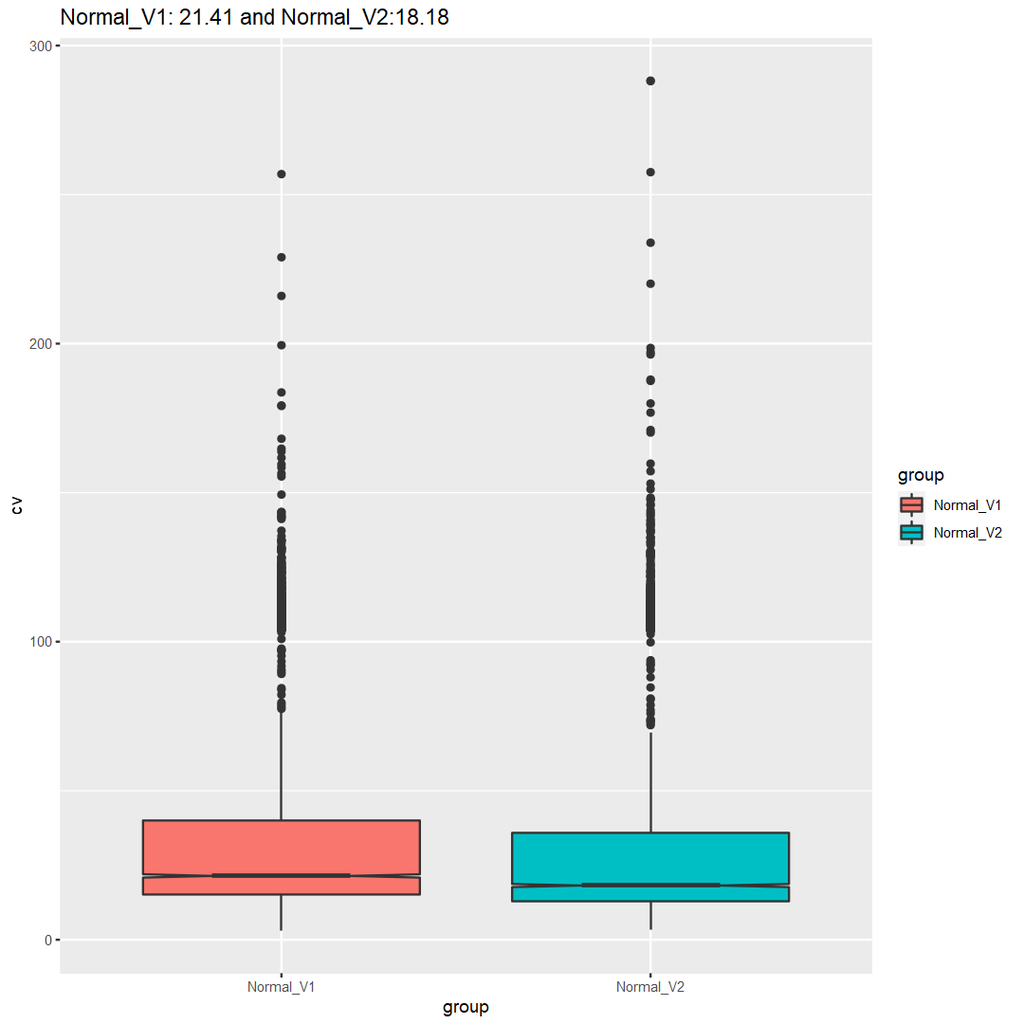

```r
# traditional boxplots
ggplot(cv, aes(x = group, y = cv, fill = group)) +
  geom_boxplot(notch = TRUE) +
  ggtitle("Normal_V1: 21.41 and Normal_V2:18.18")
```

## Limma batch correction 100% valid values dataset

- The data was filtered to remove all missing values.
- log2-transformed data was used to perform limma:removeBatchEffect().

```r
# read the dataframe containing quantitative information for 28 samples and two pools.
protein_data1 = read.delim(file = 'abundance_protein_MD_for_BC.tsv', header=TRUE, row.names = 1)
View(protein_data1)
```

A data.frame: 5038 × 30

|  | Normal_1001.1 <dbl> | Normal_1002.1 <dbl> | Normal_1003.1 <dbl> | Normal_1004.1 <dbl> | Normal_1213.1 <dbl> | Normal_1214.1 <dbl> | Normal_1215.1 <dbl> | Normal_1001.2 <dbl> | Normal_1002.2 <dbl> | Normal_1003.2 <dbl> | ⋯ | Normal_1563.1 <dbl> | Normal_1580.1 <dbl> | Normal_1401.2 <dbl> | Normal_1402.2 <dbl> | Normal_1503.2 <dbl> | Normal_1518.2 <dbl> | Normal_1539.2 <dbl> | Normal_1563.2 <dbl> | Normal_1580.2 <dbl> | pool2.2 <dbl> |
| --- | --- | --- | --- | --- | --- | --- | --- | --- | --- | --- | --- | --- | --- | --- | --- | --- | --- | --- | --- | --- | --- |
| A0A024RBG1 | 19.10729 | 18.93056 | 18.75975 | 19.04012 | 18.95292 | 19.02369 | 19.13319 | 18.98508 | 19.34557 | 19.06943 | ⋯ | 18.65230 | 19.28762 | 19.41907 | 19.41023 | 19.50324 | 19.52242 | 19.41820 | 19.30920 | 19.49883 | 18.61972 |
| A0A075B6H7 | 20.25408 | 20.55836 | 19.67400 | 20.52577 | 20.28805 | 19.27782 | 19.86908 | 19.83209 | 19.74524 | 19.70637 | ⋯ | 19.67955 | 19.87374 | 19.61395 | 19.73145 | 19.54272 | 19.71117 | 19.70122 | 20.62366 | 19.96669 | 20.33888 |
| A0A075B6H9 | 18.81861 | 18.38606 | 18.27379 | 18.44279 | 19.43132 | 18.39013 | 18.45889 | 18.28925 | 18.07239 | 18.79552 | ⋯ | 18.79314 | 18.71214 | 18.98489 | 18.98973 | 19.00867 | 19.02255 | 18.38576 | 19.71191 | 19.21278 | 19.41812 |
| A0A075B6I0 | 21.04551 | 20.85883 | 21.21782 | 21.13352 | 21.52227 | 20.41224 | 18.87665 | 20.76149 | 20.60502 | 21.23022 | ⋯ | 20.53920 | 21.20300 | 20.01407 | 20.01447 | 18.67214 | 20.11035 | 20.88403 | 20.95726 | 20.98188 | 20.55474 |
| A0A075B6I1 | 18.30156 | 18.34703 | 17.24402 | 18.08645 | 18.29290 | 18.04392 | 17.95454 | 18.30758 | 17.91273 | 17.93311 | ⋯ | 18.58527 | 17.64619 | 17.38030 | 18.12753 | 17.06937 | 17.63370 | 17.49546 | 18.27339 | 17.58687 | 19.04983 |
| A0A075B6I9 | 18.89451 | 17.80736 | 18.55068 | 19.66588 | 18.60871 | 18.18874 | 18.75686 | 18.40430 | 18.07071 | 18.54704 | ⋯ | 19.21486 | 18.63336 | 18.37673 | 19.03608 | 18.89370 | 19.05337 | 18.67482 | 19.10487 | 18.61103 | 18.45454 |
| A0A075B6K2 | 16.34202 | 16.93921 | 16.09095 | 16.30237 | 17.45433 | 15.55511 | 16.03932 | 16.08215 | 16.00125 | 16.34512 | ⋯ | 16.85056 | 16.39904 | 14.97208 | 15.88439 | 15.91926 | 15.97875 | 16.87103 | 16.95595 | 16.08826 | 15.81093 |
| A0A075B6Q5 | 20.21058 | 21.89750 | 20.04218 | 21.28238 | 21.90751 | 20.22634 | 20.69074 | 19.65869 | 20.46133 | 19.94103 | ⋯ | 21.69462 | 20.94843 | 21.31234 | 20.72980 | 20.87101 | 20.98573 | 21.04444 | 21.88829 | 21.03830 | 21.01125 |
| A0A075B6R2 | 18.99457 | 20.21483 | 18.61230 | 18.53040 | 19.96298 | 18.44566 | 18.53730 | 18.19216 | 18.69451 | 18.43047 | ⋯ | NA | NA | NA | NA | NA | NA | NA | NA | NA | NA |
| A0A075B6R9 | 21.67625 | 21.13914 | 21.64080 | 21.66028 | 21.93752 | 21.36905 | 21.78372 | 21.67483 | 21.03784 | 21.59284 | ⋯ | 21.40566 | 21.56276 | 20.79035 | 21.30402 | 21.35785 | 21.23595 | 21.03499 | 21.38083 | 21.58701 | 21.43731 |
| A0A075B6S2 | 22.16558 | 22.20111 | 21.94692 | 22.37609 | 22.66327 | 20.91219 | 21.82715 | 21.90494 | 21.86472 | 21.98125 | ⋯ | 22.13066 | 22.69271 | 22.10978 | 22.73870 | 22.02989 | 22.16625 | 22.44689 | 23.05138 | 22.76047 | 21.69301 |
| A0A075B6S6 | 21.27713 | 21.02433 | 20.30117 | 21.07887 | 21.22831 | 20.47653 | 20.50732 | 20.80696 | 20.12834 | 20.52901 | ⋯ | 21.17426 | 21.21245 | 20.19803 | 21.34619 | 20.70314 | 20.77016 | 21.48479 | 21.22119 | 21.02828 | 20.78416 |
| A0A087WSY4 | 17.95358 | 18.69302 | 17.82066 | 18.42072 | 18.73492 | 18.12484 | 18.20520 | 17.87935 | 18.03847 | 19.72441 | ⋯ | 18.17613 | 17.33193 | 17.51736 | 17.20742 | 18.38590 | 17.30763 | 17.90369 | 17.84443 | 17.07238 | 19.00147 |
| A0A0A0MRZ8 | 24.64817 | 25.12419 | 23.95696 | 24.63599 | 24.90399 | 23.61108 | 24.02051 | 24.30546 | 24.18170 | 24.12985 | ⋯ | 23.18494 | 23.98315 | 23.94693 | 23.94868 | 23.87945 | 23.78396 | 23.84695 | 24.53787 | 24.11897 | 24.78575 |
| A0A0A0MT89 | 15.05551 | 15.36934 | 14.90595 | 14.40346 | 15.21175 | 14.25674 | 14.72910 | 14.70544 | 14.42308 | 14.13313 | ⋯ | NA | NA | NA | NA | NA | NA | NA | NA | NA | NA |
| A0A0B4J1U7 | 20.87437 | 20.35941 | 19.72130 | 20.41952 | 20.89354 | 19.60651 | 19.56366 | 20.02867 | 19.56058 | 19.92395 | ⋯ | 21.41161 | 21.07411 | 20.95744 | 21.46303 | 20.98902 | 21.19576 | 20.94446 | 21.39239 | 21.02991 | 21.27249 |
| A0A0B4J2D5 | 23.01174 | 22.98249 | 23.30181 | 22.87594 | 21.98828 | 22.54340 | 23.05475 | 23.37922 | 23.33253 | 23.03325 | ⋯ | 21.89863 | 22.82181 | 23.07762 | 22.89125 | 23.26045 | 22.89800 | 22.79875 | 22.69709 | 22.80626 | 22.23559 |
| A0A0B4J2D9 | 22.10985 | 23.24069 | 21.58920 | 21.86500 | 22.96165 | 21.27829 | 21.63739 | 21.65621 | 21.26392 | 21.76142 | ⋯ | 22.23809 | 21.93908 | 21.09045 | 21.36579 | 21.52493 | 21.95444 | 21.72217 | 22.84822 | 21.82455 | 22.60748 |
| A0A0C4DH25 | 24.46469 | 24.78983 | 24.13961 | 24.63727 | 25.44708 | 23.84532 | 24.34147 | 24.02391 | 24.31027 | 24.30480 | ⋯ | 24.05612 | 24.32527 | 23.85237 | 24.08703 | 23.95233 | 23.95595 | 24.07079 | 24.83572 | 24.28190 | 24.89868 |
| A0A0C4DH29 | 22.39125 | 23.58732 | 22.24646 | 22.51377 | 24.33322 | 21.75016 | 22.78508 | 21.76171 | 22.02487 | 21.96067 | ⋯ | 23.51752 | 23.00627 | 22.00493 | 22.64465 | 22.31321 | 23.03550 | 23.39118 | 23.64518 | 22.96108 | 22.24535 |
| A0A0C4DH34 | 18.91602 | 19.13513 | 18.90091 | 19.31975 | 19.66867 | 19.08920 | 19.21469 | 19.09557 | 19.05376 | 19.11793 | ⋯ | 20.10834 | 19.86602 | 19.63104 | 19.53898 | 19.96946 | 19.81332 | 19.80906 | 20.46610 | 20.00636 | 19.60655 |
| A0A0C4DH38 | 18.28505 | 18.97375 | 17.88037 | 18.07163 | 19.06639 | 18.36493 | 18.12558 | 17.89720 | 18.22592 | 18.01638 | ⋯ | 19.52507 | 18.67380 | 18.10519 | 18.02821 | 17.83718 | 18.26057 | 18.59311 | 19.61079 | 18.58372 | 17.33610 |
| A0A0C4DH39 | 17.69888 | 18.52168 | 17.63829 | 17.64159 | 19.75691 | 17.81002 | 18.04141 | 17.35366 | 17.63927 | 17.34491 | ⋯ | NA | NA | NA | NA | NA | NA | NA | NA | NA | NA |
| A0A0C4DH41 | 21.17535 | 21.26923 | 21.22757 | 21.09698 | 21.45779 | 21.21636 | 21.42627 | 20.86131 | 21.01027 | 21.22706 | ⋯ | 22.05381 | 21.49426 | 21.35026 | 21.35154 | 21.34195 | 21.24298 | 21.31962 | 22.26964 | 21.55581 | 21.08101 |
| A0A0J9YXX1 | 21.50795 | 19.12232 | 20.42988 | 20.64849 | 22.23296 | 20.95483 | 20.45880 | 20.84803 | 19.42291 | 20.36829 | ⋯ | 22.60799 | 21.28312 | 21.71046 | 20.38577 | 20.07833 | 19.36744 | 19.67968 | 22.90346 | 21.30527 | 21.04921 |
| A0AV96 | 20.52132 | 20.50786 | 20.79482 | 20.82343 | 20.71197 | 20.96718 | 20.84824 | 20.53246 | 20.65962 | 20.69012 | ⋯ | 21.09780 | 20.94723 | 20.48057 | 21.04312 | 21.14524 | 20.91864 | 20.84504 | 20.95244 | 20.97389 | 20.53022 |
| A0AVT1 | 20.33420 | 20.17463 | 20.57539 | 20.34601 | 20.50655 | 20.33214 | 20.40575 | 20.14088 | 20.37959 | 20.29638 | ⋯ | 19.93716 | 19.90999 | 20.07429 | 20.08104 | 20.07056 | 19.99006 | 20.06354 | 20.17503 | 20.08017 | 20.00473 |
| A0FGR8 | 19.55595 | 19.71647 | 19.75821 | 19.84742 | 19.95036 | 19.95303 | 19.80048 | 19.45258 | 19.78825 | 19.72489 | ⋯ | 20.74756 | 20.45248 | 20.31989 | 20.63157 | 20.38777 | 20.45074 | 20.67627 | 20.67548 | 20.65075 | 20.08843 |
| A0M8Q6 | 16.87204 | 17.53905 | 19.00941 | 19.55167 | 20.59653 | 17.71720 | 19.88746 | 17.41868 | 16.82197 | 19.10571 | ⋯ | 17.74285 | 19.59199 | 19.49741 | 18.16945 | 19.53035 | 19.03052 | 20.77068 | 18.69059 | 19.27914 | 17.70422 |
| A0MZ66 | 19.82752 | 19.97038 | 19.68577 | 19.75962 | 19.55647 | 19.99367 | 19.81468 | 19.73325 | 20.05973 | 19.90660 | ⋯ | 20.23671 | 20.07992 | 20.01620 | 20.02900 | 20.01935 | 20.06512 | 19.85520 | 19.82755 | 19.81562 | 19.99385 |
| ⋮ | ⋮ | ⋮ | ⋮ | ⋮ | ⋮ | ⋮ | ⋮ | ⋮ | ⋮ | ⋮ | ⋱ | ⋮ | ⋮ | ⋮ | ⋮ | ⋮ | ⋮ | ⋮ | ⋮ | ⋮ | ⋮ |
| Q9Y6D5 | 21.20773 | 20.97099 | 21.42630 | 21.42907 | 21.65775 | 21.46460 | 21.42522 | 21.30132 | 21.55448 | 21.34592 | ⋯ | 21.17767 | 21.22620 | 21.20104 | 21.50290 | 21.46103 | 21.39233 | 21.30543 | 21.54639 | 21.87900 | 21.41501 |
| Q9Y6D6 | 18.71748 | 18.72065 | 18.85499 | 18.76200 | 18.86336 | 19.21693 | 19.00175 | 18.87944 | 18.80659 | 18.97164 | ⋯ | 18.73055 | 18.78563 | 19.00564 | 19.26906 | 18.86166 | 19.03087 | 18.67813 | 20.16081 | 19.67414 | 19.72285 |
| Q9Y6D9 | NA | NA | NA | NA | NA | NA | NA | NA | NA | NA | ⋯ | 15.72143 | 15.00236 | 14.86004 | 14.92818 | 14.78145 | 14.90063 | 15.36186 | 14.88730 | 14.84584 | 14.96592 |
| Q9Y6E0 | 20.74484 | 20.90202 | 21.00903 | 20.91640 | 20.69455 | 21.05650 | 21.12342 | 20.91836 | 21.02610 | 21.07848 | ⋯ | 21.17565 | 21.01516 | 20.89344 | 20.86318 | 21.10690 | 21.12099 | 20.78113 | 20.86664 | 21.05363 | 20.71945 |
| Q9Y6E2 | 20.71963 | 20.77818 | 20.74746 | 20.76604 | 20.90492 | 21.03184 | 20.85875 | 20.80378 | 20.63050 | 20.62103 | ⋯ | 20.56054 | 20.69742 | 20.66422 | 20.93872 | 20.65587 | 20.69224 | 20.55511 | 20.73424 | 20.92282 | 20.81849 |
| Q9Y6F6 | 17.14659 | 17.48421 | 17.00705 | 17.04270 | 17.14736 | 17.24780 | 16.92473 | 17.35100 | 17.35393 | 17.40080 | ⋯ | 17.30976 | 17.15447 | 16.91396 | 16.73703 | 16.87259 | 16.99934 | 17.13186 | 17.28062 | 16.51341 | 17.79593 |
| Q9Y6G3 | 17.55817 | 17.51817 | 16.93807 | 17.02605 | 16.83055 | 17.18716 | 17.25341 | 17.44318 | 16.90074 | 16.98814 | ⋯ | 16.45338 | 16.29347 | 16.42972 | 16.12240 | 16.17686 | 16.73409 | 16.23742 | 16.05983 | 16.17576 | 16.95178 |
| Q9Y6G5 | 17.04938 | 16.99655 | 17.38609 | 17.24092 | 17.05548 | 17.52320 | 17.44082 | 17.50554 | 17.28796 | 17.51705 | ⋯ | NA | NA | NA | NA | NA | NA | NA | NA | NA | NA |
| Q9Y6G9 | 21.36916 | 21.25557 | 21.65708 | 21.35691 | 21.25349 | 21.08338 | 21.31366 | 21.44651 | 21.31281 | 21.33384 | ⋯ | 20.87762 | 20.63762 | 20.79972 | 20.70109 | 20.54846 | 20.51935 | 20.97035 | 20.52456 | 20.46178 | 20.91895 |
| Q9Y6H1 | 18.86866 | 18.99644 | 18.92038 | 18.81393 | 18.83315 | 19.15126 | 19.18730 | 19.02193 | 18.89898 | 18.94968 | ⋯ | 19.46499 | 19.25478 | 18.98009 | 18.88995 | 19.02274 | 19.14308 | 19.17358 | 18.64349 | 18.65818 | 18.91238 |
| Q9Y6I3 | 19.21719 | 19.44748 | 19.03692 | 19.15877 | 18.77283 | 19.35303 | 19.22783 | 19.36745 | 19.23503 | 19.38492 | ⋯ | 19.28004 | 19.34875 | 19.26540 | 19.10710 | 19.31546 | 19.34015 | 19.46423 | 19.18774 | 19.27582 | 19.49525 |
| Q9Y6I4 | 15.80173 | 16.25925 | 15.59568 | 16.24511 | 16.54417 | 17.26850 | 17.02154 | 15.75262 | 15.65370 | 15.81948 | ⋯ | NA | NA | NA | NA | NA | NA | NA | NA | NA | NA |
| Q9Y6I9 | 17.64710 | 17.73991 | 17.54070 | 17.61267 | 18.14555 | 18.12163 | 18.03710 | 17.58271 | 17.45253 | 17.50233 | ⋯ | 16.64650 | 16.42047 | 16.77180 | 16.42307 | 16.53413 | 16.54260 | 16.87644 | 16.66180 | 16.31420 | 17.66647 |
| Q9Y6K0 | NA | NA | NA | NA | NA | NA | NA | NA | NA | NA | ⋯ | 13.97289 | 14.08471 | 14.24131 | 14.65805 | 14.38106 | 14.39408 | 14.08793 | 14.97041 | 14.77524 | 14.81925 |
| Q9Y6K5 | 17.08089 | 16.51364 | 17.37825 | 17.07144 | 17.34273 | 16.03025 | 16.78090 | 16.60536 | 17.00463 | 16.78472 | ⋯ | 17.56552 | 17.04409 | 17.13233 | 17.71396 | 17.35498 | 17.18230 | 17.32901 | 17.27435 | 17.32992 | 17.39344 |
| Q9Y6K9 | 20.05360 | 20.06784 | 19.60249 | 19.98702 | 20.02805 | 20.07945 | 19.97097 | 19.82796 | 19.67600 | 19.68429 | ⋯ | 20.08513 | 19.73932 | 19.96802 | 19.45794 | 19.48075 | 19.72667 | 19.93205 | 19.61186 | 19.61378 | 20.22526 |
| Q9Y6M1 | 19.31669 | 19.47430 | 19.61641 | 19.55884 | 19.46177 | 19.62078 | 19.87190 | 19.63876 | 19.83261 | 19.76411 | ⋯ | 19.03286 | 19.27103 | 19.18964 | 19.41970 | 19.53655 | 19.32438 | 19.33256 | 19.54784 | 19.45404 | 19.46575 |
| Q9Y6M7 | NA | NA | NA | NA | NA | NA | NA | NA | NA | NA | ⋯ | 16.75382 | 16.18759 | 16.34914 | 16.19551 | 16.32016 | 16.21741 | 16.09454 | 16.33111 | 16.38012 | 17.13078 |
| Q9Y6M9 | 19.76405 | 19.64423 | 20.21207 | 19.79748 | 19.28834 | 19.83518 | 20.00241 | 20.12370 | 20.28761 | 20.21508 | ⋯ | 19.62633 | 19.78040 | 19.61120 | 19.51773 | 19.63222 | 19.95785 | 19.46109 | 19.48834 | 19.69822 | 19.51811 |
| Q9Y6N5 | 22.28766 | 22.46486 | 23.02399 | 22.75338 | 22.88528 | 22.55794 | 22.50176 | 22.30686 | 22.76248 | 22.97723 | ⋯ | 22.42776 | 22.26780 | 22.19500 | 22.29231 | 22.81774 | 22.60808 | 21.98143 | 22.71603 | 22.71620 | 22.45126 |
| Q9Y6N9 | 20.60440 | 20.57426 | 21.00009 | 20.66885 | 20.80293 | 20.99714 | 20.86505 | 20.69760 | 21.14553 | 21.08008 | ⋯ | 20.48720 | 20.25707 | 19.50800 | 20.30347 | 20.30560 | 20.21244 | 19.72764 | 20.18777 | 20.47900 | 20.69388 |
| Q9Y6Q5 | 19.91859 | 19.54692 | 20.23303 | 19.64463 | 20.54585 | 19.91449 | 19.80626 | 19.59582 | 20.21027 | 19.99992 | ⋯ | 19.85863 | 19.79454 | 19.68047 | 20.04778 | 20.25257 | 19.94763 | 19.79851 | 20.17126 | 20.34330 | 19.76706 |
| Q9Y6R1 | 19.55153 | 19.33651 | 20.34411 | 20.22528 | 19.64817 | 20.24813 | 20.00165 | 19.71159 | 20.44379 | 20.23980 | ⋯ | 20.16059 | 19.84937 | 19.38738 | 20.07981 | 20.13496 | 19.95500 | 19.42176 | 20.05306 | 20.35048 | 19.83455 |
| Q9Y6R7 | 25.40871 | 25.30277 | 25.46997 | 25.29925 | 24.53102 | 25.70146 | 25.55998 | 25.73942 | 25.66135 | 25.84020 | ⋯ | 25.46626 | 25.24035 | 25.23916 | 25.44383 | 25.72621 | 25.98843 | 25.25364 | 25.89658 | 25.97578 | 25.53225 |
| Q9Y6U3 | 18.99679 | 19.05387 | 19.62409 | 19.65874 | 18.91958 | 19.97073 | 19.75049 | 19.43657 | 19.71599 | 19.80116 | ⋯ | 19.69884 | 19.58449 | 19.37005 | 19.83270 | 20.07554 | 19.92841 | 19.38309 | 20.04107 | 19.86220 | 19.27445 |
| Q9Y6W3 | 17.52463 | 17.47187 | 17.59165 | 17.48256 | 17.50615 | 17.69035 | 17.54331 | 17.35312 | 17.50615 | 17.53756 | ⋯ | 17.61428 | 17.38152 | 17.33741 | 17.56930 | 17.41284 | 17.67423 | 17.50053 | 17.55431 | 17.56284 | 17.91831 |
| Q9Y6W5 | 21.21071 | 21.11045 | 20.85918 | 21.13222 | 20.79297 | 20.90674 | 21.02243 | 21.23841 | 20.92517 | 21.00970 | ⋯ | 20.88972 | 20.99460 | 21.17575 | 20.91181 | 20.81279 | 21.12921 | 21.05940 | 20.85664 | 20.82513 | 21.11945 |
| Q9Y6X5 | 13.25572 | 13.27381 | 13.91555 | 12.95925 | 12.60425 | 13.07806 | 12.97611 | 13.47764 | 13.68783 | 13.71896 | ⋯ | 13.47177 | 13.48412 | 13.68349 | 13.46210 | 13.50164 | 13.19322 | 12.77757 | 13.86895 | 13.60417 | 13.72131 |
| Q9Y6X9 | 19.43768 | 19.35532 | 19.32135 | 19.49328 | 19.41723 | 20.07054 | 19.54930 | 19.30696 | 19.20378 | 19.35507 | ⋯ | NA | NA | NA | NA | NA | NA | NA | NA | NA | NA |
| Q9Y6Y8 | 19.80723 | 19.82670 | 19.96133 | 19.90231 | 20.16998 | 19.87359 | 20.00960 | 19.71275 | 20.06614 | 19.92633 | ⋯ | 19.14360 | 19.24322 | 19.71036 | 19.90112 | 20.02608 | 19.27973 | 19.38104 | 19.87393 | 19.78657 | 19.81279 |

```r
#Remove rows with any NA value: data filtering based on 100% valid values
protein_data1 <- protein_data1[complete.cases(protein_data1),]
View(protein_data1)
```

A data.frame: 3994 × 30

|  | Normal_1001.1 <dbl> | Normal_1002.1 <dbl> | Normal_1003.1 <dbl> | Normal_1004.1 <dbl> | Normal_1213.1 <dbl> | Normal_1214.1 <dbl> | Normal_1215.1 <dbl> | Normal_1001.2 <dbl> | Normal_1002.2 <dbl> | Normal_1003.2 <dbl> | ⋯ | Normal_1563.1 <dbl> | Normal_1580.1 <dbl> | Normal_1401.2 <dbl> | Normal_1402.2 <dbl> | Normal_1503.2 <dbl> | Normal_1518.2 <dbl> | Normal_1539.2 <dbl> | Normal_1563.2 <dbl> | Normal_1580.2 <dbl> | pool2.2 <dbl> |
| --- | --- | --- | --- | --- | --- | --- | --- | --- | --- | --- | --- | --- | --- | --- | --- | --- | --- | --- | --- | --- | --- |
| A0A024RBG1 | 19.10729 | 18.93056 | 18.75975 | 19.04012 | 18.95292 | 19.02369 | 19.13319 | 18.98508 | 19.34557 | 19.06943 | ⋯ | 18.65230 | 19.28762 | 19.41907 | 19.41023 | 19.50324 | 19.52242 | 19.41820 | 19.30920 | 19.49883 | 18.61972 |
| A0A075B6H7 | 20.25408 | 20.55836 | 19.67400 | 20.52577 | 20.28805 | 19.27782 | 19.86908 | 19.83209 | 19.74524 | 19.70637 | ⋯ | 19.67955 | 19.87374 | 19.61395 | 19.73145 | 19.54272 | 19.71117 | 19.70122 | 20.62366 | 19.96669 | 20.33888 |
| A0A075B6H9 | 18.81861 | 18.38606 | 18.27379 | 18.44279 | 19.43132 | 18.39013 | 18.45889 | 18.28925 | 18.07239 | 18.79552 | ⋯ | 18.79314 | 18.71214 | 18.98489 | 18.98973 | 19.00867 | 19.02255 | 18.38576 | 19.71191 | 19.21278 | 19.41812 |
| A0A075B6I0 | 21.04551 | 20.85883 | 21.21782 | 21.13352 | 21.52227 | 20.41224 | 18.87665 | 20.76149 | 20.60502 | 21.23022 | ⋯ | 20.53920 | 21.20300 | 20.01407 | 20.01447 | 18.67214 | 20.11035 | 20.88403 | 20.95726 | 20.98188 | 20.55474 |
| A0A075B6I1 | 18.30156 | 18.34703 | 17.24402 | 18.08645 | 18.29290 | 18.04392 | 17.95454 | 18.30758 | 17.91273 | 17.93311 | ⋯ | 18.58527 | 17.64619 | 17.38030 | 18.12753 | 17.06937 | 17.63370 | 17.49546 | 18.27339 | 17.58687 | 19.04983 |
| A0A075B6I9 | 18.89451 | 17.80736 | 18.55068 | 19.66588 | 18.60871 | 18.18874 | 18.75686 | 18.40430 | 18.07071 | 18.54704 | ⋯ | 19.21486 | 18.63336 | 18.37673 | 19.03608 | 18.89370 | 19.05337 | 18.67482 | 19.10487 | 18.61103 | 18.45454 |
| A0A075B6K2 | 16.34202 | 16.93921 | 16.09095 | 16.30237 | 17.45433 | 15.55511 | 16.03932 | 16.08215 | 16.00125 | 16.34512 | ⋯ | 16.85056 | 16.39904 | 14.97208 | 15.88439 | 15.91926 | 15.97875 | 16.87103 | 16.95595 | 16.08826 | 15.81093 |
| A0A075B6Q5 | 20.21058 | 21.89750 | 20.04218 | 21.28238 | 21.90751 | 20.22634 | 20.69074 | 19.65869 | 20.46133 | 19.94103 | ⋯ | 21.69462 | 20.94843 | 21.31234 | 20.72980 | 20.87101 | 20.98573 | 21.04444 | 21.88829 | 21.03830 | 21.01125 |
| A0A075B6R9 | 21.67625 | 21.13914 | 21.64080 | 21.66028 | 21.93752 | 21.36905 | 21.78372 | 21.67483 | 21.03784 | 21.59284 | ⋯ | 21.40566 | 21.56276 | 20.79035 | 21.30402 | 21.35785 | 21.23595 | 21.03499 | 21.38083 | 21.58701 | 21.43731 |
| A0A075B6S2 | 22.16558 | 22.20111 | 21.94692 | 22.37609 | 22.66327 | 20.91219 | 21.82715 | 21.90494 | 21.86472 | 21.98125 | ⋯ | 22.13066 | 22.69271 | 22.10978 | 22.73870 | 22.02989 | 22.16625 | 22.44689 | 23.05138 | 22.76047 | 21.69301 |
| A0A075B6S6 | 21.27713 | 21.02433 | 20.30117 | 21.07887 | 21.22831 | 20.47653 | 20.50732 | 20.80696 | 20.12834 | 20.52901 | ⋯ | 21.17426 | 21.21245 | 20.19803 | 21.34619 | 20.70314 | 20.77016 | 21.48479 | 21.22119 | 21.02828 | 20.78416 |
| A0A087WSY4 | 17.95358 | 18.69302 | 17.82066 | 18.42072 | 18.73492 | 18.12484 | 18.20520 | 17.87935 | 18.03847 | 19.72441 | ⋯ | 18.17613 | 17.33193 | 17.51736 | 17.20742 | 18.38590 | 17.30763 | 17.90369 | 17.84443 | 17.07238 | 19.00147 |
| A0A0A0MRZ8 | 24.64817 | 25.12419 | 23.95696 | 24.63599 | 24.90399 | 23.61108 | 24.02051 | 24.30546 | 24.18170 | 24.12985 | ⋯ | 23.18494 | 23.98315 | 23.94693 | 23.94868 | 23.87945 | 23.78396 | 23.84695 | 24.53787 | 24.11897 | 24.78575 |
| A0A0B4J1U7 | 20.87437 | 20.35941 | 19.72130 | 20.41952 | 20.89354 | 19.60651 | 19.56366 | 20.02867 | 19.56058 | 19.92395 | ⋯ | 21.41161 | 21.07411 | 20.95744 | 21.46303 | 20.98902 | 21.19576 | 20.94446 | 21.39239 | 21.02991 | 21.27249 |
| A0A0B4J2D5 | 23.01174 | 22.98249 | 23.30181 | 22.87594 | 21.98828 | 22.54340 | 23.05475 | 23.37922 | 23.33253 | 23.03325 | ⋯ | 21.89863 | 22.82181 | 23.07762 | 22.89125 | 23.26045 | 22.89800 | 22.79875 | 22.69709 | 22.80626 | 22.23559 |
| A0A0B4J2D9 | 22.10985 | 23.24069 | 21.58920 | 21.86500 | 22.96165 | 21.27829 | 21.63739 | 21.65621 | 21.26392 | 21.76142 | ⋯ | 22.23809 | 21.93908 | 21.09045 | 21.36579 | 21.52493 | 21.95444 | 21.72217 | 22.84822 | 21.82455 | 22.60748 |
| A0A0C4DH25 | 24.46469 | 24.78983 | 24.13961 | 24.63727 | 25.44708 | 23.84532 | 24.34147 | 24.02391 | 24.31027 | 24.30480 | ⋯ | 24.05612 | 24.32527 | 23.85237 | 24.08703 | 23.95233 | 23.95595 | 24.07079 | 24.83572 | 24.28190 | 24.89868 |
| A0A0C4DH29 | 22.39125 | 23.58732 | 22.24646 | 22.51377 | 24.33322 | 21.75016 | 22.78508 | 21.76171 | 22.02487 | 21.96067 | ⋯ | 23.51752 | 23.00627 | 22.00493 | 22.64465 | 22.31321 | 23.03550 | 23.39118 | 23.64518 | 22.96108 | 22.24535 |
| A0A0C4DH34 | 18.91602 | 19.13513 | 18.90091 | 19.31975 | 19.66867 | 19.08920 | 19.21469 | 19.09557 | 19.05376 | 19.11793 | ⋯ | 20.10834 | 19.86602 | 19.63104 | 19.53898 | 19.96946 | 19.81332 | 19.80906 | 20.46610 | 20.00636 | 19.60655 |
| A0A0C4DH38 | 18.28505 | 18.97375 | 17.88037 | 18.07163 | 19.06639 | 18.36493 | 18.12558 | 17.89720 | 18.22592 | 18.01638 | ⋯ | 19.52507 | 18.67380 | 18.10519 | 18.02821 | 17.83718 | 18.26057 | 18.59311 | 19.61079 | 18.58372 | 17.33610 |
| A0A0C4DH41 | 21.17535 | 21.26923 | 21.22757 | 21.09698 | 21.45779 | 21.21636 | 21.42627 | 20.86131 | 21.01027 | 21.22706 | ⋯ | 22.05381 | 21.49426 | 21.35026 | 21.35154 | 21.34195 | 21.24298 | 21.31962 | 22.26964 | 21.55581 | 21.08101 |
| A0A0J9YXX1 | 21.50795 | 19.12232 | 20.42988 | 20.64849 | 22.23296 | 20.95483 | 20.45880 | 20.84803 | 19.42291 | 20.36829 | ⋯ | 22.60799 | 21.28312 | 21.71046 | 20.38577 | 20.07833 | 19.36744 | 19.67968 | 22.90346 | 21.30527 | 21.04921 |
| A0AV96 | 20.52132 | 20.50786 | 20.79482 | 20.82343 | 20.71197 | 20.96718 | 20.84824 | 20.53246 | 20.65962 | 20.69012 | ⋯ | 21.09780 | 20.94723 | 20.48057 | 21.04312 | 21.14524 | 20.91864 | 20.84504 | 20.95244 | 20.97389 | 20.53022 |
| A0AVT1 | 20.33420 | 20.17463 | 20.57539 | 20.34601 | 20.50655 | 20.33214 | 20.40575 | 20.14088 | 20.37959 | 20.29638 | ⋯ | 19.93716 | 19.90999 | 20.07429 | 20.08104 | 20.07056 | 19.99006 | 20.06354 | 20.17503 | 20.08017 | 20.00473 |
| A0FGR8 | 19.55595 | 19.71647 | 19.75821 | 19.84742 | 19.95036 | 19.95303 | 19.80048 | 19.45258 | 19.78825 | 19.72489 | ⋯ | 20.74756 | 20.45248 | 20.31989 | 20.63157 | 20.38777 | 20.45074 | 20.67627 | 20.67548 | 20.65075 | 20.08843 |
| A0M8Q6 | 16.87204 | 17.53905 | 19.00941 | 19.55167 | 20.59653 | 17.71720 | 19.88746 | 17.41868 | 16.82197 | 19.10571 | ⋯ | 17.74285 | 19.59199 | 19.49741 | 18.16945 | 19.53035 | 19.03052 | 20.77068 | 18.69059 | 19.27914 | 17.70422 |
| A0MZ66 | 19.82752 | 19.97038 | 19.68577 | 19.75962 | 19.55647 | 19.99367 | 19.81468 | 19.73325 | 20.05973 | 19.90660 | ⋯ | 20.23671 | 20.07992 | 20.01620 | 20.02900 | 20.01935 | 20.06512 | 19.85520 | 19.82755 | 19.81562 | 19.99385 |
| A1A5D9 | 17.71673 | 17.88242 | 17.83824 | 17.87408 | 17.72229 | 18.06549 | 18.02573 | 17.93635 | 17.99536 | 18.06908 | ⋯ | 18.45042 | 17.90030 | 17.83482 | 17.71187 | 18.08607 | 18.15038 | 17.28132 | 17.79732 | 17.55629 | 18.25575 |
| A1L0T0 | 20.00124 | 20.35395 | 21.19680 | 20.69481 | 19.93901 | 20.82567 | 20.73525 | 19.97662 | 21.11360 | 20.66719 | ⋯ | 19.76038 | 19.94975 | 19.99318 | 20.64361 | 20.61442 | 20.47715 | 19.83182 | 20.11600 | 20.85364 | 19.79684 |
| A1X283 | 18.67657 | 18.92368 | 18.58476 | 18.57779 | 19.61970 | 20.03354 | 19.33390 | 18.13813 | 18.08946 | 18.30930 | ⋯ | 19.25130 | 18.90396 | 19.05582 | 18.73874 | 18.72262 | 18.83125 | 19.49872 | 18.83060 | 18.75147 | 19.80153 |
| ⋮ | ⋮ | ⋮ | ⋮ | ⋮ | ⋮ | ⋮ | ⋮ | ⋮ | ⋮ | ⋮ | ⋱ | ⋮ | ⋮ | ⋮ | ⋮ | ⋮ | ⋮ | ⋮ | ⋮ | ⋮ | ⋮ |
| Q9Y680 | 17.61761 | 17.73899 | 17.30532 | 17.37220 | 17.85272 | 17.82540 | 17.53343 | 17.65299 | 17.29028 | 17.44535 | ⋯ | 19.27176 | 18.66196 | 19.06141 | 18.30553 | 18.56760 | 18.66576 | 18.65223 | 18.22680 | 18.14211 | 17.99140 |
| Q9Y696 | 20.27465 | 20.54312 | 20.05875 | 20.25695 | 20.48295 | 20.37748 | 20.35378 | 20.20692 | 20.30853 | 20.05636 | ⋯ | 20.74977 | 20.21896 | 20.55667 | 20.15530 | 20.10996 | 20.32732 | 20.49528 | 20.26111 | 20.03377 | 20.50868 |
| Q9Y6A4 | 13.59272 | 13.78221 | 13.58837 | 13.61842 | 13.55328 | 13.49469 | 13.44503 | 13.62156 | 13.69828 | 13.73758 | ⋯ | 13.45765 | 13.03636 | 13.36049 | 13.25607 | 13.40109 | 13.57694 | 13.29788 | 13.47859 | 13.26648 | 13.74595 |
| Q9Y6B6 | 20.74380 | 20.59789 | 20.79757 | 20.71709 | 20.55652 | 20.61167 | 20.69140 | 20.47308 | 20.49264 | 20.09961 | ⋯ | 20.51207 | 20.77058 | 20.56200 | 20.69582 | 20.82452 | 20.74231 | 20.59058 | 20.68924 | 20.75041 | 20.59876 |
| Q9Y6C2 | 22.34512 | 22.12364 | 22.61949 | 22.40268 | 22.98740 | 22.99977 | 22.92480 | 22.37560 | 22.65099 | 22.21875 | ⋯ | 22.61403 | 22.40144 | 22.41217 | 22.79932 | 22.88577 | 22.44136 | 22.55168 | 22.72669 | 22.94295 | 23.37157 |
| Q9Y6C9 | 16.78865 | 16.59657 | 17.65990 | 17.13361 | 17.51184 | 17.33908 | 17.15995 | 16.61218 | 17.30208 | 17.27903 | ⋯ | 16.72019 | 16.49036 | 16.17152 | 16.43892 | 16.48241 | 16.59158 | 16.28123 | 16.62850 | 16.50807 | 16.95313 |
| Q9Y6D5 | 21.20773 | 20.97099 | 21.42630 | 21.42907 | 21.65775 | 21.46460 | 21.42522 | 21.30132 | 21.55448 | 21.34592 | ⋯ | 21.17767 | 21.22620 | 21.20104 | 21.50290 | 21.46103 | 21.39233 | 21.30543 | 21.54639 | 21.87900 | 21.41501 |
| Q9Y6D6 | 18.71748 | 18.72065 | 18.85499 | 18.76200 | 18.86336 | 19.21693 | 19.00175 | 18.87944 | 18.80659 | 18.97164 | ⋯ | 18.73055 | 18.78563 | 19.00564 | 19.26906 | 18.86166 | 19.03087 | 18.67813 | 20.16081 | 19.67414 | 19.72285 |
| Q9Y6E0 | 20.74484 | 20.90202 | 21.00903 | 20.91640 | 20.69455 | 21.05650 | 21.12342 | 20.91836 | 21.02610 | 21.07848 | ⋯ | 21.17565 | 21.01516 | 20.89344 | 20.86318 | 21.10690 | 21.12099 | 20.78113 | 20.86664 | 21.05363 | 20.71945 |
| Q9Y6E2 | 20.71963 | 20.77818 | 20.74746 | 20.76604 | 20.90492 | 21.03184 | 20.85875 | 20.80378 | 20.63050 | 20.62103 | ⋯ | 20.56054 | 20.69742 | 20.66422 | 20.93872 | 20.65587 | 20.69224 | 20.55511 | 20.73424 | 20.92282 | 20.81849 |
| Q9Y6F6 | 17.14659 | 17.48421 | 17.00705 | 17.04270 | 17.14736 | 17.24780 | 16.92473 | 17.35100 | 17.35393 | 17.40080 | ⋯ | 17.30976 | 17.15447 | 16.91396 | 16.73703 | 16.87259 | 16.99934 | 17.13186 | 17.28062 | 16.51341 | 17.79593 |
| Q9Y6G3 | 17.55817 | 17.51817 | 16.93807 | 17.02605 | 16.83055 | 17.18716 | 17.25341 | 17.44318 | 16.90074 | 16.98814 | ⋯ | 16.45338 | 16.29347 | 16.42972 | 16.12240 | 16.17686 | 16.73409 | 16.23742 | 16.05983 | 16.17576 | 16.95178 |
| Q9Y6G9 | 21.36916 | 21.25557 | 21.65708 | 21.35691 | 21.25349 | 21.08338 | 21.31366 | 21.44651 | 21.31281 | 21.33384 | ⋯ | 20.87762 | 20.63762 | 20.79972 | 20.70109 | 20.54846 | 20.51935 | 20.97035 | 20.52456 | 20.46178 | 20.91895 |
| Q9Y6H1 | 18.86866 | 18.99644 | 18.92038 | 18.81393 | 18.83315 | 19.15126 | 19.18730 | 19.02193 | 18.89898 | 18.94968 | ⋯ | 19.46499 | 19.25478 | 18.98009 | 18.88995 | 19.02274 | 19.14308 | 19.17358 | 18.64349 | 18.65818 | 18.91238 |
| Q9Y6I3 | 19.21719 | 19.44748 | 19.03692 | 19.15877 | 18.77283 | 19.35303 | 19.22783 | 19.36745 | 19.23503 | 19.38492 | ⋯ | 19.28004 | 19.34875 | 19.26540 | 19.10710 | 19.31546 | 19.34015 | 19.46423 | 19.18774 | 19.27582 | 19.49525 |
| Q9Y6I9 | 17.64710 | 17.73991 | 17.54070 | 17.61267 | 18.14555 | 18.12163 | 18.03710 | 17.58271 | 17.45253 | 17.50233 | ⋯ | 16.64650 | 16.42047 | 16.77180 | 16.42307 | 16.53413 | 16.54260 | 16.87644 | 16.66180 | 16.31420 | 17.66647 |
| Q9Y6K5 | 17.08089 | 16.51364 | 17.37825 | 17.07144 | 17.34273 | 16.03025 | 16.78090 | 16.60536 | 17.00463 | 16.78472 | ⋯ | 17.56552 | 17.04409 | 17.13233 | 17.71396 | 17.35498 | 17.18230 | 17.32901 | 17.27435 | 17.32992 | 17.39344 |
| Q9Y6K9 | 20.05360 | 20.06784 | 19.60249 | 19.98702 | 20.02805 | 20.07945 | 19.97097 | 19.82796 | 19.67600 | 19.68429 | ⋯ | 20.08513 | 19.73932 | 19.96802 | 19.45794 | 19.48075 | 19.72667 | 19.93205 | 19.61186 | 19.61378 | 20.22526 |
| Q9Y6M1 | 19.31669 | 19.47430 | 19.61641 | 19.55884 | 19.46177 | 19.62078 | 19.87190 | 19.63876 | 19.83261 | 19.76411 | ⋯ | 19.03286 | 19.27103 | 19.18964 | 19.41970 | 19.53655 | 19.32438 | 19.33256 | 19.54784 | 19.45404 | 19.46575 |
| Q9Y6M9 | 19.76405 | 19.64423 | 20.21207 | 19.79748 | 19.28834 | 19.83518 | 20.00241 | 20.12370 | 20.28761 | 20.21508 | ⋯ | 19.62633 | 19.78040 | 19.61120 | 19.51773 | 19.63222 | 19.95785 | 19.46109 | 19.48834 | 19.69822 | 19.51811 |
| Q9Y6N5 | 22.28766 | 22.46486 | 23.02399 | 22.75338 | 22.88528 | 22.55794 | 22.50176 | 22.30686 | 22.76248 | 22.97723 | ⋯ | 22.42776 | 22.26780 | 22.19500 | 22.29231 | 22.81774 | 22.60808 | 21.98143 | 22.71603 | 22.71620 | 22.45126 |
| Q9Y6N9 | 20.60440 | 20.57426 | 21.00009 | 20.66885 | 20.80293 | 20.99714 | 20.86505 | 20.69760 | 21.14553 | 21.08008 | ⋯ | 20.48720 | 20.25707 | 19.50800 | 20.30347 | 20.30560 | 20.21244 | 19.72764 | 20.18777 | 20.47900 | 20.69388 |
| Q9Y6Q5 | 19.91859 | 19.54692 | 20.23303 | 19.64463 | 20.54585 | 19.91449 | 19.80626 | 19.59582 | 20.21027 | 19.99992 | ⋯ | 19.85863 | 19.79454 | 19.68047 | 20.04778 | 20.25257 | 19.94763 | 19.79851 | 20.17126 | 20.34330 | 19.76706 |
| Q9Y6R1 | 19.55153 | 19.33651 | 20.34411 | 20.22528 | 19.64817 | 20.24813 | 20.00165 | 19.71159 | 20.44379 | 20.23980 | ⋯ | 20.16059 | 19.84937 | 19.38738 | 20.07981 | 20.13496 | 19.95500 | 19.42176 | 20.05306 | 20.35048 | 19.83455 |
| Q9Y6R7 | 25.40871 | 25.30277 | 25.46997 | 25.29925 | 24.53102 | 25.70146 | 25.55998 | 25.73942 | 25.66135 | 25.84020 | ⋯ | 25.46626 | 25.24035 | 25.23916 | 25.44383 | 25.72621 | 25.98843 | 25.25364 | 25.89658 | 25.97578 | 25.53225 |
| Q9Y6U3 | 18.99679 | 19.05387 | 19.62409 | 19.65874 | 18.91958 | 19.97073 | 19.75049 | 19.43657 | 19.71599 | 19.80116 | ⋯ | 19.69884 | 19.58449 | 19.37005 | 19.83270 | 20.07554 | 19.92841 | 19.38309 | 20.04107 | 19.86220 | 19.27445 |
| Q9Y6W3 | 17.52463 | 17.47187 | 17.59165 | 17.48256 | 17.50615 | 17.69035 | 17.54331 | 17.35312 | 17.50615 | 17.53756 | ⋯ | 17.61428 | 17.38152 | 17.33741 | 17.56930 | 17.41284 | 17.67423 | 17.50053 | 17.55431 | 17.56284 | 17.91831 |
| Q9Y6W5 | 21.21071 | 21.11045 | 20.85918 | 21.13222 | 20.79297 | 20.90674 | 21.02243 | 21.23841 | 20.92517 | 21.00970 | ⋯ | 20.88972 | 20.99460 | 21.17575 | 20.91181 | 20.81279 | 21.12921 | 21.05940 | 20.85664 | 20.82513 | 21.11945 |
| Q9Y6X5 | 13.25572 | 13.27381 | 13.91555 | 12.95925 | 12.60425 | 13.07806 | 12.97611 | 13.47764 | 13.68783 | 13.71896 | ⋯ | 13.47177 | 13.48412 | 13.68349 | 13.46210 | 13.50164 | 13.19322 | 12.77757 | 13.86895 | 13.60417 | 13.72131 |
| Q9Y6Y8 | 19.80723 | 19.82670 | 19.96133 | 19.90231 | 20.16998 | 19.87359 | 20.00960 | 19.71275 | 20.06614 | 19.92633 | ⋯ | 19.14360 | 19.24322 | 19.71036 | 19.90112 | 20.02608 | 19.27973 | 19.38104 | 19.87393 | 19.78657 | 19.81279 |

```r
# read annotation file
pheno <- read.delim(file = 'pheno1.tsv')
View(pheno)
```

A data.frame: 30 × 3

| X <chr> | subgroups <chr> | batch <int> |
| --- | --- | --- |
| Normal_1001-1 | Normal_V1 | 1 |
| Normal_1002-1 | Normal_V1 | 1 |
| Normal_1003-1 | Normal_V1 | 1 |
| Normal_1004-1 | Normal_V1 | 1 |
| Normal_1213-1 | Normal_V1 | 1 |
| Normal_1214-1 | Normal_V1 | 1 |
| Normal_1215-1 | Normal_V1 | 1 |
| Normal_1001-2 | Normal_V2 | 1 |
| Normal_1002-2 | Normal_V2 | 1 |
| Normal_1003-2 | Normal_V2 | 1 |
| Normal_1004-2 | Normal_V2 | 1 |
| Normal_1213-2 | Normal_V2 | 1 |
| Normal_1214-2 | Normal_V2 | 1 |
| Normal_1215-2 | Normal_V2 | 1 |
| pool2-1 | pool | 1 |
| Normal_1401-1 | Normal_V1 | 2 |
| Normal_1402-1 | Normal_V1 | 2 |
| Normal_1503-1 | Normal_V1 | 2 |
| Normal_1518-1 | Normal_V1 | 2 |
| Normal_1539-1 | Normal_V1 | 2 |
| Normal_1563-1 | Normal_V1 | 2 |
| Normal_1580-1 | Normal_V1 | 2 |
| Normal_1401-2 | Normal_V2 | 2 |
| Normal_1402-2 | Normal_V2 | 2 |
| Normal_1503-2 | Normal_V2 | 2 |
| Normal_1518-2 | Normal_V2 | 2 |
| Normal_1539-2 | Normal_V2 | 2 |
| Normal_1563-2 | Normal_V2 | 2 |
| Normal_1580-2 | Normal_V2 | 2 |
| pool2-2 | pool | 2 |

```r
# limma batch correction
y2 <- limma::removeBatchEffect(protein_data1, pheno$batch)
View(y2)
results_limmaBC<-y2
View(results_limmaBC)
write.csv(results_limmaBC, 'limmaBC_MD_NMP_Batch12_100_valid_values.csv')
```

A matrix: 3994 × 30 of type dbl

|  | Normal_1001.1 | Normal_1002.1 | Normal_1003.1 | Normal_1004.1 | Normal_1213.1 | Normal_1214.1 | Normal_1215.1 | Normal_1001.2 | Normal_1002.2 | Normal_1003.2 | ⋯ | Normal_1563.1 | Normal_1580.1 | Normal_1401.2 | Normal_1402.2 | Normal_1503.2 | Normal_1518.2 | Normal_1539.2 | Normal_1563.2 | Normal_1580.2 | pool2.2 |
| --- | --- | --- | --- | --- | --- | --- | --- | --- | --- | --- | --- | --- | --- | --- | --- | --- | --- | --- | --- | --- | --- |
| A0A024RBG1 | 19.18075 | 19.00403 | 18.83322 | 19.11358 | 19.02639 | 19.09716 | 19.20666 | 19.05854 | 19.41904 | 19.14290 | ⋯ | 18.57884 | 19.21416 | 19.34560 | 19.33676 | 19.42978 | 19.44895 | 19.34474 | 19.23573 | 19.42536 | 18.54625 |
| A0A075B6H7 | 20.17743 | 20.48171 | 19.59735 | 20.44912 | 20.21140 | 19.20117 | 19.79243 | 19.75545 | 19.66859 | 19.62972 | ⋯ | 19.75620 | 19.95039 | 19.69060 | 19.80810 | 19.61937 | 19.78782 | 19.77786 | 20.70030 | 20.04334 | 20.41553 |
| A0A075B6H9 | 19.03942 | 18.60687 | 18.49460 | 18.66360 | 19.65213 | 18.61094 | 18.67970 | 18.51006 | 18.29320 | 19.01634 | ⋯ | 18.57233 | 18.49133 | 18.76408 | 18.76891 | 18.78786 | 18.80174 | 18.16495 | 19.49109 | 18.99197 | 19.19731 |
| A0A075B6I0 | 20.90739 | 20.72071 | 21.07970 | 20.99540 | 21.38415 | 20.27412 | 18.73853 | 20.62337 | 20.46690 | 21.09210 | ⋯ | 20.67732 | 21.34112 | 20.15219 | 20.15259 | 18.81026 | 20.24847 | 21.02215 | 21.09538 | 21.12000 | 20.69286 |
| A0A075B6I1 | 18.18878 | 18.23424 | 17.13124 | 17.97367 | 18.18011 | 17.93114 | 17.84175 | 18.19480 | 17.79995 | 17.82032 | ⋯ | 18.69806 | 17.75898 | 17.49308 | 18.24032 | 17.18215 | 17.74649 | 17.60824 | 18.38617 | 17.69966 | 19.16261 |
| A0A075B6I9 | 19.05388 | 17.96673 | 18.71005 | 19.82525 | 18.76808 | 18.34811 | 18.91623 | 18.56367 | 18.23009 | 18.70642 | ⋯ | 19.05549 | 18.47399 | 18.21736 | 18.87671 | 18.73433 | 18.89400 | 18.51545 | 18.94550 | 18.45165 | 18.29517 |
| A0A075B6K2 | 16.21116 | 16.80835 | 15.96009 | 16.17151 | 17.32347 | 15.42425 | 15.90846 | 15.95129 | 15.87039 | 16.21426 | ⋯ | 16.98142 | 16.52990 | 15.10294 | 16.01525 | 16.05012 | 16.10961 | 17.00189 | 17.08681 | 16.21912 | 15.94179 |
| A0A075B6Q5 | 20.46792 | 22.15485 | 20.29952 | 21.53973 | 22.16485 | 20.48368 | 20.94808 | 19.91604 | 20.71868 | 20.19837 | ⋯ | 21.43727 | 20.69109 | 21.05500 | 20.47246 | 20.61366 | 20.72839 | 20.78709 | 21.63095 | 20.78095 | 20.75390 |
| A0A075B6R9 | 21.60402 | 21.06691 | 21.56858 | 21.58805 | 21.86529 | 21.29682 | 21.71149 | 21.60261 | 20.96561 | 21.52062 | ⋯ | 21.47788 | 21.63498 | 20.86258 | 21.37624 | 21.43008 | 21.30818 | 21.10722 | 21.45306 | 21.65924 | 21.50953 |
| A0A075B6S2 | 22.33170 | 22.36723 | 22.11304 | 22.54220 | 22.82939 | 21.07830 | 21.99327 | 22.07106 | 22.03084 | 22.14737 | ⋯ | 21.96454 | 22.52659 | 21.94366 | 22.57258 | 21.86377 | 22.00013 | 22.28077 | 22.88526 | 22.59435 | 21.52689 |
| A0A075B6S6 | 21.42839 | 21.17558 | 20.45242 | 21.23013 | 21.37957 | 20.62779 | 20.65857 | 20.95821 | 20.27959 | 20.68027 | ⋯ | 21.02300 | 21.06119 | 20.04678 | 21.19494 | 20.55188 | 20.61890 | 21.33354 | 21.06993 | 20.87703 | 20.63290 |
| A0A087WSY4 | 17.74094 | 18.48038 | 17.60802 | 18.20808 | 18.52228 | 17.91220 | 17.99256 | 17.66671 | 17.82583 | 19.51176 | ⋯ | 18.38877 | 17.54457 | 17.73000 | 17.42006 | 18.59854 | 17.52027 | 18.11633 | 18.05707 | 17.28503 | 19.21411 |
| A0A0A0MRZ8 | 24.38497 | 24.86098 | 23.69375 | 24.37279 | 24.64079 | 23.34787 | 23.75730 | 24.04225 | 23.91850 | 23.86664 | ⋯ | 23.44815 | 24.24636 | 24.21013 | 24.21189 | 24.14266 | 24.04717 | 24.11016 | 24.80108 | 24.38218 | 25.04895 |
| A0A0B4J1U7 | 21.34167 | 20.82671 | 20.18861 | 20.88683 | 21.36085 | 20.07381 | 20.03096 | 20.49598 | 20.02789 | 20.39126 | ⋯ | 20.94431 | 20.60681 | 20.49014 | 20.99573 | 20.52171 | 20.72846 | 20.47716 | 20.92509 | 20.56261 | 20.80519 |
| A0A0B4J2D5 | 22.91510 | 22.88586 | 23.20517 | 22.77930 | 21.89164 | 22.44677 | 22.95812 | 23.28258 | 23.23589 | 22.93662 | ⋯ | 21.99527 | 22.91845 | 23.17426 | 22.98789 | 23.35708 | 22.99464 | 22.89539 | 22.79373 | 22.90289 | 22.33223 |
| A0A0B4J2D9 | 22.01702 | 23.14786 | 21.49637 | 21.77217 | 22.86882 | 21.18546 | 21.54456 | 21.56338 | 21.17109 | 21.66859 | ⋯ | 22.33092 | 22.03191 | 21.18328 | 21.45862 | 21.61776 | 22.04727 | 21.81500 | 22.94105 | 21.91738 | 22.70031 |
| A0A0C4DH25 | 24.30462 | 24.62976 | 23.97955 | 24.47721 | 25.28701 | 23.68526 | 24.18141 | 23.86384 | 24.15021 | 24.14474 | ⋯ | 24.21618 | 24.48533 | 24.01243 | 24.24709 | 24.11240 | 24.11601 | 24.23085 | 24.99578 | 24.44197 | 25.05874 |
| A0A0C4DH29 | 22.57638 | 23.77245 | 22.43159 | 22.69890 | 24.51835 | 21.93529 | 22.97021 | 21.94684 | 22.21000 | 22.14580 | ⋯ | 23.33239 | 22.82114 | 21.81980 | 22.45951 | 22.12808 | 22.85037 | 23.20605 | 23.46005 | 22.77595 | 22.06022 |
| A0A0C4DH34 | 19.25802 | 19.47713 | 19.24291 | 19.66176 | 20.01067 | 19.43120 | 19.55669 | 19.43757 | 19.39577 | 19.45993 | ⋯ | 19.76634 | 19.52402 | 19.28904 | 19.19698 | 19.62746 | 19.47132 | 19.46706 | 20.12409 | 19.66436 | 19.26455 |
| A0A0C4DH38 | 18.36360 | 19.05230 | 17.95892 | 18.15017 | 19.14494 | 18.44348 | 18.20413 | 17.97575 | 18.30446 | 18.09493 | ⋯ | 19.44652 | 18.59525 | 18.02664 | 17.94966 | 17.75864 | 18.18202 | 18.51456 | 19.53225 | 18.50517 | 17.25755 |
| A0A0C4DH41 | 21.35505 | 21.44894 | 21.40728 | 21.27668 | 21.63750 | 21.39606 | 21.60597 | 21.04102 | 21.18998 | 21.40676 | ⋯ | 21.87411 | 21.31456 | 21.17055 | 21.17183 | 21.16225 | 21.06328 | 21.13991 | 22.08993 | 21.37611 | 20.90131 |
| A0A0J9YXX1 | 21.46894 | 19.08331 | 20.39087 | 20.60948 | 22.19395 | 20.91582 | 20.41979 | 20.80902 | 19.38390 | 20.32928 | ⋯ | 22.64700 | 21.32213 | 21.74947 | 20.42478 | 20.11734 | 19.40644 | 19.71869 | 22.94247 | 21.34428 | 21.08822 |
| A0AV96 | 20.61831 | 20.60485 | 20.89181 | 20.92042 | 20.80896 | 21.06417 | 20.94523 | 20.62945 | 20.75661 | 20.78711 | ⋯ | 21.00081 | 20.85025 | 20.38358 | 20.94613 | 21.04825 | 20.82165 | 20.74805 | 20.85545 | 20.87690 | 20.43323 |
| A0AVT1 | 20.20701 | 20.04744 | 20.44820 | 20.21882 | 20.37936 | 20.20495 | 20.27856 | 20.01369 | 20.25240 | 20.16919 | ⋯ | 20.06435 | 20.03718 | 20.20148 | 20.20823 | 20.19775 | 20.11725 | 20.19073 | 20.30222 | 20.20736 | 20.13192 |
| A0FGR8 | 19.93929 | 20.09981 | 20.14155 | 20.23076 | 20.33370 | 20.33637 | 20.18382 | 19.83592 | 20.17159 | 20.10823 | ⋯ | 20.36422 | 20.06914 | 19.93655 | 20.24823 | 20.00443 | 20.06740 | 20.29293 | 20.29214 | 20.26741 | 19.70509 |
| A0M8Q6 | 17.06777 | 17.73478 | 19.20514 | 19.74740 | 20.79226 | 17.91293 | 20.08319 | 17.61441 | 17.01770 | 19.30144 | ⋯ | 17.54712 | 19.39626 | 19.30168 | 17.97372 | 19.33462 | 18.83479 | 20.57495 | 18.49486 | 19.08341 | 17.50849 |
| A0MZ66 | 19.91887 | 20.06173 | 19.77712 | 19.85097 | 19.64782 | 20.08502 | 19.90603 | 19.82461 | 20.15108 | 19.99795 | ⋯ | 20.14536 | 19.98857 | 19.92485 | 19.93765 | 19.92800 | 19.97377 | 19.76385 | 19.73619 | 19.72427 | 19.90250 |
| A1A5D9 | 17.71219 | 17.87788 | 17.83371 | 17.86954 | 17.71775 | 18.06095 | 18.02119 | 17.93182 | 17.99082 | 18.06454 | ⋯ | 18.45496 | 17.90484 | 17.83935 | 17.71641 | 18.09061 | 18.15492 | 17.28586 | 17.80186 | 17.56083 | 18.26029 |
| A1L0T0 | 19.86762 | 20.22033 | 21.06318 | 20.56119 | 19.80539 | 20.69205 | 20.60163 | 19.84300 | 20.97998 | 20.53357 | ⋯ | 19.89400 | 20.08337 | 20.12680 | 20.77723 | 20.74804 | 20.61077 | 19.96544 | 20.24962 | 20.98726 | 19.93046 |
| A1X283 | 18.75116 | 18.99827 | 18.65935 | 18.65238 | 19.69429 | 20.10813 | 19.40849 | 18.21272 | 18.16406 | 18.38389 | ⋯ | 19.17671 | 18.82937 | 18.98123 | 18.66415 | 18.64803 | 18.75666 | 19.42413 | 18.75601 | 18.67688 | 19.72694 |
| ⋮ | ⋮ | ⋮ | ⋮ | ⋮ | ⋮ | ⋮ | ⋮ | ⋮ | ⋮ | ⋮ | ⋱ | ⋮ | ⋮ | ⋮ | ⋮ | ⋮ | ⋮ | ⋮ | ⋮ | ⋮ | ⋮ |
| Q9Y680 | 18.14101 | 18.26238 | 17.82872 | 17.89560 | 18.37612 | 18.34879 | 18.05682 | 18.17638 | 17.81367 | 17.96875 | ⋯ | 18.74837 | 18.13857 | 18.53802 | 17.78213 | 18.04421 | 18.14236 | 18.12884 | 17.70340 | 17.61871 | 17.46800 |
| Q9Y696 | 20.29169 | 20.56016 | 20.07579 | 20.27399 | 20.49998 | 20.39452 | 20.37082 | 20.22396 | 20.32556 | 20.07340 | ⋯ | 20.73273 | 20.20192 | 20.53963 | 20.13826 | 20.09292 | 20.31029 | 20.47824 | 20.24407 | 20.01673 | 20.49164 |
| Q9Y6A4 | 13.51533 | 13.70481 | 13.51097 | 13.54102 | 13.47588 | 13.41730 | 13.36763 | 13.54416 | 13.62088 | 13.66018 | ⋯ | 13.53505 | 13.11376 | 13.43789 | 13.33347 | 13.47849 | 13.65434 | 13.37528 | 13.55599 | 13.34387 | 13.82335 |
| Q9Y6B6 | 20.81672 | 20.67080 | 20.87049 | 20.79000 | 20.62944 | 20.68459 | 20.76432 | 20.54600 | 20.56556 | 20.17253 | ⋯ | 20.43915 | 20.69766 | 20.48909 | 20.62290 | 20.75160 | 20.66940 | 20.51767 | 20.61632 | 20.67749 | 20.52585 |
| Q9Y6C2 | 22.34933 | 22.12786 | 22.62371 | 22.40690 | 22.99161 | 23.00399 | 22.92901 | 22.37982 | 22.65520 | 22.22296 | ⋯ | 22.60982 | 22.39723 | 22.40796 | 22.79511 | 22.88155 | 22.43715 | 22.54746 | 22.72248 | 22.93874 | 23.36735 |
| Q9Y6C9 | 16.50017 | 16.30809 | 17.37142 | 16.84513 | 17.22336 | 17.05060 | 16.87147 | 16.32370 | 17.01360 | 16.99055 | ⋯ | 17.00867 | 16.77884 | 16.46001 | 16.72740 | 16.77089 | 16.88006 | 16.56971 | 16.91698 | 16.79655 | 17.24161 |
| Q9Y6D5 | 21.19346 | 20.95672 | 21.41203 | 21.41480 | 21.64348 | 21.45033 | 21.41096 | 21.28706 | 21.54022 | 21.33165 | ⋯ | 21.19194 | 21.24047 | 21.21530 | 21.51717 | 21.47529 | 21.40660 | 21.31970 | 21.56065 | 21.89326 | 21.42928 |
| Q9Y6D6 | 18.82463 | 18.82780 | 18.96215 | 18.86916 | 18.97052 | 19.32408 | 19.10891 | 18.98660 | 18.91375 | 19.07880 | ⋯ | 18.62340 | 18.67848 | 18.89848 | 19.16190 | 18.75451 | 18.92372 | 18.57098 | 20.05365 | 19.56698 | 19.61570 |
| Q9Y6E0 | 20.79350 | 20.95068 | 21.05769 | 20.96506 | 20.74320 | 21.10515 | 21.17208 | 20.96702 | 21.07475 | 21.12713 | ⋯ | 21.12699 | 20.96650 | 20.84478 | 20.81452 | 21.05825 | 21.07233 | 20.73248 | 20.81798 | 21.00497 | 20.67080 |
| Q9Y6E2 | 20.66229 | 20.72083 | 20.69012 | 20.70870 | 20.84757 | 20.97450 | 20.80141 | 20.74644 | 20.57316 | 20.56369 | ⋯ | 20.61789 | 20.75477 | 20.72157 | 20.99606 | 20.71321 | 20.74959 | 20.61246 | 20.79158 | 20.98016 | 20.87584 |
| Q9Y6F6 | 17.05269 | 17.39032 | 16.91315 | 16.94880 | 17.05346 | 17.15390 | 16.83083 | 17.25711 | 17.26003 | 17.30690 | ⋯ | 17.40366 | 17.24837 | 17.00786 | 16.83093 | 16.96649 | 17.09323 | 17.22576 | 17.37452 | 16.60731 | 17.88983 |
| Q9Y6G3 | 17.24792 | 17.20792 | 16.62782 | 16.71580 | 16.52030 | 16.87691 | 16.94316 | 17.13293 | 16.59049 | 16.67789 | ⋯ | 16.76363 | 16.60372 | 16.73997 | 16.43265 | 16.48711 | 17.04434 | 16.54767 | 16.37008 | 16.48601 | 17.26203 |
| Q9Y6G9 | 21.06401 | 20.95042 | 21.35193 | 21.05176 | 20.94834 | 20.77823 | 21.00851 | 21.14136 | 21.00766 | 21.02869 | ⋯ | 21.18277 | 20.94277 | 21.10487 | 21.00624 | 20.85361 | 20.82450 | 21.27550 | 20.82971 | 20.76693 | 21.22410 |
| Q9Y6H1 | 19.00231 | 19.13009 | 19.05403 | 18.94758 | 18.96680 | 19.28492 | 19.32096 | 19.15559 | 19.03263 | 19.08333 | ⋯ | 19.33134 | 19.12113 | 18.84643 | 18.75630 | 18.88909 | 19.00942 | 19.03993 | 18.50984 | 18.52453 | 18.77872 |
| Q9Y6I3 | 19.25995 | 19.49024 | 19.07968 | 19.20153 | 18.81559 | 19.39578 | 19.27059 | 19.41021 | 19.27778 | 19.42768 | ⋯ | 19.23728 | 19.30599 | 19.22264 | 19.06434 | 19.27270 | 19.29739 | 19.42147 | 19.14499 | 19.23307 | 19.45249 |
| Q9Y6I9 | 17.10673 | 17.19955 | 17.00033 | 17.07231 | 17.60519 | 17.58126 | 17.49673 | 17.04234 | 16.91216 | 16.96196 | ⋯ | 17.18686 | 16.96083 | 17.31217 | 16.96343 | 17.07450 | 17.08297 | 17.41681 | 17.20216 | 16.85456 | 18.20684 |
| Q9Y6K5 | 17.26174 | 16.69449 | 17.55910 | 17.25229 | 17.52358 | 16.21110 | 16.96175 | 16.78621 | 17.18548 | 16.96557 | ⋯ | 17.38466 | 16.86323 | 16.95148 | 17.53311 | 17.17413 | 17.00145 | 17.14816 | 17.09350 | 17.14907 | 17.21259 |
| Q9Y6K9 | 20.00634 | 20.02058 | 19.55523 | 19.93976 | 19.98079 | 20.03219 | 19.92372 | 19.78070 | 19.62874 | 19.63703 | ⋯ | 20.13239 | 19.78658 | 20.01528 | 19.50519 | 19.52801 | 19.77393 | 19.97931 | 19.65912 | 19.66104 | 20.27252 |
| Q9Y6M1 | 19.17437 | 19.33198 | 19.47409 | 19.41652 | 19.31945 | 19.47846 | 19.72958 | 19.49644 | 19.69029 | 19.62179 | ⋯ | 19.17518 | 19.41336 | 19.33196 | 19.56202 | 19.67887 | 19.46670 | 19.47488 | 19.69016 | 19.59636 | 19.60808 |
| Q9Y6M9 | 19.62669 | 19.50687 | 20.07471 | 19.66011 | 19.15097 | 19.69781 | 19.86505 | 19.98634 | 20.15025 | 20.07772 | ⋯ | 19.76369 | 19.91776 | 19.74856 | 19.65509 | 19.76958 | 20.09521 | 19.59845 | 19.62570 | 19.83558 | 19.65547 |
| Q9Y6N5 | 22.14711 | 22.32431 | 22.88343 | 22.61283 | 22.74472 | 22.41739 | 22.36120 | 22.16631 | 22.62192 | 22.83667 | ⋯ | 22.56832 | 22.40836 | 22.33555 | 22.43287 | 22.95829 | 22.74864 | 22.12199 | 22.85658 | 22.85676 | 22.59181 |
| Q9Y6N9 | 20.30117 | 20.27103 | 20.69685 | 20.36562 | 20.49970 | 20.69391 | 20.56181 | 20.39437 | 20.84230 | 20.77685 | ⋯ | 20.79044 | 20.56030 | 19.81123 | 20.60671 | 20.60883 | 20.51568 | 20.03088 | 20.49100 | 20.78223 | 20.99711 |
| Q9Y6Q5 | 19.91401 | 19.54235 | 20.22846 | 19.64005 | 20.54127 | 19.90991 | 19.80168 | 19.59125 | 20.20570 | 19.99534 | ⋯ | 19.86321 | 19.79912 | 19.68505 | 20.05236 | 20.25715 | 19.95221 | 19.80309 | 20.17584 | 20.34788 | 19.77164 |
| Q9Y6R1 | 19.54882 | 19.33380 | 20.34140 | 20.22257 | 19.64546 | 20.24542 | 19.99894 | 19.70888 | 20.44108 | 20.23709 | ⋯ | 20.16330 | 19.85208 | 19.39009 | 20.08252 | 20.13767 | 19.95771 | 19.42447 | 20.05577 | 20.35319 | 19.83726 |
| Q9Y6R7 | 25.41647 | 25.31053 | 25.47774 | 25.30702 | 24.53879 | 25.70923 | 25.56775 | 25.74719 | 25.66911 | 25.84796 | ⋯ | 25.45849 | 25.23258 | 25.23140 | 25.43606 | 25.71844 | 25.98066 | 25.24587 | 25.88881 | 25.96801 | 25.52448 |
| Q9Y6U3 | 19.14284 | 19.19992 | 19.77013 | 19.80479 | 19.06563 | 20.11678 | 19.89654 | 19.58262 | 19.86204 | 19.94721 | ⋯ | 19.55279 | 19.43844 | 19.22400 | 19.68665 | 19.92949 | 19.78236 | 19.23704 | 19.89502 | 19.71615 | 19.12840 |
| Q9Y6W3 | 17.52341 | 17.47064 | 17.59043 | 17.48134 | 17.50493 | 17.68913 | 17.54208 | 17.35189 | 17.50493 | 17.53633 | ⋯ | 17.61550 | 17.38275 | 17.33863 | 17.57053 | 17.41406 | 17.67545 | 17.50176 | 17.55554 | 17.56407 | 17.91954 |
| Q9Y6W5 | 21.18894 | 21.08868 | 20.83741 | 21.11044 | 20.77120 | 20.88497 | 21.00065 | 21.21663 | 20.90339 | 20.98793 | ⋯ | 20.91149 | 21.01637 | 21.19752 | 20.93358 | 20.83456 | 21.15098 | 21.08117 | 20.87841 | 20.84691 | 21.14123 |
| Q9Y6X5 | 13.29932 | 13.31740 | 13.95915 | 13.00285 | 12.64785 | 13.12166 | 13.01971 | 13.52123 | 13.73142 | 13.76256 | ⋯ | 13.42817 | 13.44052 | 13.63989 | 13.41851 | 13.45805 | 13.14962 | 12.73398 | 13.82536 | 13.56057 | 13.67771 |
| Q9Y6Y8 | 19.62547 | 19.64495 | 19.77958 | 19.72055 | 19.98822 | 19.69183 | 19.82784 | 19.53099 | 19.88438 | 19.74458 | ⋯ | 19.32536 | 19.42497 | 19.89212 | 20.08287 | 20.20783 | 19.46149 | 19.56279 | 20.05568 | 19.96833 | 19.99454 |

A matrix: 3994 × 30 of type dbl

|  | Normal_1001.1 | Normal_1002.1 | Normal_1003.1 | Normal_1004.1 | Normal_1213.1 | Normal_1214.1 | Normal_1215.1 | Normal_1001.2 | Normal_1002.2 | Normal_1003.2 | ⋯ | Normal_1563.1 | Normal_1580.1 | Normal_1401.2 | Normal_1402.2 | Normal_1503.2 | Normal_1518.2 | Normal_1539.2 | Normal_1563.2 | Normal_1580.2 | pool2.2 |
| --- | --- | --- | --- | --- | --- | --- | --- | --- | --- | --- | --- | --- | --- | --- | --- | --- | --- | --- | --- | --- | --- |
| A0A024RBG1 | 19.18075 | 19.00403 | 18.83322 | 19.11358 | 19.02639 | 19.09716 | 19.20666 | 19.05854 | 19.41904 | 19.14290 | ⋯ | 18.57884 | 19.21416 | 19.34560 | 19.33676 | 19.42978 | 19.44895 | 19.34474 | 19.23573 | 19.42536 | 18.54625 |
| A0A075B6H7 | 20.17743 | 20.48171 | 19.59735 | 20.44912 | 20.21140 | 19.20117 | 19.79243 | 19.75545 | 19.66859 | 19.62972 | ⋯ | 19.75620 | 19.95039 | 19.69060 | 19.80810 | 19.61937 | 19.78782 | 19.77786 | 20.70030 | 20.04334 | 20.41553 |
| A0A075B6H9 | 19.03942 | 18.60687 | 18.49460 | 18.66360 | 19.65213 | 18.61094 | 18.67970 | 18.51006 | 18.29320 | 19.01634 | ⋯ | 18.57233 | 18.49133 | 18.76408 | 18.76891 | 18.78786 | 18.80174 | 18.16495 | 19.49109 | 18.99197 | 19.19731 |
| A0A075B6I0 | 20.90739 | 20.72071 | 21.07970 | 20.99540 | 21.38415 | 20.27412 | 18.73853 | 20.62337 | 20.46690 | 21.09210 | ⋯ | 20.67732 | 21.34112 | 20.15219 | 20.15259 | 18.81026 | 20.24847 | 21.02215 | 21.09538 | 21.12000 | 20.69286 |
| A0A075B6I1 | 18.18878 | 18.23424 | 17.13124 | 17.97367 | 18.18011 | 17.93114 | 17.84175 | 18.19480 | 17.79995 | 17.82032 | ⋯ | 18.69806 | 17.75898 | 17.49308 | 18.24032 | 17.18215 | 17.74649 | 17.60824 | 18.38617 | 17.69966 | 19.16261 |
| A0A075B6I9 | 19.05388 | 17.96673 | 18.71005 | 19.82525 | 18.76808 | 18.34811 | 18.91623 | 18.56367 | 18.23009 | 18.70642 | ⋯ | 19.05549 | 18.47399 | 18.21736 | 18.87671 | 18.73433 | 18.89400 | 18.51545 | 18.94550 | 18.45165 | 18.29517 |
| A0A075B6K2 | 16.21116 | 16.80835 | 15.96009 | 16.17151 | 17.32347 | 15.42425 | 15.90846 | 15.95129 | 15.87039 | 16.21426 | ⋯ | 16.98142 | 16.52990 | 15.10294 | 16.01525 | 16.05012 | 16.10961 | 17.00189 | 17.08681 | 16.21912 | 15.94179 |
| A0A075B6Q5 | 20.46792 | 22.15485 | 20.29952 | 21.53973 | 22.16485 | 20.48368 | 20.94808 | 19.91604 | 20.71868 | 20.19837 | ⋯ | 21.43727 | 20.69109 | 21.05500 | 20.47246 | 20.61366 | 20.72839 | 20.78709 | 21.63095 | 20.78095 | 20.75390 |
| A0A075B6R9 | 21.60402 | 21.06691 | 21.56858 | 21.58805 | 21.86529 | 21.29682 | 21.71149 | 21.60261 | 20.96561 | 21.52062 | ⋯ | 21.47788 | 21.63498 | 20.86258 | 21.37624 | 21.43008 | 21.30818 | 21.10722 | 21.45306 | 21.65924 | 21.50953 |
| A0A075B6S2 | 22.33170 | 22.36723 | 22.11304 | 22.54220 | 22.82939 | 21.07830 | 21.99327 | 22.07106 | 22.03084 | 22.14737 | ⋯ | 21.96454 | 22.52659 | 21.94366 | 22.57258 | 21.86377 | 22.00013 | 22.28077 | 22.88526 | 22.59435 | 21.52689 |
| A0A075B6S6 | 21.42839 | 21.17558 | 20.45242 | 21.23013 | 21.37957 | 20.62779 | 20.65857 | 20.95821 | 20.27959 | 20.68027 | ⋯ | 21.02300 | 21.06119 | 20.04678 | 21.19494 | 20.55188 | 20.61890 | 21.33354 | 21.06993 | 20.87703 | 20.63290 |
| A0A087WSY4 | 17.74094 | 18.48038 | 17.60802 | 18.20808 | 18.52228 | 17.91220 | 17.99256 | 17.66671 | 17.82583 | 19.51176 | ⋯ | 18.38877 | 17.54457 | 17.73000 | 17.42006 | 18.59854 | 17.52027 | 18.11633 | 18.05707 | 17.28503 | 19.21411 |
| A0A0A0MRZ8 | 24.38497 | 24.86098 | 23.69375 | 24.37279 | 24.64079 | 23.34787 | 23.75730 | 24.04225 | 23.91850 | 23.86664 | ⋯ | 23.44815 | 24.24636 | 24.21013 | 24.21189 | 24.14266 | 24.04717 | 24.11016 | 24.80108 | 24.38218 | 25.04895 |
| A0A0B4J1U7 | 21.34167 | 20.82671 | 20.18861 | 20.88683 | 21.36085 | 20.07381 | 20.03096 | 20.49598 | 20.02789 | 20.39126 | ⋯ | 20.94431 | 20.60681 | 20.49014 | 20.99573 | 20.52171 | 20.72846 | 20.47716 | 20.92509 | 20.56261 | 20.80519 |
| A0A0B4J2D5 | 22.91510 | 22.88586 | 23.20517 | 22.77930 | 21.89164 | 22.44677 | 22.95812 | 23.28258 | 23.23589 | 22.93662 | ⋯ | 21.99527 | 22.91845 | 23.17426 | 22.98789 | 23.35708 | 22.99464 | 22.89539 | 22.79373 | 22.90289 | 22.33223 |
| A0A0B4J2D9 | 22.01702 | 23.14786 | 21.49637 | 21.77217 | 22.86882 | 21.18546 | 21.54456 | 21.56338 | 21.17109 | 21.66859 | ⋯ | 22.33092 | 22.03191 | 21.18328 | 21.45862 | 21.61776 | 22.04727 | 21.81500 | 22.94105 | 21.91738 | 22.70031 |
| A0A0C4DH25 | 24.30462 | 24.62976 | 23.97955 | 24.47721 | 25.28701 | 23.68526 | 24.18141 | 23.86384 | 24.15021 | 24.14474 | ⋯ | 24.21618 | 24.48533 | 24.01243 | 24.24709 | 24.11240 | 24.11601 | 24.23085 | 24.99578 | 24.44197 | 25.05874 |
| A0A0C4DH29 | 22.57638 | 23.77245 | 22.43159 | 22.69890 | 24.51835 | 21.93529 | 22.97021 | 21.94684 | 22.21000 | 22.14580 | ⋯ | 23.33239 | 22.82114 | 21.81980 | 22.45951 | 22.12808 | 22.85037 | 23.20605 | 23.46005 | 22.77595 | 22.06022 |
| A0A0C4DH34 | 19.25802 | 19.47713 | 19.24291 | 19.66176 | 20.01067 | 19.43120 | 19.55669 | 19.43757 | 19.39577 | 19.45993 | ⋯ | 19.76634 | 19.52402 | 19.28904 | 19.19698 | 19.62746 | 19.47132 | 19.46706 | 20.12409 | 19.66436 | 19.26455 |
| A0A0C4DH38 | 18.36360 | 19.05230 | 17.95892 | 18.15017 | 19.14494 | 18.44348 | 18.20413 | 17.97575 | 18.30446 | 18.09493 | ⋯ | 19.44652 | 18.59525 | 18.02664 | 17.94966 | 17.75864 | 18.18202 | 18.51456 | 19.53225 | 18.50517 | 17.25755 |
| A0A0C4DH41 | 21.35505 | 21.44894 | 21.40728 | 21.27668 | 21.63750 | 21.39606 | 21.60597 | 21.04102 | 21.18998 | 21.40676 | ⋯ | 21.87411 | 21.31456 | 21.17055 | 21.17183 | 21.16225 | 21.06328 | 21.13991 | 22.08993 | 21.37611 | 20.90131 |
| A0A0J9YXX1 | 21.46894 | 19.08331 | 20.39087 | 20.60948 | 22.19395 | 20.91582 | 20.41979 | 20.80902 | 19.38390 | 20.32928 | ⋯ | 22.64700 | 21.32213 | 21.74947 | 20.42478 | 20.11734 | 19.40644 | 19.71869 | 22.94247 | 21.34428 | 21.08822 |
| A0AV96 | 20.61831 | 20.60485 | 20.89181 | 20.92042 | 20.80896 | 21.06417 | 20.94523 | 20.62945 | 20.75661 | 20.78711 | ⋯ | 21.00081 | 20.85025 | 20.38358 | 20.94613 | 21.04825 | 20.82165 | 20.74805 | 20.85545 | 20.87690 | 20.43323 |
| A0AVT1 | 20.20701 | 20.04744 | 20.44820 | 20.21882 | 20.37936 | 20.20495 | 20.27856 | 20.01369 | 20.25240 | 20.16919 | ⋯ | 20.06435 | 20.03718 | 20.20148 | 20.20823 | 20.19775 | 20.11725 | 20.19073 | 20.30222 | 20.20736 | 20.13192 |
| A0FGR8 | 19.93929 | 20.09981 | 20.14155 | 20.23076 | 20.33370 | 20.33637 | 20.18382 | 19.83592 | 20.17159 | 20.10823 | ⋯ | 20.36422 | 20.06914 | 19.93655 | 20.24823 | 20.00443 | 20.06740 | 20.29293 | 20.29214 | 20.26741 | 19.70509 |
| A0M8Q6 | 17.06777 | 17.73478 | 19.20514 | 19.74740 | 20.79226 | 17.91293 | 20.08319 | 17.61441 | 17.01770 | 19.30144 | ⋯ | 17.54712 | 19.39626 | 19.30168 | 17.97372 | 19.33462 | 18.83479 | 20.57495 | 18.49486 | 19.08341 | 17.50849 |
| A0MZ66 | 19.91887 | 20.06173 | 19.77712 | 19.85097 | 19.64782 | 20.08502 | 19.90603 | 19.82461 | 20.15108 | 19.99795 | ⋯ | 20.14536 | 19.98857 | 19.92485 | 19.93765 | 19.92800 | 19.97377 | 19.76385 | 19.73619 | 19.72427 | 19.90250 |
| A1A5D9 | 17.71219 | 17.87788 | 17.83371 | 17.86954 | 17.71775 | 18.06095 | 18.02119 | 17.93182 | 17.99082 | 18.06454 | ⋯ | 18.45496 | 17.90484 | 17.83935 | 17.71641 | 18.09061 | 18.15492 | 17.28586 | 17.80186 | 17.56083 | 18.26029 |
| A1L0T0 | 19.86762 | 20.22033 | 21.06318 | 20.56119 | 19.80539 | 20.69205 | 20.60163 | 19.84300 | 20.97998 | 20.53357 | ⋯ | 19.89400 | 20.08337 | 20.12680 | 20.77723 | 20.74804 | 20.61077 | 19.96544 | 20.24962 | 20.98726 | 19.93046 |
| A1X283 | 18.75116 | 18.99827 | 18.65935 | 18.65238 | 19.69429 | 20.10813 | 19.40849 | 18.21272 | 18.16406 | 18.38389 | ⋯ | 19.17671 | 18.82937 | 18.98123 | 18.66415 | 18.64803 | 18.75666 | 19.42413 | 18.75601 | 18.67688 | 19.72694 |
| ⋮ | ⋮ | ⋮ | ⋮ | ⋮ | ⋮ | ⋮ | ⋮ | ⋮ | ⋮ | ⋮ | ⋱ | ⋮ | ⋮ | ⋮ | ⋮ | ⋮ | ⋮ | ⋮ | ⋮ | ⋮ | ⋮ |
| Q9Y680 | 18.14101 | 18.26238 | 17.82872 | 17.89560 | 18.37612 | 18.34879 | 18.05682 | 18.17638 | 17.81367 | 17.96875 | ⋯ | 18.74837 | 18.13857 | 18.53802 | 17.78213 | 18.04421 | 18.14236 | 18.12884 | 17.70340 | 17.61871 | 17.46800 |
| Q9Y696 | 20.29169 | 20.56016 | 20.07579 | 20.27399 | 20.49998 | 20.39452 | 20.37082 | 20.22396 | 20.32556 | 20.07340 | ⋯ | 20.73273 | 20.20192 | 20.53963 | 20.13826 | 20.09292 | 20.31029 | 20.47824 | 20.24407 | 20.01673 | 20.49164 |
| Q9Y6A4 | 13.51533 | 13.70481 | 13.51097 | 13.54102 | 13.47588 | 13.41730 | 13.36763 | 13.54416 | 13.62088 | 13.66018 | ⋯ | 13.53505 | 13.11376 | 13.43789 | 13.33347 | 13.47849 | 13.65434 | 13.37528 | 13.55599 | 13.34387 | 13.82335 |
| Q9Y6B6 | 20.81672 | 20.67080 | 20.87049 | 20.79000 | 20.62944 | 20.68459 | 20.76432 | 20.54600 | 20.56556 | 20.17253 | ⋯ | 20.43915 | 20.69766 | 20.48909 | 20.62290 | 20.75160 | 20.66940 | 20.51767 | 20.61632 | 20.67749 | 20.52585 |
| Q9Y6C2 | 22.34933 | 22.12786 | 22.62371 | 22.40690 | 22.99161 | 23.00399 | 22.92901 | 22.37982 | 22.65520 | 22.22296 | ⋯ | 22.60982 | 22.39723 | 22.40796 | 22.79511 | 22.88155 | 22.43715 | 22.54746 | 22.72248 | 22.93874 | 23.36735 |
| Q9Y6C9 | 16.50017 | 16.30809 | 17.37142 | 16.84513 | 17.22336 | 17.05060 | 16.87147 | 16.32370 | 17.01360 | 16.99055 | ⋯ | 17.00867 | 16.77884 | 16.46001 | 16.72740 | 16.77089 | 16.88006 | 16.56971 | 16.91698 | 16.79655 | 17.24161 |
| Q9Y6D5 | 21.19346 | 20.95672 | 21.41203 | 21.41480 | 21.64348 | 21.45033 | 21.41096 | 21.28706 | 21.54022 | 21.33165 | ⋯ | 21.19194 | 21.24047 | 21.21530 | 21.51717 | 21.47529 | 21.40660 | 21.31970 | 21.56065 | 21.89326 | 21.42928 |
| Q9Y6D6 | 18.82463 | 18.82780 | 18.96215 | 18.86916 | 18.97052 | 19.32408 | 19.10891 | 18.98660 | 18.91375 | 19.07880 | ⋯ | 18.62340 | 18.67848 | 18.89848 | 19.16190 | 18.75451 | 18.92372 | 18.57098 | 20.05365 | 19.56698 | 19.61570 |
| Q9Y6E0 | 20.79350 | 20.95068 | 21.05769 | 20.96506 | 20.74320 | 21.10515 | 21.17208 | 20.96702 | 21.07475 | 21.12713 | ⋯ | 21.12699 | 20.96650 | 20.84478 | 20.81452 | 21.05825 | 21.07233 | 20.73248 | 20.81798 | 21.00497 | 20.67080 |
| Q9Y6E2 | 20.66229 | 20.72083 | 20.69012 | 20.70870 | 20.84757 | 20.97450 | 20.80141 | 20.74644 | 20.57316 | 20.56369 | ⋯ | 20.61789 | 20.75477 | 20.72157 | 20.99606 | 20.71321 | 20.74959 | 20.61246 | 20.79158 | 20.98016 | 20.87584 |
| Q9Y6F6 | 17.05269 | 17.39032 | 16.91315 | 16.94880 | 17.05346 | 17.15390 | 16.83083 | 17.25711 | 17.26003 | 17.30690 | ⋯ | 17.40366 | 17.24837 | 17.00786 | 16.83093 | 16.96649 | 17.09323 | 17.22576 | 17.37452 | 16.60731 | 17.88983 |
| Q9Y6G3 | 17.24792 | 17.20792 | 16.62782 | 16.71580 | 16.52030 | 16.87691 | 16.94316 | 17.13293 | 16.59049 | 16.67789 | ⋯ | 16.76363 | 16.60372 | 16.73997 | 16.43265 | 16.48711 | 17.04434 | 16.54767 | 16.37008 | 16.48601 | 17.26203 |
| Q9Y6G9 | 21.06401 | 20.95042 | 21.35193 | 21.05176 | 20.94834 | 20.77823 | 21.00851 | 21.14136 | 21.00766 | 21.02869 | ⋯ | 21.18277 | 20.94277 | 21.10487 | 21.00624 | 20.85361 | 20.82450 | 21.27550 | 20.82971 | 20.76693 | 21.22410 |
| Q9Y6H1 | 19.00231 | 19.13009 | 19.05403 | 18.94758 | 18.96680 | 19.28492 | 19.32096 | 19.15559 | 19.03263 | 19.08333 | ⋯ | 19.33134 | 19.12113 | 18.84643 | 18.75630 | 18.88909 | 19.00942 | 19.03993 | 18.50984 | 18.52453 | 18.77872 |
| Q9Y6I3 | 19.25995 | 19.49024 | 19.07968 | 19.20153 | 18.81559 | 19.39578 | 19.27059 | 19.41021 | 19.27778 | 19.42768 | ⋯ | 19.23728 | 19.30599 | 19.22264 | 19.06434 | 19.27270 | 19.29739 | 19.42147 | 19.14499 | 19.23307 | 19.45249 |
| Q9Y6I9 | 17.10673 | 17.19955 | 17.00033 | 17.07231 | 17.60519 | 17.58126 | 17.49673 | 17.04234 | 16.91216 | 16.96196 | ⋯ | 17.18686 | 16.96083 | 17.31217 | 16.96343 | 17.07450 | 17.08297 | 17.41681 | 17.20216 | 16.85456 | 18.20684 |
| Q9Y6K5 | 17.26174 | 16.69449 | 17.55910 | 17.25229 | 17.52358 | 16.21110 | 16.96175 | 16.78621 | 17.18548 | 16.96557 | ⋯ | 17.38466 | 16.86323 | 16.95148 | 17.53311 | 17.17413 | 17.00145 | 17.14816 | 17.09350 | 17.14907 | 17.21259 |
| Q9Y6K9 | 20.00634 | 20.02058 | 19.55523 | 19.93976 | 19.98079 | 20.03219 | 19.92372 | 19.78070 | 19.62874 | 19.63703 | ⋯ | 20.13239 | 19.78658 | 20.01528 | 19.50519 | 19.52801 | 19.77393 | 19.97931 | 19.65912 | 19.66104 | 20.27252 |
| Q9Y6M1 | 19.17437 | 19.33198 | 19.47409 | 19.41652 | 19.31945 | 19.47846 | 19.72958 | 19.49644 | 19.69029 | 19.62179 | ⋯ | 19.17518 | 19.41336 | 19.33196 | 19.56202 | 19.67887 | 19.46670 | 19.47488 | 19.69016 | 19.59636 | 19.60808 |
| Q9Y6M9 | 19.62669 | 19.50687 | 20.07471 | 19.66011 | 19.15097 | 19.69781 | 19.86505 | 19.98634 | 20.15025 | 20.07772 | ⋯ | 19.76369 | 19.91776 | 19.74856 | 19.65509 | 19.76958 | 20.09521 | 19.59845 | 19.62570 | 19.83558 | 19.65547 |
| Q9Y6N5 | 22.14711 | 22.32431 | 22.88343 | 22.61283 | 22.74472 | 22.41739 | 22.36120 | 22.16631 | 22.62192 | 22.83667 | ⋯ | 22.56832 | 22.40836 | 22.33555 | 22.43287 | 22.95829 | 22.74864 | 22.12199 | 22.85658 | 22.85676 | 22.59181 |
| Q9Y6N9 | 20.30117 | 20.27103 | 20.69685 | 20.36562 | 20.49970 | 20.69391 | 20.56181 | 20.39437 | 20.84230 | 20.77685 | ⋯ | 20.79044 | 20.56030 | 19.81123 | 20.60671 | 20.60883 | 20.51568 | 20.03088 | 20.49100 | 20.78223 | 20.99711 |
| Q9Y6Q5 | 19.91401 | 19.54235 | 20.22846 | 19.64005 | 20.54127 | 19.90991 | 19.80168 | 19.59125 | 20.20570 | 19.99534 | ⋯ | 19.86321 | 19.79912 | 19.68505 | 20.05236 | 20.25715 | 19.95221 | 19.80309 | 20.17584 | 20.34788 | 19.77164 |
| Q9Y6R1 | 19.54882 | 19.33380 | 20.34140 | 20.22257 | 19.64546 | 20.24542 | 19.99894 | 19.70888 | 20.44108 | 20.23709 | ⋯ | 20.16330 | 19.85208 | 19.39009 | 20.08252 | 20.13767 | 19.95771 | 19.42447 | 20.05577 | 20.35319 | 19.83726 |
| Q9Y6R7 | 25.41647 | 25.31053 | 25.47774 | 25.30702 | 24.53879 | 25.70923 | 25.56775 | 25.74719 | 25.66911 | 25.84796 | ⋯ | 25.45849 | 25.23258 | 25.23140 | 25.43606 | 25.71844 | 25.98066 | 25.24587 | 25.88881 | 25.96801 | 25.52448 |
| Q9Y6U3 | 19.14284 | 19.19992 | 19.77013 | 19.80479 | 19.06563 | 20.11678 | 19.89654 | 19.58262 | 19.86204 | 19.94721 | ⋯ | 19.55279 | 19.43844 | 19.22400 | 19.68665 | 19.92949 | 19.78236 | 19.23704 | 19.89502 | 19.71615 | 19.12840 |
| Q9Y6W3 | 17.52341 | 17.47064 | 17.59043 | 17.48134 | 17.50493 | 17.68913 | 17.54208 | 17.35189 | 17.50493 | 17.53633 | ⋯ | 17.61550 | 17.38275 | 17.33863 | 17.57053 | 17.41406 | 17.67545 | 17.50176 | 17.55554 | 17.56407 | 17.91954 |
| Q9Y6W5 | 21.18894 | 21.08868 | 20.83741 | 21.11044 | 20.77120 | 20.88497 | 21.00065 | 21.21663 | 20.90339 | 20.98793 | ⋯ | 20.91149 | 21.01637 | 21.19752 | 20.93358 | 20.83456 | 21.15098 | 21.08117 | 20.87841 | 20.84691 | 21.14123 |
| Q9Y6X5 | 13.29932 | 13.31740 | 13.95915 | 13.00285 | 12.64785 | 13.12166 | 13.01971 | 13.52123 | 13.73142 | 13.76256 | ⋯ | 13.42817 | 13.44052 | 13.63989 | 13.41851 | 13.45805 | 13.14962 | 12.73398 | 13.82536 | 13.56057 | 13.67771 |
| Q9Y6Y8 | 19.62547 | 19.64495 | 19.77958 | 19.72055 | 19.98822 | 19.69183 | 19.82784 | 19.53099 | 19.88438 | 19.74458 | ⋯ | 19.32536 | 19.42497 | 19.89212 | 20.08287 | 20.20783 | 19.46149 | 19.56279 | 20.05568 | 19.96833 | 19.99454 |

```r
# read the dataframe to peform CV calculation on data with 100% valid values.
# before processing the pools were removed from the dataframe.
# orinal intensity scale data was used.
data_MD_limmaBC  = read.delim(file = 'limmaBC_MD_NMP_Batch12_100_valid_values_forCV.tsv', header=TRUE, row.names = 1)
View(data_MD_limmaBC)
```

A data.frame: 3994 × 28

|  | V1_Normal <dbl> | V1_Normal.1 <dbl> | V1_Normal.2 <dbl> | V1_Normal.3 <dbl> | V1_Normal.4 <dbl> | V1_Normal.5 <dbl> | V1_Normal.6 <dbl> | V2_Normal <dbl> | V2_Normal.1 <dbl> | V2_Normal.2 <dbl> | ⋯ | V1_Normal.11 <dbl> | V1_Normal.12 <dbl> | V1_Normal.13 <dbl> | V2_Normal.7 <dbl> | V2_Normal.8 <dbl> | V2_Normal.9 <dbl> | V2_Normal.10 <dbl> | V2_Normal.11 <dbl> | V2_Normal.12 <dbl> | V2_Normal.13 <dbl> |
| --- | --- | --- | --- | --- | --- | --- | --- | --- | --- | --- | --- | --- | --- | --- | --- | --- | --- | --- | --- | --- | --- |
| A0A024RBG1 | 594267.24 | 525754.6 | 467050.60 | 567233.47 | 533965.0 | 560811.77 | 605035.72 | 546000.92 | 700991.07 | 578877.21 | ⋯ | 544322.38 | 391550.1 | 608186.99 | 666202.26 | 662134.53 | 706228.64 | 715677.45 | 665803.3 | 617351.5 | 704071.7 |
| A0A075B6H7 | 1185801.68 | 1464226.5 | 793212.75 | 1431525.30 | 1214056.3 | 602737.21 | 908061.93 | 885078.52 | 833364.48 | 811211.36 | ⋯ | 1200936.73 | 885539.9 | 1013129.36 | 846177.41 | 917978.36 | 805412.49 | 905164.98 | 898939.6 | 1703776.5 | 1080551.5 |
| A0A075B6H9 | 538812.34 | 399233.1 | 369342.82 | 415245.20 | 823911.9 | 400361.60 | 419904.44 | 373322.97 | 321220.25 | 530258.20 | ⋯ | 479342.26 | 389786.7 | 368506.13 | 445194.81 | 446689.28 | 452593.17 | 456968.86 | 293896.9 | 736890.7 | 521378.1 |
| A0A075B6I0 | 1966754.60 | 1728047.7 | 2216268.82 | 2090480.27 | 2736965.5 | 1267995.12 | 437381.83 | 1615300.32 | 1449274.16 | 2235403.06 | ⋯ | 1292058.39 | 1676848.0 | 2656553.12 | 1165231.96 | 1165558.88 | 459678.01 | 1245655.15 | 2129594.5 | 2240492.4 | 2279050.0 |
| A0A075B6I1 | 298791.04 | 308356.8 | 143554.57 | 257403.09 | 297002.0 | 249925.76 | 234910.57 | 300040.95 | 228200.94 | 231446.87 | ⋯ | 192981.14 | 425281.3 | 221811.97 | 184477.45 | 309658.04 | 148710.95 | 219899.96 | 199805.9 | 342601.1 | 212876.7 |
| A0A075B6I9 | 544238.42 | 256168.0 | 428830.32 | 928955.01 | 446432.4 | 333681.77 | 494711.25 | 387456.13 | 307469.93 | 427752.17 | ⋯ | 425673.74 | 544845.4 | 364103.15 | 304769.53 | 481345.58 | 436108.68 | 487148.88 | 374718.0 | 504851.8 | 358510.1 |
| A0A075B6K2 | 75865.85 | 114766.8 | 63747.99 | 73809.16 | 164014.7 | 43970.45 | 61506.75 | 63360.25 | 59904.86 | 76028.87 | ⋯ | 68180.38 | 129395.2 | 94622.55 | 35191.47 | 66232.49 | 67852.73 | 70709.22 | 131243.5 | 139200.7 | 76285.2 |
| A0A075B6Q5 | 1450300.02 | 4669530.3 | 1290519.97 | 3048621.75 | 4702030.8 | 1466233.44 | 2023022.77 | 989290.91 | 1725612.81 | 1203139.83 | ⋯ | 1991386.58 | 2839631.6 | 1692926.87 | 2178639.71 | 1454868.43 | 1604468.65 | 1737265.33 | 1809414.5 | 3247607.9 | 1801731.5 |
| A0A075B6R9 | 3187556.51 | 2196711.9 | 3110203.16 | 3152475.44 | 3820402.9 | 2576214.81 | 3434076.74 | 3184436.12 | 2047754.69 | 3008509.66 | ⋯ | 3078146.94 | 2920701.7 | 3256711.36 | 1906610.62 | 2722017.59 | 2825509.40 | 2596577.67 | 2258950.3 | 2870867.1 | 3311919.3 |
| A0A075B6S2 | 5278499.29 | 5410113.9 | 4536152.15 | 6107729.97 | 7453003.9 | 2214123.31 | 4174786.42 | 4406052.09 | 4284931.74 | 4645404.94 | ⋯ | 4127901.89 | 4092459.2 | 6041980.05 | 4033679.26 | 6237688.51 | 3816363.10 | 4194679.20 | 5095412.3 | 7747288.6 | 6332512.9 |
| A0A075B6S6 | 2822197.10 | 2368563.8 | 1434806.27 | 2459831.05 | 2728295.3 | 1620251.88 | 1655200.85 | 2037279.44 | 1272815.25 | 1680274.61 | ⋯ | 1649437.42 | 2130858.5 | 2188018.04 | 1083130.73 | 2400555.42 | 1537208.89 | 1610304.18 | 2642620.2 | 2201311.5 | 1925798.8 |
| A0A087WSY4 | 219056.01 | 365720.6 | 199776.00 | 302815.62 | 376497.5 | 246665.36 | 260794.76 | 208070.30 | 232331.62 | 747526.02 | ⋯ | 487118.04 | 343219.6 | 191179.59 | 217400.52 | 175372.54 | 396934.74 | 187986.53 | 284156.8 | 272722.2 | 159702.3 |
| A0A0A0MRZ8 | 21908203.49 | 30471962.5 | 13568431.69 | 21724006.13 | 26158677.3 | 10676013.28 | 14179506.14 | 17275857.91 | 15855684.99 | 15295896.71 | ⋯ | 14347615.28 | 11444486.1 | 19901249.26 | 19407794.58 | 19431430.67 | 18521030.94 | 17334790.08 | 18108451.3 | 29232717.4 | 21865911.0 |
| A0A0B4J1U7 | 2657560.49 | 1859791.4 | 1195022.94 | 1938928.91 | 2693119.0 | 1103618.60 | 1071324.92 | 1478779.02 | 1069042.13 | 1375246.10 | ⋯ | 1608791.77 | 2017743.0 | 1596864.25 | 1472807.78 | 2090948.81 | 1505397.17 | 1737350.17 | 1459618.0 | 1991036.7 | 1548681.1 |
| A0A0B4J2D5 | 7909191.31 | 7750488.8 | 9670589.80 | 7198669.83 | 3890812.1 | 5716761.33 | 8148571.75 | 10203670.14 | 9878731.84 | 8028043.09 | ⋯ | 6924431.26 | 4180570.8 | 7927593.51 | 9465551.86 | 8318503.27 | 10744408.16 | 8357481.82 | 7801862.5 | 7271022.3 | 7842562.0 |
| A0A0B4J2D9 | 4244088.53 | 9293936.3 | 2958364.44 | 3581591.18 | 7659516.5 | 2384837.28 | 3058850.40 | 3099023.51 | 2361198.81 | 3333471.31 | ⋯ | 3134644.79 | 5275651.2 | 4288111.33 | 2381231.91 | 2881954.21 | 3218060.57 | 4334001.85 | 3689521.8 | 8052757.6 | 3960858.7 |
| A0A0C4DH25 | 20721436.29 | 25959581.0 | 16541027.16 | 23354646.13 | 40940153.3 | 13488801.29 | 19025186.23 | 15266248.87 | 18618197.36 | 18547725.82 | ⋯ | 18728479.48 | 19489328.9 | 23486571.62 | 16922412.37 | 19911420.06 | 18136540.18 | 18182092.03 | 19688507.4 | 33456432.7 | 22791103.3 |
| A0A0C4DH29 | 6254151.82 | 14329124.4 | 5656930.79 | 6808494.16 | 24030242.3 | 4010332.54 | 8217163.66 | 4042559.09 | 4851500.09 | 4640342.97 | ⋯ | 8471180.27 | 10562053.2 | 7410498.01 | 3701803.97 | 5767498.41 | 4583682.45 | 7562159.51 | 9676488.4 | 11539246.6 | 7181969.4 |
| A0A0C4DH34 | 626963.10 | 729794.3 | 620432.57 | 829426.84 | 1056357.9 | 706926.30 | 771169.57 | 710056.32 | 689774.79 | 721143.66 | ⋯ | 792277.16 | 891788.5 | 753902.06 | 640587.08 | 600988.51 | 809940.47 | 726862.34 | 724718.7 | 1142761.9 | 830925.3 |
| A0A0C4DH38 | 337282.14 | 543642.4 | 254784.45 | 290902.01 | 579696.3 | 356483.58 | 301987.26 | 257774.83 | 323737.16 | 279973.30 | ⋯ | 299479.47 | 714474.0 | 396031.08 | 267029.20 | 253155.59 | 221759.39 | 297395.79 | 374487.4 | 758213.7 | 372058.6 |
| A0A0C4DH41 | 2682328.87 | 2862683.7 | 2781206.64 | 2540498.76 | 3262394.1 | 2759669.16 | 3191872.96 | 2157631.91 | 2392314.12 | 2780206.51 | ⋯ | 2442063.68 | 3843814.8 | 2608079.27 | 2360319.50 | 2362420.29 | 2346771.31 | 2191183.70 | 2310724.7 | 4464085.5 | 2721762.1 |
| A0A0J9YXX1 | 2902660.24 | 555453.7 | 1374877.85 | 1599819.11 | 4797830.5 | 1978286.31 | 1402716.76 | 1837132.52 | 684125.68 | 1317420.47 | ⋯ | 576900.78 | 6567906.1 | 2621805.61 | 3525679.71 | 1407571.86 | 1137427.26 | 694899.45 | 862815.6 | 8060679.0 | 2662368.1 |
| A0AV96 | 1609638.27 | 1594699.5 | 1945634.84 | 1984600.72 | 1837050.1 | 2192533.92 | 2019031.40 | 1622115.98 | 1771589.51 | 1809431.46 | ⋯ | 2119702.20 | 2098326.8 | 1890380.96 | 1367943.83 | 2020294.75 | 2168477.13 | 1853279.29 | 1761107.4 | 1897210.8 | 1925636.2 |
| A0AVT1 | 1210366.89 | 1083626.3 | 1430608.24 | 1220310.10 | 1363948.3 | 1208637.32 | 1271903.35 | 1058570.15 | 1249050.61 | 1179045.94 | ⋯ | 1300075.99 | 1096408.6 | 1075953.57 | 1205737.68 | 1211391.33 | 1202623.60 | 1137354.65 | 1196781.1 | 1292934.8 | 1210655.8 |
| A0FGR8 | 1005363.10 | 1123689.8 | 1156672.85 | 1230458.77 | 1321462.4 | 1323902.27 | 1191066.47 | 935852.36 | 1181008.83 | 1130263.16 | ⋯ | 1399376.01 | 1349710.2 | 1100049.54 | 1003456.89 | 1245443.27 | 1051802.18 | 1098727.07 | 1284641.4 | 1283937.6 | 1262114.3 |
| A0M8Q6 | 137376.27 | 218122.4 | 604399.16 | 880155.53 | 1815913.9 | 246790.47 | 1110814.54 | 200661.96 | 132690.38 | 646117.84 | ⋯ | 1077349.28 | 191517.9 | 690008.97 | 646224.43 | 257411.57 | 661151.77 | 467560.38 | 1561988.8 | 369408.5 | 555492.5 |
| A0MZ66 | 991237.93 | 1094416.2 | 898477.23 | 945668.39 | 821455.1 | 1112229.22 | 982452.26 | 928540.54 | 1164340.86 | 1047084.82 | ⋯ | 949203.36 | 1159729.0 | 1040299.96 | 995353.51 | 1004222.14 | 997527.87 | 1029681.73 | 890250.1 | 873346.5 | 866159.5 |
| A1A5D9 | 214733.50 | 240868.1 | 233604.07 | 239478.78 | 215563.5 | 273456.88 | 266023.23 | 250042.95 | 260481.69 | 274137.22 | ⋯ | 190447.89 | 359332.8 | 245411.34 | 234520.47 | 215362.57 | 279135.41 | 291860.32 | 159794.3 | 228504.1 | 193346.9 |
| A1L0T0 | 956641.92 | 1221594.6 | 2191036.61 | 1547156.33 | 916258.0 | 1694054.42 | 1591138.25 | 940456.06 | 2068257.93 | 1517825.49 | ⋯ | 2028960.73 | 974297.3 | 1110957.46 | 1144911.45 | 1797084.48 | 1761097.16 | 1601255.68 | 1023756.5 | 1246644.0 | 2078711.4 |
| A1X283 | 441226.02 | 523658.8 | 414023.08 | 412028.49 | 848343.1 | 1130185.36 | 695886.36 | 303790.36 | 293714.71 | 342059.24 | ⋯ | 421795.39 | 592603.0 | 465806.28 | 517512.05 | 415402.78 | 410786.70 | 442911.89 | 703471.8 | 442712.7 | 419082.8 |
| ⋮ | ⋮ | ⋮ | ⋮ | ⋮ | ⋮ | ⋮ | ⋮ | ⋮ | ⋮ | ⋮ | ⋱ | ⋮ | ⋮ | ⋮ | ⋮ | ⋮ | ⋮ | ⋮ | ⋮ | ⋮ | ⋮ |
| Q9Y680 | 289059.35 | 314430.73 | 232797.77 | 243843.571 | 340221.925 | 333838.343 | 272675.301 | 296234.29 | 230382.10 | 256525.96 | ⋯ | 348123.828 | 440372.79 | 288571.589 | 380626.12 | 225400.95 | 270301.25 | 289331.329 | 286631.043 | 213430.15 | 201261.70 |
| Q9Y696 | 1283532.37 | 1546055.05 | 1105133.20 | 1267883.800 | 1482894.314 | 1378357.832 | 1355900.385 | 1224670.18 | 1314028.03 | 1103305.12 | ⋯ | 1308796.323 | 1742506.21 | 1206099.617 | 1524210.89 | 1154037.03 | 1118331.79 | 1300185.726 | 1460716.639 | 1241858.09 | 1060807.01 |
| Q9Y6A4 | 11708.96 | 13352.40 | 11673.67 | 11919.388 | 11393.163 | 10939.777 | 10569.593 | 11945.37 | 12597.79 | 12945.65 | ⋯ | 11944.455 | 11870.11 | 8864.085 | 11097.08 | 10322.26 | 11413.80 | 12893.310 | 10625.753 | 12043.70 | 10396.96 |
| Q9Y6B6 | 1846959.37 | 1669291.20 | 1917090.71 | 1813071.928 | 1622110.309 | 1685318.145 | 1781078.632 | 1530950.74 | 1551851.04 | 1181782.04 | ⋯ | 1544914.439 | 1421667.64 | 1700659.078 | 1471734.92 | 1614777.77 | 1765446.90 | 1667662.423 | 1501179.975 | 1607426.63 | 1677049.11 |
| Q9Y6C2 | 5343410.63 | 4582981.53 | 6462702.72 | 5560936.991 | 8339981.022 | 8411833.246 | 7985848.599 | 5457529.26 | 6605351.43 | 4895286.14 | ⋯ | 9004908.275 | 6400784.43 | 5523791.292 | 5565022.12 | 7277988.55 | 7727397.49 | 5678766.416 | 6130027.010 | 6920645.66 | 8039850.14 |
| Q9Y6C9 | 92692.72 | 81138.15 | 169558.32 | 117730.465 | 153020.295 | 135750.439 | 119899.422 | 82020.43 | 132313.43 | 130216.01 | ⋯ | 138415.209 | 131861.94 | 112443.172 | 90147.83 | 108504.77 | 111825.90 | 120616.226 | 97270.444 | 123742.75 | 113832.19 |
| Q9Y6D5 | 2398100.88 | 2035177.66 | 2790386.70 | 2795744.714 | 3275956.547 | 2865451.963 | 2788302.683 | 2558841.38 | 3049657.00 | 2639169.57 | ⋯ | 3585502.443 | 2395571.06 | 2477527.929 | 2434684.02 | 3001327.44 | 2915465.74 | 2779897.522 | 2617391.132 | 3093164.82 | 3895193.18 |
| Q9Y6D6 | 464279.29 | 465300.33 | 510711.96 | 478830.508 | 513683.340 | 656340.444 | 565398.939 | 519440.00 | 493860.92 | 553719.50 | ⋯ | 654490.597 | 403832.26 | 419547.808 | 488664.35 | 586553.54 | 442251.43 | 497285.748 | 389423.054 | 1088304.54 | 776691.22 |
| Q9Y6E0 | 1817464.60 | 2026663.81 | 2182705.46 | 2046970.202 | 1755198.430 | 2255711.732 | 2362819.299 | 2049751.55 | 2208677.00 | 2290341.48 | ⋯ | 2213297.342 | 2290121.48 | 2049020.447 | 1883234.86 | 1844149.35 | 2183553.27 | 2204979.466 | 1742199.492 | 1848575.45 | 2104390.48 |
| Q9Y6E2 | 1659468.36 | 1728193.91 | 1691788.59 | 1713716.318 | 1886879.694 | 2060407.720 | 1827461.232 | 1759138.69 | 1560044.97 | 1549839.94 | ⋯ | 1635393.216 | 1609172.11 | 1769324.148 | 1729070.20 | 2091438.36 | 1719087.05 | 1762983.901 | 1603128.978 | 1815052.99 | 2068511.02 |
| Q9Y6F6 | 135947.68 | 171793.42 | 123414.23 | 126501.739 | 136019.790 | 145826.766 | 116569.375 | 156641.34 | 156959.13 | 162141.88 | ⋯ | 162291.854 | 173389.67 | 155696.079 | 131787.80 | 116577.28 | 128062.25 | 139822.250 | 153275.135 | 169922.43 | 99838.34 |
| Q9Y6G3 | 155647.52 | 151390.52 | 101268.22 | 107636.074 | 93995.104 | 120352.976 | 126008.137 | 143723.06 | 98681.63 | 104844.37 | ⋯ | 101787.242 | 111263.98 | 99590.153 | 109454.40 | 88454.68 | 91857.62 | 135162.766 | 95795.508 | 84700.10 | 91787.66 |
| Q9Y6G9 | 2192298.51 | 2026306.45 | 2676533.93 | 2173756.152 | 2023389.398 | 1798337.798 | 2109566.170 | 2313040.75 | 2108319.66 | 2139280.18 | ⋯ | 2091024.290 | 2380390.23 | 2015591.099 | 2255266.03 | 2106236.18 | 1894793.23 | 1856940.219 | 2538424.693 | 1863661.70 | 1784303.74 |
| Q9Y6H1 | 525129.67 | 573760.22 | 544295.90 | 505581.469 | 512361.419 | 638760.767 | 654918.628 | 583990.80 | 536280.92 | 555462.15 | ⋯ | 826273.464 | 659649.44 | 570206.943 | 471348.55 | 442801.07 | 485493.80 | 527723.923 | 539001.723 | 373264.53 | 377085.22 |
| Q9Y6I3 | 627799.93 | 736456.61 | 554059.02 | 602887.725 | 461378.330 | 689783.451 | 632447.338 | 696715.41 | 635610.68 | 705201.94 | ⋯ | 565388.405 | 618014.41 | 648161.225 | 611774.74 | 548199.99 | 633375.12 | 644309.178 | 702176.608 | 579715.72 | 616212.00 |
| Q9Y6I9 | 141136.30 | 150514.96 | 131101.90 | 137808.554 | 199383.665 | 196104.601 | 184944.375 | 134975.81 | 123329.95 | 127661.27 | ⋯ | 134466.397 | 149197.46 | 127561.469 | 162735.56 | 127791.66 | 138018.19 | 138830.933 | 174977.463 | 150788.13 | 118502.90 |
| Q9Y6K5 | 157145.28 | 106058.08 | 193115.34 | 156119.735 | 188418.524 | 75862.504 | 127642.542 | 113019.71 | 149054.05 | 127980.91 | ⋯ | 147925.161 | 171121.83 | 119217.345 | 126737.03 | 189667.34 | 147886.52 | 131203.785 | 145247.781 | 139848.30 | 145339.30 |
| Q9Y6K9 | 1053195.51 | 1063641.50 | 770392.49 | 1005696.227 | 1034707.313 | 1072235.139 | 994571.324 | 900708.66 | 810660.81 | 815332.84 | ⋯ | 809189.436 | 1149349.06 | 904385.935 | 1059739.24 | 744129.00 | 755992.16 | 896491.774 | 1033647.061 | 827911.17 | 829013.72 |
| Q9Y6M1 | 591643.18 | 659942.30 | 728257.55 | 699770.427 | 654235.333 | 730464.892 | 869351.195 | 739626.18 | 845995.96 | 806765.56 | ⋯ | 829477.752 | 591976.03 | 698236.708 | 659932.48 | 774026.84 | 839325.91 | 724538.667 | 728658.667 | 845920.09 | 792668.13 |
| Q9Y6M9 | 809511.49 | 744993.12 | 1104308.09 | 828484.023 | 582127.215 | 850418.921 | 954936.952 | 1038693.90 | 1163669.10 | 1106610.48 | ⋯ | 780995.592 | 890150.68 | 990477.138 | 880866.03 | 825606.38 | 893794.29 | 1120108.961 | 793818.583 | 808956.35 | 935628.70 |
| Q9Y6N5 | 4644557.81 | 5251534.21 | 7737488.99 | 6414157.860 | 7028189.157 | 5601518.128 | 5387571.126 | 4706773.47 | 6454715.24 | 7490707.88 | ⋯ | 5937686.406 | 6219289.27 | 5566581.177 | 5292631.98 | 5661943.84 | 8149568.31 | 7047283.785 | 4564374.194 | 7594821.46 | 7595740.67 |
| Q9Y6N9 | 1291993.98 | 1265281.79 | 1699707.14 | 1351020.046 | 1482598.535 | 1696238.225 | 1547828.309 | 1378213.25 | 1879998.04 | 1796612.16 | ⋯ | 2040423.739 | 1813616.86 | 1546204.874 | 919973.30 | 1596748.64 | 1599102.50 | 1499113.900 | 1071260.059 | 1473688.88 | 1803331.10 |
| Q9Y6Q5 | 987903.55 | 763540.80 | 1228491.49 | 817042.234 | 1525941.739 | 985098.656 | 913903.233 | 789864.59 | 1209262.00 | 1045196.34 | ⋯ | 1413702.549 | 953721.95 | 912280.598 | 842928.88 | 1087329.86 | 1253172.08 | 1014411.194 | 914794.312 | 1184494.85 | 1334511.77 |
| Q9Y6R1 | 766973.98 | 660774.12 | 1328534.38 | 1223491.205 | 820109.793 | 1243019.545 | 1047806.655 | 856968.43 | 1423567.00 | 1235868.75 | ⋯ | 1703600.975 | 1174247.21 | 946393.389 | 687068.34 | 1110298.75 | 1153566.12 | 1018288.344 | 703634.107 | 1089905.12 | 1339436.43 |
| Q9Y6R7 | 44783735.02 | 41613104.00 | 46726586.42 | 41511836.990 | 24373116.350 | 54859073.070 | 49734714.180 | 56321619.78 | 53354703.79 | 60396615.48 | ⋯ | 54246554.830 | 46107225.23 | 39424310.010 | 39391908.50 | 45396000.74 | 55210598.70 | 66215262.580 | 39789235.390 | 62131178.34 | 65637231.35 |
| Q9Y6U3 | 578854.73 | 602215.86 | 894135.75 | 915872.019 | 548690.340 | 1136983.124 | 976014.733 | 785156.12 | 952951.66 | 1010898.45 | ⋯ | 1384829.719 | 769089.28 | 710482.530 | 612353.32 | 843863.50 | 998562.62 | 901744.504 | 617911.377 | 974985.91 | 861293.78 |
| Q9Y6W3 | 188395.91 | 181630.20 | 197354.36 | 182981.116 | 185997.702 | 211328.503 | 190850.586 | 167278.68 | 185997.99 | 190091.27 | ⋯ | 219835.628 | 200814.12 | 170894.586 | 165748.32 | 194650.76 | 174644.36 | 209334.871 | 185589.852 | 192638.44 | 193780.78 |
| Q9Y6W5 | 2390596.13 | 2230097.29 | 1873635.02 | 2263995.312 | 1789586.912 | 1936429.343 | 2098097.556 | 2436927.96 | 1961316.65 | 2079676.40 | ⋯ | 1756083.750 | 1972361.14 | 2121087.947 | 2404865.34 | 2002791.80 | 1869941.53 | 2328524.579 | 2218530.797 | 1927649.22 | 1886014.71 |
| Q9Y6X5 | 10080.78 | 10207.94 | 15926.57 | 8208.173 | 6417.748 | 8912.751 | 8304.695 | 11757.01 | 13600.98 | 13897.72 | ⋯ | 8492.327 | 11022.55 | 11117.319 | 12764.89 | 10948.96 | 11253.18 | 9087.206 | 6812.537 | 14515.99 | 12082.00 |
| Q9Y6Y8 | 808825.77 | 819818.59 | 900007.72 | 863926.313 | 1040051.401 | 846900.309 | 930626.898 | 757556.37 | 967819.90 | 878435.67 | ⋯ | 1156206.021 | 656921.05 | 703882.328 | 973025.93 | 1110572.56 | 1211054.53 | 721925.196 | 774439.901 | 1089839.60 | 1025806.63 |

```r
# separate ID from the data
ID <- data_MD_limmaBC$ID
data_MD_limmaBC <- data_MD_limmaBC %>% select(-ID)
```

```
Note: Using an external vector in selections is ambiguous.
ℹ Use `all_of(ID)` instead of `ID` to silence this message.
ℹ See <https://tidyselect.r-lib.org/reference/faq-external-vector.html>.
```

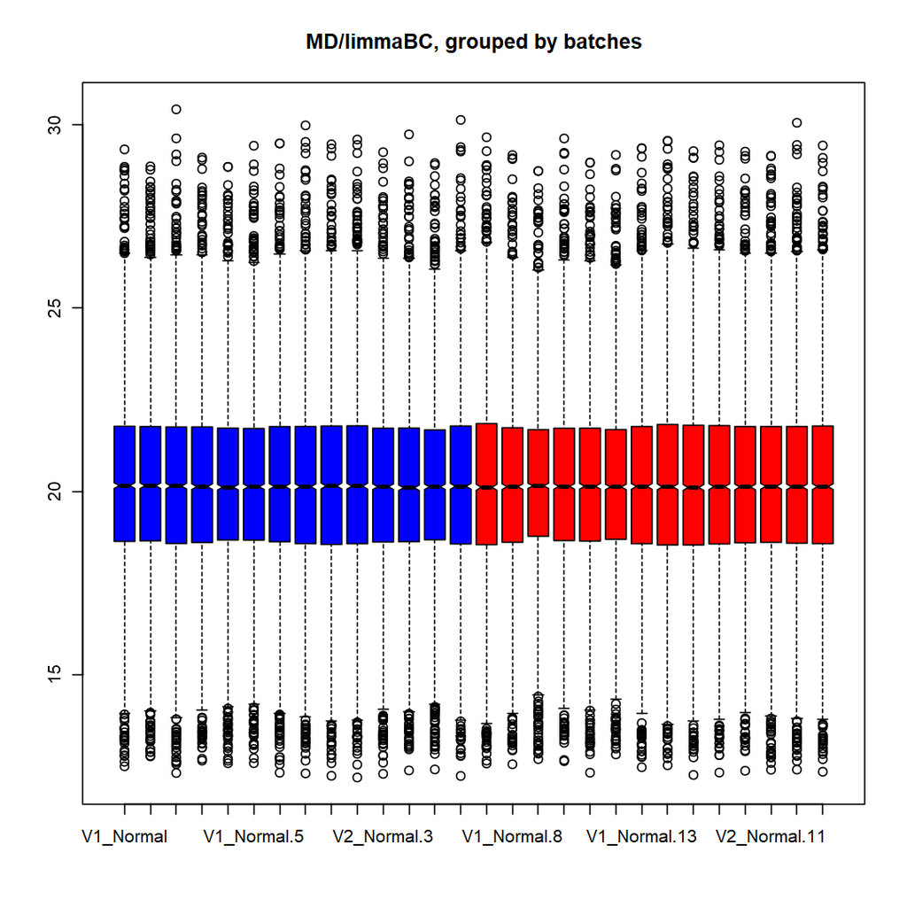

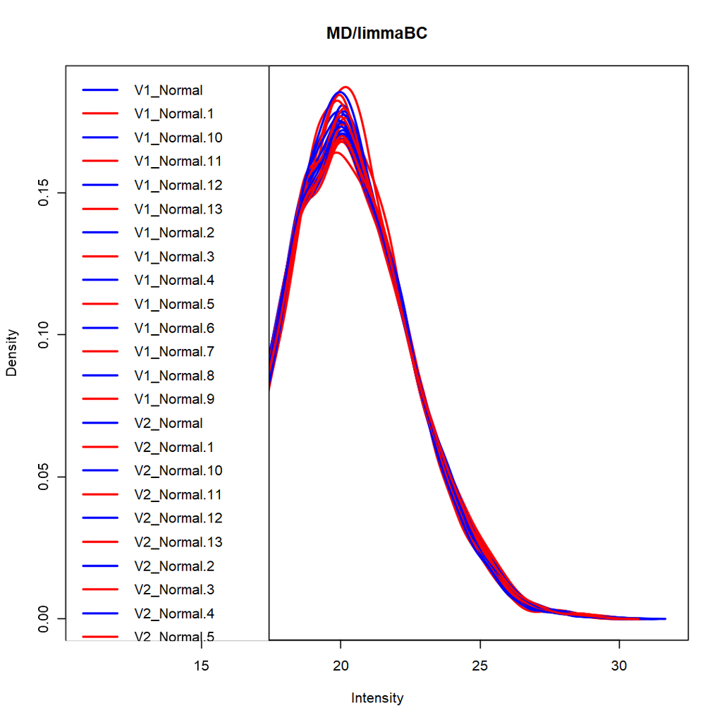

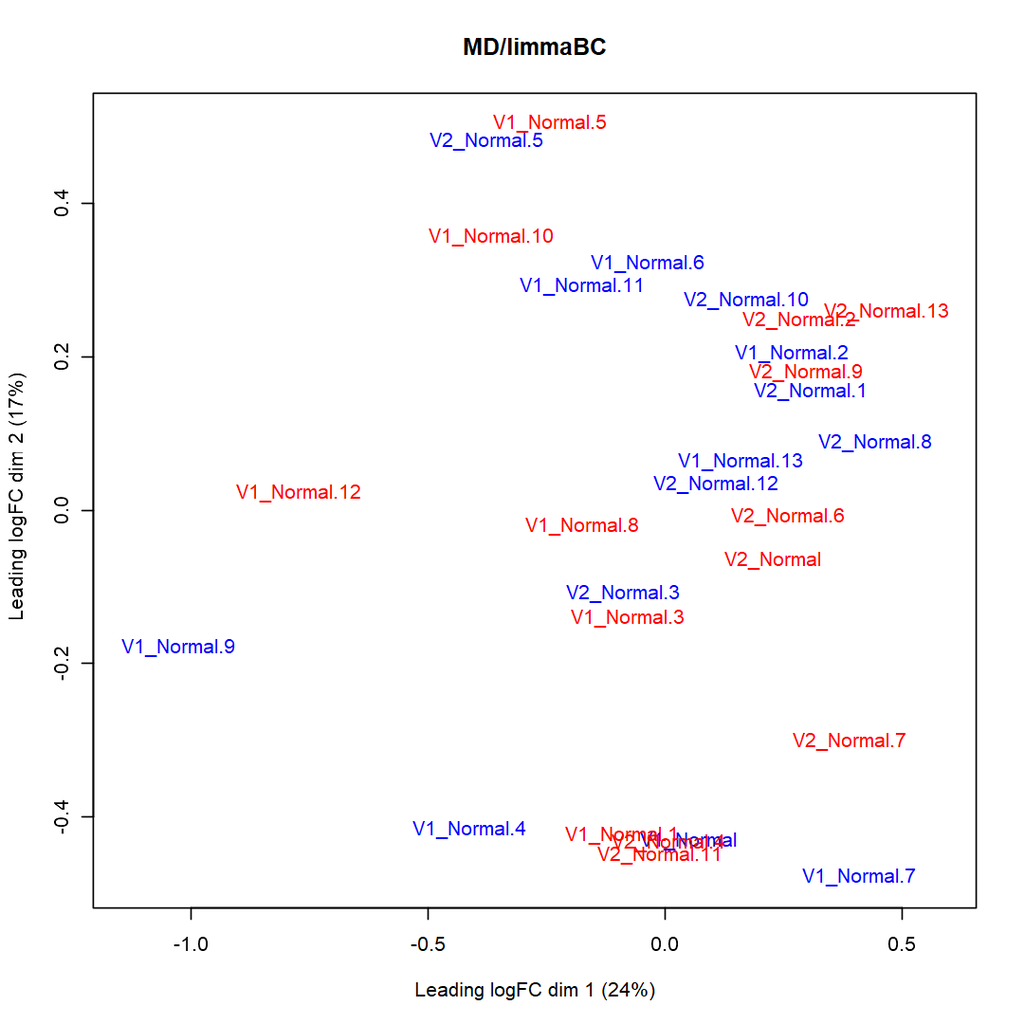

```r
# put groups together into a single data frame
colors = c(rep('blue', 14), rep('red', 14))

boxplot(log2(data_MD_limmaBC), col = colors, notch = TRUE, main = "MD/limmaBC, grouped by batches")

# can also look at density plots (like a distribution histogram)
plotDensities(log2(data_MD_limmaBC), col = rep(c("blue", "red"), 14), main = "MD/limmaBC")

plotMDS(log2(data_MD_limmaBC), col = rep(c("blue", "red"), 14), main = "MD/limmaBC")
```

```r
# define the groups
Normal_V1 <- select(data_MD_limmaBC, contains("V1_Normal"))
Normal_V2 <- select(data_MD_limmaBC, contains("V2_Normal"))
```

```r
group <- c(rep("Normal_V1", 14), rep("Normal_V2", 14))
```

```r
nrow(Normal_V1)
ncol(Normal_V1)
nrow(Normal_V2)
ncol(Normal_V2)
```

3994

14

3994

14

```r
# put groups together into a single data frame (we have added the bridge channels)
BC_abd <- bind_cols(Normal_V1, Normal_V2)

# define which columns go with each group
Normal_V1 <- 1:14
Normal_V2 <- 15:28

# set some colors by group
colors = c(rep('red', 14), rep('blue', 14))
```

```r
View(BC_abd)
```

A data.frame: 3994 × 28

|  | V1_Normal <dbl> | V1_Normal.1 <dbl> | V1_Normal.2 <dbl> | V1_Normal.3 <dbl> | V1_Normal.4 <dbl> | V1_Normal.5 <dbl> | V1_Normal.6 <dbl> | V1_Normal.7 <dbl> | V1_Normal.8 <dbl> | V1_Normal.9 <dbl> | ⋯ | V2_Normal.4 <dbl> | V2_Normal.5 <dbl> | V2_Normal.6 <dbl> | V2_Normal.7 <dbl> | V2_Normal.8 <dbl> | V2_Normal.9 <dbl> | V2_Normal.10 <dbl> | V2_Normal.11 <dbl> | V2_Normal.12 <dbl> | V2_Normal.13 <dbl> |
| --- | --- | --- | --- | --- | --- | --- | --- | --- | --- | --- | --- | --- | --- | --- | --- | --- | --- | --- | --- | --- | --- |
| A0A024RBG1 | 594267.24 | 525754.6 | 467050.60 | 567233.47 | 533965.0 | 560811.77 | 605035.72 | 742819.33 | 422788.48 | 410464.8 | ⋯ | 603388.9 | 474620.38 | 564802.25 | 666202.26 | 662134.53 | 706228.64 | 715677.45 | 665803.3 | 617351.5 | 704071.7 |
| A0A075B6H7 | 1185801.68 | 1464226.5 | 793212.75 | 1431525.30 | 1214056.3 | 602737.21 | 908061.93 | 1209283.93 | 884498.05 | 766057.5 | ⋯ | 1467674.8 | 678735.49 | 914072.66 | 846177.41 | 917978.36 | 805412.49 | 905164.98 | 898939.6 | 1703776.5 | 1080551.5 |
| A0A075B6H9 | 538812.34 | 399233.1 | 369342.82 | 415245.20 | 823911.9 | 400361.60 | 419904.44 | 484062.62 | 479869.41 | 474218.6 | ⋯ | 950245.7 | 374694.51 | 591668.80 | 445194.81 | 446689.28 | 452593.17 | 456968.86 | 293896.9 | 736890.7 | 521378.1 |
| A0A075B6I0 | 1966754.60 | 1728047.7 | 2216268.82 | 2090480.27 | 2736965.5 | 1267995.12 | 437381.83 | 1630480.71 | 1293068.75 | 738728.5 | ⋯ | 2724577.4 | 892435.33 | 403110.93 | 1165231.96 | 1165558.88 | 459678.01 | 1245655.15 | 2129594.5 | 2240492.4 | 2279050.0 |
| A0A075B6I1 | 298791.04 | 308356.8 | 143554.57 | 257403.09 | 297002.0 | 249925.76 | 234910.57 | 353238.59 | 401339.71 | 300598.1 | ⋯ | 452316.2 | 253533.19 | 216040.96 | 184477.45 | 309658.04 | 148710.95 | 219899.96 | 199805.9 | 342601.1 | 212876.7 |
| A0A075B6I9 | 544238.42 | 256168.0 | 428830.32 | 928955.01 | 446432.4 | 333681.77 | 494711.25 | 422722.20 | 465471.37 | 464123.6 | ⋯ | 627118.5 | 309476.91 | 502989.26 | 304769.53 | 481345.58 | 436108.68 | 487148.88 | 374718.0 | 504851.8 | 358510.1 |
| A0A075B6K2 | 75865.85 | 114766.8 | 63747.99 | 73809.16 | 164014.7 | 43970.45 | 61506.75 | 37326.69 | 70371.52 | 124141.7 | ⋯ | 147481.6 | 54484.91 | 98401.07 | 35191.47 | 66232.49 | 67852.73 | 70709.22 | 131243.5 | 139200.7 | 76285.2 |
| A0A075B6Q5 | 1450300.02 | 4669530.3 | 1290519.97 | 3048621.75 | 4702030.8 | 1466233.44 | 2023022.77 | 4737633.35 | 1978284.00 | 3135915.7 | ⋯ | 4419925.6 | 1773872.00 | 2800762.42 | 2178639.71 | 1454868.43 | 1604468.65 | 1737265.33 | 1809414.5 | 3247607.9 | 1801731.5 |
| A0A075B6R9 | 3187556.51 | 2196711.9 | 3110203.16 | 3152475.44 | 3820402.9 | 2576214.81 | 3434076.74 | 2045934.87 | 3948486.21 | 3606191.5 | ⋯ | 4675769.8 | 2704077.76 | 3775343.70 | 1906610.62 | 2722017.59 | 2825509.40 | 2596577.67 | 2258950.3 | 2870867.1 | 3311919.3 |
| A0A075B6S2 | 5278499.29 | 5410113.9 | 4536152.15 | 6107729.97 | 7453003.9 | 2214123.31 | 4174786.42 | 5370313.35 | 5266544.22 | 3276316.0 | ⋯ | 9977208.3 | 2837421.74 | 5533698.92 | 4033679.26 | 6237688.51 | 3816363.10 | 4194679.20 | 5095412.3 | 7747288.6 | 6332512.9 |
| A0A075B6S6 | 2822197.10 | 2368563.8 | 1434806.27 | 2459831.05 | 2728295.3 | 1620251.88 | 1655200.85 | 1353843.69 | 3306694.98 | 2897532.9 | ⋯ | 2215290.5 | 1661522.73 | 1878911.69 | 1083130.73 | 2400555.42 | 1537208.89 | 1610304.18 | 2642620.2 | 2201311.5 | 1925798.8 |
| A0A087WSY4 | 219056.01 | 365720.6 | 199776.00 | 302815.62 | 376497.5 | 246665.36 | 260794.76 | 259932.41 | 491968.39 | 578029.8 | ⋯ | 615873.7 | 297381.32 | 364609.60 | 217400.52 | 175372.54 | 396934.74 | 187986.53 | 284156.8 | 272722.2 | 159702.3 |
| A0A0A0MRZ8 | 21908203.49 | 30471962.5 | 13568431.69 | 21724006.13 | 26158677.3 | 10676013.28 | 14179506.14 | 36523629.17 | 22554693.57 | 7649252.5 | ⋯ | 43221370.4 | 11829281.15 | 21995311.85 | 19407794.58 | 19431430.67 | 18521030.94 | 17334790.08 | 18108451.3 | 29232717.4 | 21865911.0 |
| A0A0B4J1U7 | 2657560.49 | 1859791.4 | 1195022.94 | 1938928.91 | 2693119.0 | 1103618.60 | 1071324.92 | 1689998.75 | 2415075.13 | 1728168.5 | ⋯ | 3143387.0 | 1339274.82 | 1623684.47 | 1472807.78 | 2090948.81 | 1505397.17 | 1737350.17 | 1459618.0 | 1991036.7 | 1548681.1 |
| A0A0B4J2D5 | 7909191.31 | 7750488.8 | 9670589.80 | 7198669.83 | 3890812.1 | 5716761.33 | 8148571.75 | 9019645.18 | 7669338.09 | 3840478.1 | ⋯ | 5957809.1 | 5420358.64 | 10345731.00 | 9465551.86 | 8318503.27 | 10744408.16 | 8357481.82 | 7801862.5 | 7271022.3 | 7842562.0 |
| A0A0B4J2D9 | 4244088.53 | 9293936.3 | 2958364.44 | 3581591.18 | 7659516.5 | 2384837.28 | 3058850.40 | 3882971.64 | 4504371.66 | 2609654.3 | ⋯ | 7154417.1 | 3669009.04 | 3397325.38 | 2381231.91 | 2881954.21 | 3218060.57 | 4334001.85 | 3689521.8 | 8052757.6 | 3960858.7 |
| A0A0C4DH25 | 20721436.29 | 25959581.0 | 16541027.16 | 23354646.13 | 40940153.3 | 13488801.29 | 19025186.23 | 36661820.22 | 23623816.34 | 15686051.5 | ⋯ | 42393679.1 | 14569222.07 | 18981911.96 | 16922412.37 | 19911420.06 | 18136540.18 | 18182092.03 | 19688507.4 | 33456432.7 | 22791103.3 |
| A0A0C4DH29 | 6254151.82 | 14329124.4 | 5656930.79 | 6808494.16 | 24030242.3 | 4010332.54 | 8217163.66 | 7218004.49 | 8740070.46 | 7871599.0 | ⋯ | 16214369.7 | 5086237.29 | 8351751.99 | 3701803.97 | 5767498.41 | 4583682.45 | 7562159.51 | 9676488.4 | 11539246.6 | 7181969.4 |
| A0A0C4DH34 | 626963.10 | 729794.3 | 620432.57 | 829426.84 | 1056357.9 | 706926.30 | 771169.57 | 626747.94 | 706411.96 | 1531328.5 | ⋯ | 1244064.3 | 734200.67 | 977724.82 | 640587.08 | 600988.51 | 809940.47 | 726862.34 | 724718.7 | 1142761.9 | 830925.3 |
| A0A0C4DH38 | 337282.14 | 543642.4 | 254784.45 | 290902.01 | 579696.3 | 356483.58 | 301987.26 | 395290.99 | 369709.79 | 354674.9 | ⋯ | 540587.3 | 378133.61 | 385920.51 | 267029.20 | 253155.59 | 221759.39 | 297395.79 | 374487.4 | 758213.7 | 372058.6 |
| A0A0C4DH41 | 2682328.87 | 2862683.7 | 2781206.64 | 2540498.76 | 3262394.1 | 2759669.16 | 3191872.96 | 3655794.16 | 2645681.84 | 3320749.9 | ⋯ | 3323293.8 | 2793458.08 | 2533596.57 | 2360319.50 | 2362420.29 | 2346771.31 | 2191183.70 | 2310724.7 | 4464085.5 | 2721762.1 |
| A0A0J9YXX1 | 2902660.24 | 555453.7 | 1374877.85 | 1599819.11 | 4797830.5 | 1978286.31 | 1402716.76 | 6475542.13 | 1708030.54 | 886423.8 | ⋯ | 4909461.3 | 2868186.13 | 2619354.73 | 3525679.71 | 1407571.86 | 1137427.26 | 694899.45 | 862815.6 | 8060679.0 | 2662368.1 |
| A0AV96 | 1609638.27 | 1594699.5 | 1945634.84 | 1984600.72 | 1837050.1 | 2192533.92 | 2019031.40 | 1400373.54 | 2173841.89 | 2012359.9 | ⋯ | 1462569.8 | 2428948.57 | 1743857.81 | 1367943.83 | 2020294.75 | 2168477.13 | 1853279.29 | 1761107.4 | 1897210.8 | 1925636.2 |
| A0AVT1 | 1210366.89 | 1083626.3 | 1430608.24 | 1220310.10 | 1363948.3 | 1208637.32 | 1271903.35 | 1268571.41 | 1282570.69 | 1152673.2 | ⋯ | 1154041.8 | 1141168.59 | 1160718.63 | 1205737.68 | 1211391.33 | 1202623.60 | 1137354.65 | 1196781.1 | 1292934.8 | 1210655.8 |
| A0FGR8 | 1005363.10 | 1123689.8 | 1156672.85 | 1230458.77 | 1321462.4 | 1323902.27 | 1191066.47 | 999878.49 | 1142350.26 | 1363132.8 | ⋯ | 1137434.3 | 1285800.60 | 881271.11 | 1003456.89 | 1245443.27 | 1051802.18 | 1098727.07 | 1284641.4 | 1283937.6 | 1262114.3 |
| A0M8Q6 | 137376.27 | 218122.4 | 604399.16 | 880155.53 | 1815913.9 | 246790.47 | 1110814.54 | 1314241.42 | 267684.18 | 250924.9 | ⋯ | 1888273.3 | 285564.80 | 1135858.10 | 646224.43 | 257411.57 | 661151.77 | 467560.38 | 1561988.8 | 369408.5 | 555492.5 |
| A0MZ66 | 991237.93 | 1094416.2 | 898477.23 | 945668.39 | 821455.1 | 1112229.22 | 982452.26 | 926138.40 | 1077343.20 | 1083220.4 | ⋯ | 807646.3 | 1162556.82 | 969779.54 | 995353.51 | 1004222.14 | 997527.87 | 1029681.73 | 890250.1 | 873346.5 | 866159.5 |
| A1A5D9 | 214733.50 | 240868.1 | 233604.07 | 239478.78 | 215563.5 | 273456.88 | 266023.23 | 287240.23 | 255694.02 | 317476.4 | ⋯ | 258407.3 | 289085.25 | 236726.07 | 234520.47 | 215362.57 | 279135.41 | 291860.32 | 159794.3 | 228504.1 | 193346.9 |
| A1L0T0 | 956641.92 | 1221594.6 | 2191036.61 | 1547156.33 | 916258.0 | 1694054.42 | 1591138.25 | 679594.84 | 1204458.23 | 1209440.6 | ⋯ | 936149.7 | 1555504.60 | 627620.10 | 1144911.45 | 1797084.48 | 1761097.16 | 1601255.68 | 1023756.5 | 1246644.0 | 2078711.4 |
| A1X283 | 441226.02 | 523658.8 | 414023.08 | 412028.49 | 848343.1 | 1130185.36 | 695886.36 | 560160.40 | 474568.68 | 1019072.0 | ⋯ | 556180.8 | 1019203.04 | 421963.56 | 517512.05 | 415402.78 | 410786.70 | 442911.89 | 703471.8 | 442712.7 | 419082.8 |
| ⋮ | ⋮ | ⋮ | ⋮ | ⋮ | ⋮ | ⋮ | ⋮ | ⋮ | ⋮ | ⋮ | ⋱ | ⋮ | ⋮ | ⋮ | ⋮ | ⋮ | ⋮ | ⋮ | ⋮ | ⋮ | ⋮ |
| Q9Y680 | 289059.35 | 314430.73 | 232797.77 | 243843.571 | 340221.925 | 333838.343 | 272675.301 | 276531.829 | 234975.359 | 384301.332 | ⋯ | 281992.63 | 283857.351 | 214132.29 | 380626.12 | 225400.95 | 270301.25 | 289331.329 | 286631.043 | 213430.15 | 201261.70 |
| Q9Y696 | 1283532.37 | 1546055.05 | 1105133.20 | 1267883.800 | 1482894.314 | 1378357.832 | 1355900.385 | 1303374.786 | 1302579.106 | 1463465.272 | ⋯ | 1625154.58 | 1433963.966 | 1206839.83 | 1524210.89 | 1154037.03 | 1118331.79 | 1300185.726 | 1460716.639 | 1241858.09 | 1060807.01 |
| Q9Y6A4 | 11708.96 | 13352.40 | 11673.67 | 11919.388 | 11393.163 | 10939.777 | 10569.593 | 10751.857 | 14357.490 | 14806.436 | ⋯ | 15038.29 | 10079.264 | 11679.64 | 11097.08 | 10322.26 | 11413.80 | 12893.310 | 10625.753 | 12043.70 | 10396.96 |
| Q9Y6B6 | 1846959.37 | 1669291.20 | 1917090.71 | 1813071.928 | 1622110.309 | 1685318.145 | 1781078.632 | 1696457.033 | 1584914.177 | 1203509.050 | ⋯ | 1355845.73 | 1272544.062 | 1443658.92 | 1471734.92 | 1614777.77 | 1765446.90 | 1667662.423 | 1501179.975 | 1607426.63 | 1677049.11 |
| Q9Y6C2 | 5343410.63 | 4582981.53 | 6462702.72 | 5560936.991 | 8339981.022 | 8411833.246 | 7985848.599 | 6241874.674 | 6031979.062 | 6056875.222 | ⋯ | 8030431.89 | 8200534.642 | 6843006.37 | 5565022.12 | 7277988.55 | 7727397.49 | 5678766.416 | 6130027.010 | 6920645.66 | 8039850.14 |
| Q9Y6C9 | 92692.72 | 81138.15 | 169558.32 | 117730.465 | 153020.295 | 135750.439 | 119899.422 | 88584.748 | 114405.639 | 159935.997 | ⋯ | 114914.54 | 156516.320 | 115891.27 | 90147.83 | 108504.77 | 111825.90 | 120616.226 | 97270.444 | 123742.75 | 113832.19 |
| Q9Y6D5 | 2398100.88 | 2035177.66 | 2790386.70 | 2795744.714 | 3275956.547 | 2865451.963 | 2788302.683 | 2095001.346 | 2814621.390 | 2445233.183 | ⋯ | 2940451.08 | 3010756.455 | 2502233.31 | 2434684.02 | 3001327.44 | 2915465.74 | 2779897.522 | 2617391.132 | 3093164.82 | 3895193.18 |
| Q9Y6D6 | 464279.29 | 465300.33 | 510711.96 | 478830.508 | 513683.340 | 656340.444 | 565398.939 | 497949.924 | 436500.415 | 537236.928 | ⋯ | 527254.24 | 680516.525 | 521602.84 | 488664.35 | 586553.54 | 442251.43 | 497285.748 | 389423.054 | 1088304.54 | 776691.22 |
| Q9Y6E0 | 1817464.60 | 2026663.81 | 2182705.46 | 2046970.202 | 1755198.430 | 2255711.732 | 2362819.299 | 2010009.710 | 2030083.419 | 2096588.807 | ⋯ | 1664239.52 | 2156586.063 | 2006693.52 | 1883234.86 | 1844149.35 | 2183553.27 | 2204979.466 | 1742199.492 | 1848575.45 | 2104390.48 |
| Q9Y6E2 | 1659468.36 | 1728193.91 | 1691788.59 | 1713716.318 | 1886879.694 | 2060407.720 | 1827461.232 | 1834022.783 | 1794669.977 | 1675883.207 | ⋯ | 1570597.98 | 2002536.975 | 1887135.31 | 1729070.20 | 2091438.36 | 1719087.05 | 1762983.901 | 1603128.978 | 1815052.99 | 2068511.02 |
| Q9Y6F6 | 135947.68 | 171793.42 | 123414.23 | 126501.739 | 136019.790 | 145826.766 | 116569.375 | 117138.019 | 159742.746 | 184882.736 | ⋯ | 179205.09 | 202192.689 | 155887.56 | 131787.80 | 116577.28 | 128062.25 | 139822.250 | 153275.135 | 169922.43 | 99838.34 |
| Q9Y6G3 | 155647.52 | 151390.52 | 101268.22 | 107636.074 | 93995.104 | 120352.976 | 126008.137 | 114006.758 | 97293.678 | 182268.585 | ⋯ | 86626.60 | 103633.526 | 121271.46 | 109454.40 | 88454.68 | 91857.62 | 135162.766 | 95795.508 | 84700.10 | 91787.66 |
| Q9Y6G9 | 2192298.51 | 2026306.45 | 2676533.93 | 2173756.152 | 2023389.398 | 1798337.798 | 2109566.170 | 2140952.667 | 2131625.624 | 2184022.699 | ⋯ | 2226669.06 | 1750448.408 | 2169071.70 | 2255266.03 | 2106236.18 | 1894793.23 | 1856940.219 | 2538424.693 | 1863661.70 | 1784303.74 |
| Q9Y6H1 | 525129.67 | 573760.22 | 544295.90 | 505581.469 | 512361.419 | 638760.767 | 654918.628 | 443988.059 | 678504.755 | 1279386.868 | ⋯ | 465759.95 | 593304.718 | 622841.22 | 471348.55 | 442801.07 | 485493.80 | 527723.923 | 539001.723 | 373264.53 | 377085.22 |
| Q9Y6I3 | 627799.93 | 736456.61 | 554059.02 | 602887.725 | 461378.330 | 689783.451 | 632447.338 | 746803.384 | 658310.553 | 469227.379 | ⋯ | 638859.47 | 634985.200 | 652488.78 | 611774.74 | 548199.99 | 633375.12 | 644309.178 | 702176.608 | 579715.72 | 616212.00 |
| Q9Y6I9 | 141136.30 | 150514.96 | 131101.90 | 137808.554 | 199383.665 | 196104.601 | 184944.375 | 143279.808 | 143307.552 | 162917.527 | ⋯ | 117942.35 | 208746.652 | 127036.96 | 162735.56 | 127791.66 | 138018.19 | 138830.933 | 174977.463 | 150788.13 | 118502.90 |
| Q9Y6K5 | 157145.28 | 106058.08 | 193115.34 | 156119.735 | 188418.524 | 75862.504 | 127642.542 | 119376.871 | 136560.019 | 187143.856 | ⋯ | 185785.48 | 89676.527 | 167124.92 | 126737.03 | 189667.34 | 147886.52 | 131203.785 | 145247.781 | 139848.30 | 145339.30 |
| Q9Y6K9 | 1053195.51 | 1063641.50 | 770392.49 | 1005696.227 | 1034707.313 | 1072235.139 | 994571.324 | 1104918.157 | 913006.041 | 1352637.335 | ⋯ | 1000086.29 | 1123806.158 | 861154.67 | 1059739.24 | 744129.00 | 755992.16 | 896491.774 | 1033647.061 | 827911.17 | 829013.72 |
| Q9Y6M1 | 591643.18 | 659942.30 | 728257.55 | 699770.427 | 654235.333 | 730464.892 | 869351.195 | 643941.717 | 722101.448 | 687377.627 | ⋯ | 741843.74 | 760797.537 | 672895.80 | 659932.48 | 774026.84 | 839325.91 | 724538.667 | 728658.667 | 845920.09 | 792668.13 |
| Q9Y6M9 | 809511.49 | 744993.12 | 1104308.09 | 828484.023 | 582127.215 | 850418.921 | 954936.952 | 837505.959 | 865907.516 | 670377.884 | ⋯ | 566633.56 | 1032312.553 | 1068684.97 | 880866.03 | 825606.38 | 893794.29 | 1120108.961 | 793818.583 | 808956.35 | 935628.70 |
| Q9Y6N5 | 4644557.81 | 5251534.21 | 7737488.99 | 6414157.860 | 7028189.157 | 5601518.128 | 5387571.126 | 4365533.646 | 5192468.038 | 5454350.345 | ⋯ | 5817804.31 | 6019785.999 | 5738686.73 | 5292631.98 | 5661943.84 | 8149568.31 | 7047283.785 | 4564374.194 | 7594821.46 | 7595740.67 |
| Q9Y6N9 | 1291993.98 | 1265281.79 | 1699707.14 | 1351020.046 | 1482598.535 | 1696238.225 | 1547828.309 | 810222.178 | 1519923.909 | 2036595.731 | ⋯ | 1292929.00 | 2009860.291 | 1503496.50 | 919973.30 | 1596748.64 | 1599102.50 | 1499113.900 | 1071260.059 | 1473688.88 | 1803331.10 |
| Q9Y6Q5 | 987903.55 | 763540.80 | 1228491.49 | 817042.234 | 1525941.739 | 985098.656 | 913903.233 | 775790.148 | 950591.252 | 908437.018 | ⋯ | 1063815.42 | 1070731.196 | 938280.59 | 842928.88 | 1087329.86 | 1253172.08 | 1014411.194 | 914794.312 | 1184494.85 | 1334511.77 |
| Q9Y6R1 | 766973.98 | 660774.12 | 1328534.38 | 1223491.205 | 820109.793 | 1243019.545 | 1047806.655 | 840750.217 | 997315.440 | 792527.604 | ⋯ | 679084.28 | 1293111.332 | 842848.65 | 687068.34 | 1110298.75 | 1153566.12 | 1018288.344 | 703634.107 | 1089905.12 | 1339436.43 |
| Q9Y6R7 | 44783735.02 | 41613104.00 | 46726586.42 | 41511836.990 | 24373116.350 | 54859073.070 | 49734714.180 | 33662715.860 | 36399427.150 | 24523002.640 | ⋯ | 40210451.51 | 59637364.190 | 50591275.26 | 39391908.50 | 45396000.74 | 55210598.70 | 66215262.580 | 39789235.390 | 62131178.34 | 65637231.35 |
| Q9Y6U3 | 578854.73 | 602215.86 | 894135.75 | 915872.019 | 548690.340 | 1136983.124 | 976014.733 | 497125.764 | 773163.872 | 776651.263 | ⋯ | 516442.87 | 1254752.587 | 742935.82 | 612353.32 | 843863.50 | 998562.62 | 901744.504 | 617911.377 | 974985.91 | 861293.78 |
| Q9Y6W3 | 188395.91 | 181630.20 | 197354.36 | 182981.116 | 185997.702 | 211328.503 | 190850.586 | 158772.315 | 199565.616 | 237433.089 | ⋯ | 221522.74 | 224549.901 | 173281.49 | 165748.32 | 194650.76 | 174644.36 | 209334.871 | 185589.852 | 192638.44 | 193780.78 |
| Q9Y6W5 | 2390596.13 | 2230097.29 | 1873635.02 | 2263995.312 | 1789586.912 | 1936429.343 | 2098097.556 | 2400792.223 | 1807188.081 | 1984005.576 | ⋯ | 2284901.46 | 2033270.022 | 2043458.79 | 2404865.34 | 2002791.80 | 1869941.53 | 2328524.579 | 2218530.797 | 1927649.22 | 1886014.71 |
| Q9Y6X5 | 10080.78 | 10207.94 | 15926.57 | 8208.173 | 6417.748 | 8912.751 | 8304.695 | 8451.224 | 7787.374 | 9008.342 | ⋯ | 12629.33 | 5436.733 | 15800.50 | 12764.89 | 10948.96 | 11253.18 | 9087.206 | 6812.537 | 14515.99 | 12082.00 |
| Q9Y6Y8 | 808825.77 | 819818.59 | 900007.72 | 863926.313 | 1040051.401 | 846900.309 | 930626.898 | 902509.736 | 871291.613 | 717094.705 | ⋯ | 933340.50 | 841561.984 | 963367.18 | 973025.93 | 1110572.56 | 1211054.53 | 721925.196 | 774439.901 | 1089839.60 | 1025806.63 |

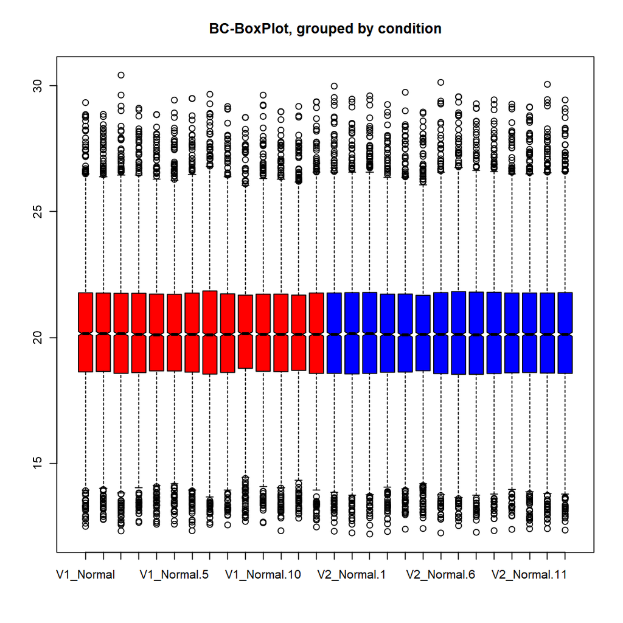

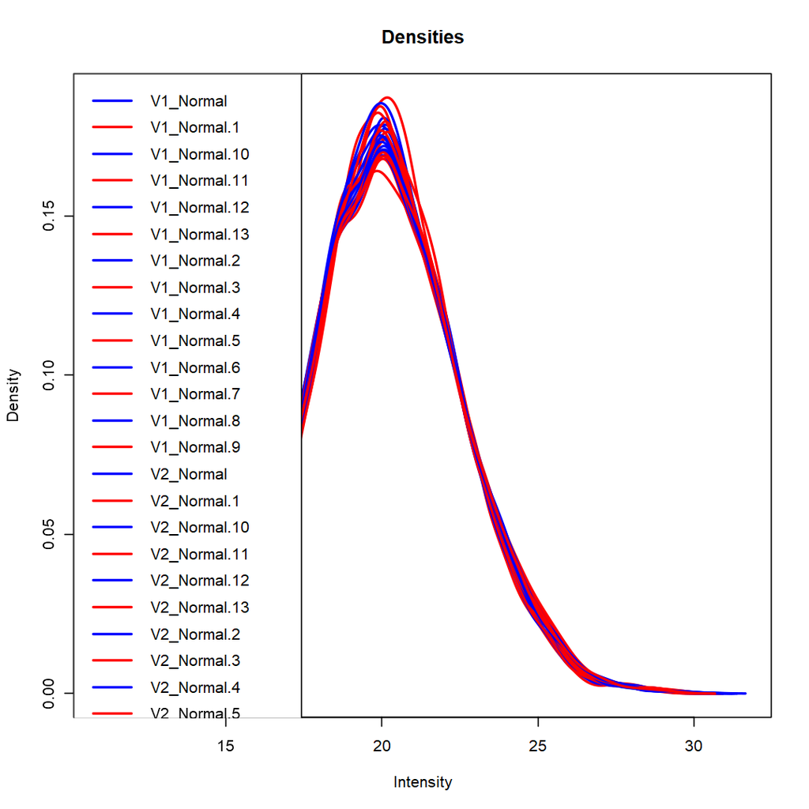

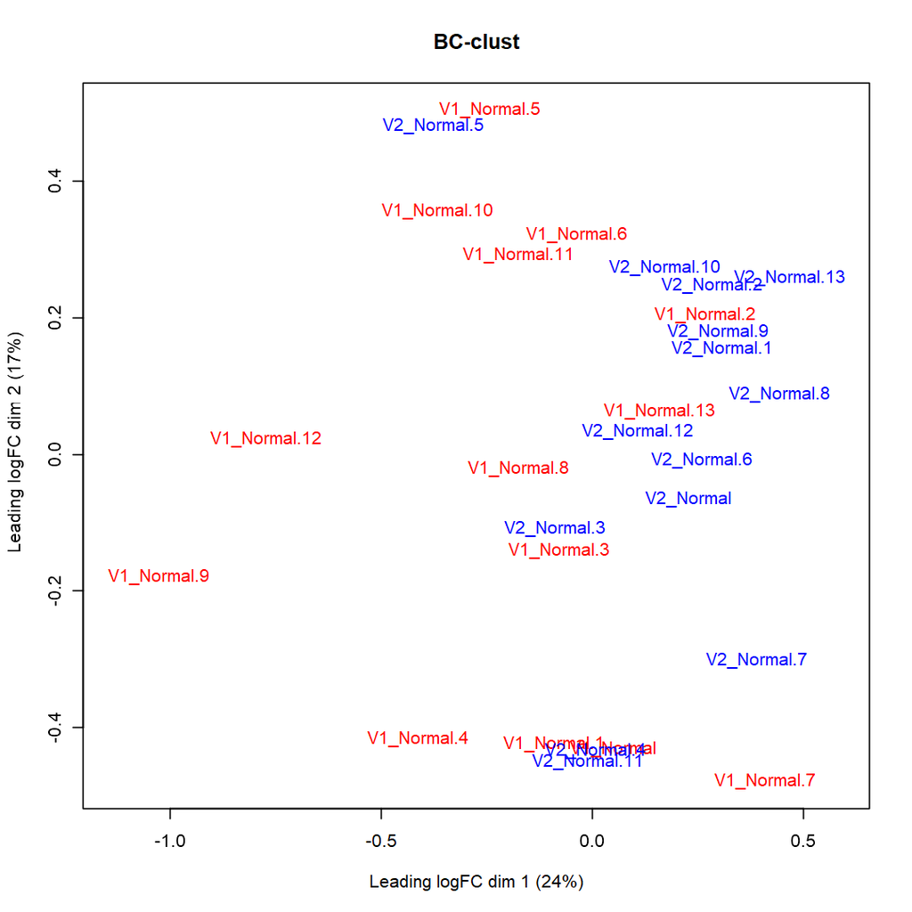

```r
boxplot(log2(BC_abd), col = colors, notch = TRUE, main = "BC-BoxPlot, grouped by condition")
plotDensities(log2(BC_abd), col = rep(c("blue", "red"), 14), main = "Densities")
plotMDS(log2(BC_abd), main = "BC-clust", col = colors)
```

```r
cv_BC <- data.frame(Normal_V1 = CV(BC_abd[Normal_V1]), Normal_V2 = CV(BC_abd[Normal_V2]))

medians <- apply(cv_BC, 2, FUN = median)
print("BC median CVs by condition (%)")
round(medians, 2)
```

```
[1] "BC median CVs by condition (%)"
```

**Normal_V1**

18.58

**Normal_V2**

15.73

```r
# see what the CV distibutions look like
# need long form for ggplot
cv <- gather(cv_BC, key = "group", value = "cv")

set_plot_dimensions(9, 9)
```

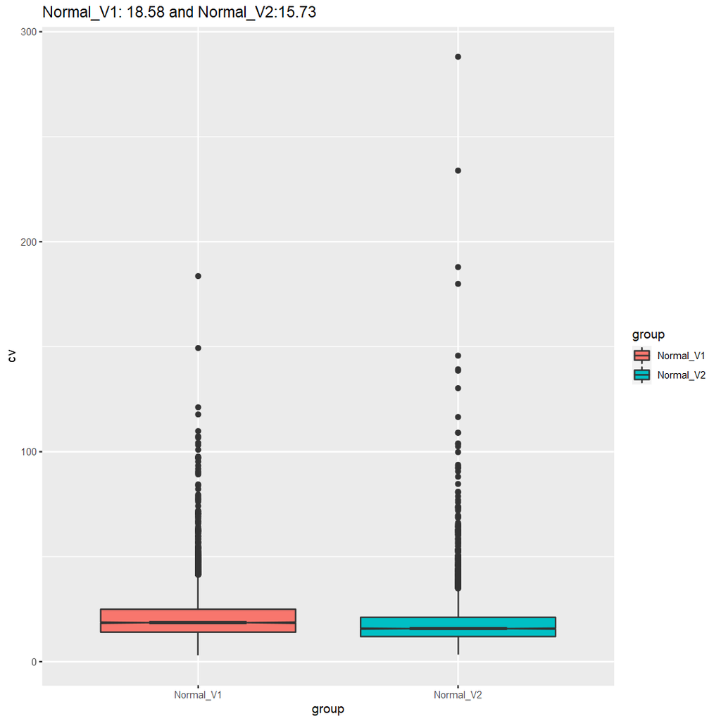

```r
# traditional boxplots
ggplot(cv, aes(x = group, y = cv, fill = group)) +
  geom_boxplot(notch = TRUE) +
  ggtitle("Normal_V1: 18.58 and Normal_V2:15.73")
```